# ThrustOne Theory Manual

# ThrustOne Theory Manual

## Purpose and scope

This book explains the physical models behind ThrustOne: the balances they solve, the assumptions that close those balances, and the meaning of their outputs. It is intended for a reader who wants to understand a calculation rather than obtain a number without its context. Familiarity with elementary thermodynamics, mechanics and calculus is helpful; the opening chapters establish the conventions needed to connect those subjects to propulsion calculations.

The first edition addresses 49 explicitly bounded calculation modes across nine engine families. Some modes describe complete idealized cycles. Others describe a component, a geometry construction, a chemical state or a segment of a flowpath. A family name does not imply that all of its physical processes are implemented. In particular, a combined-cycle submodel is not a vehicle-level transition analysis, and a nozzle reference contour is not a solved wall-pressure field.

The user guide explains where to enter values, choose a branch and export a result. This theory manual explains why those inputs are needed and what can be concluded from the result. The two documents serve different purposes. Field inventories and operating instructions do not replace the derivations here; theoretical background does not create an additional software capability.

## How the book is organized

Chapters 1–4 establish control boundaries, static and total states, normalization and freestream conditions. These conventions recur throughout the book. Chapters 5–8 explain mixture properties, equilibrium and finite-rate chemistry. They distinguish a frozen composition from constant heat capacity, and an equilibrium state from a time-dependent chemical process.

Chapters 9–15 develop turbojet and turbofan cycles, components, mixing and reference-based off-design calculations. Chapters 16–22 cover rocket performance, chemical expansion, reference geometry, parameter studies and established-burning solid-motor models. Chapters 23–29 connect shocks and duct balances to ramjet and scramjet flowpaths, including variable properties and finite-rate species transport.

Chapters 30–32 explain the bounded combined-cycle submodels. Their differing connections matter: explicit independent branch allocation, momentum-based entrainment and turbine-to-fan shaft transfer are distinct closures. Chapters 33–34 explain numerical results and defensible parameter comparisons. The appendices provide notation, normalization, domain summaries and a mode-to-chapter directory.

## Reading paths

For a first propulsion course, begin with Chapters 1–4, then select the relevant engine family. Read Chapter 33 before interpreting a failed solve or a state close to a sonic boundary. A reader who understands mass and energy conservation but is new to propulsion will usually benefit most from following one complete station chain before exploring many model options.

For turbine cycles, follow Chapters 9–10 and 13–14 before studying component maps and off-design closure in Chapters 11–12 and 15. A design-point pressure ratio and a pressure ratio solved from a reference engine are not interchangeable inputs. Mixed-flow calculations also require a more careful mass-flow basis than a single-stream cycle.

For rocket calculations, read Chapters 16–17 before sizing in Chapter 18 or contour construction in Chapter 19. Thermochemical state, performance scale and reference geometry answer different questions. Read Chapter 20 when comparing altitude, pressure, expansion ratio or mixture-ratio results. Solid-propellant readers should then use Chapters 21–22, which explicitly exclude ignition and tail-off modeling.

For reacting flows, read Chapters 5–8, then the reconstruction in Chapter 26 and the flowpath formulation in Chapter 29. This order is important: a species enthalpy reference affects energy closure, and a chemically changing mixture cannot be interpreted using one fixed gas constant. Chapters 23–24 supply the shock, friction, heat and mass-source background.

For combined cycles, use Chapters 30–32 together with the underlying turbine, ramjet and mixing chapters. Compare the control diagrams before comparing performance. An identical word such as “bypass” can denote a prescribed allocation in one model and a mass ratio determined by a balance in another.

## Four questions to carry into every calculation

The first question is what crosses the control boundary. Captured air, onboard primary material, fuel, oxidizer, heat and shaft work enter different balances. A rocket and an airbreathing engine do not have the same inlet momentum debit.

The second is which state is specified. Static pressure acts on a surface; total pressure describes an isentropic reference state. Chamber static temperature and stagnation temperature coincide only under an appropriate velocity approximation. An apparently small label difference can change the calculation.

The third is what closes the problem. A prescribed exit pressure, a fixed area, a selected Mach branch, an energy constraint and a fitted inlet relation are different closures. One must not silently substitute one for another while comparing results.

The fourth is what the output is divided by. Specific thrust may use core air, total captured air or another stream. Specific impulse may use all injected mass rather than fuel alone. A ratio without its denominator is an incomplete physical statement.

## Common conventions

Equations use SI units unless a local example explicitly identifies another unit. Temperatures in thermodynamic relations are absolute. Pressures are absolute unless stated otherwise; a gauge pressure is not a valid direct replacement in a pressure ratio. Internal energy and enthalpy may be negative under a formation-inclusive reference convention. Their signs alone do not determine physical admissibility.

A subscript t usually denotes a total state, a subscript 0 a freestream reference, and a superscript star a critical or sonic reference defined locally. Neither station numbering nor star notation is globally interchangeable across every model. The chapter’s definition controls its meaning.

The positive flow direction is downstream through the engine. Thrust is normally reported as the useful reaction-force magnitude opposite that flow direction. When a model permits negative net force, the sign indicates an unfavorable result under its accounting. Other modes explicitly reject nonpositive performance; the applicable chapter states the distinction.

Common symbols are listed in Appendix A. Some established symbols have more than one use: F may be thrust or a momentum function; s may be entropy or specific thrust; beta may denote a shock angle or a flow ratio. Local definitions and units resolve those collisions. The notation reference is a guide to reading, not permission to substitute symbols across equations without checking their definitions.

## Worked examples and evidence

Examples use original inputs and explanations. A simple accounting example may isolate mass flow, energy or force without constructing a complete engine. Such an example is labeled accordingly. It demonstrates the balance being discussed and must not be mistaken for an independently confirmed App operating point.

Where a numerical value has a documented local reference, the internal editorial record preserves its actual location and qualifications. Independent source evidence, direct illustrative arithmetic and application-generated workflow results have different roles. The book does not turn a value calculated by the application into proof of that same application’s correctness.

Derivations use mathematical relations and original exposition. Diagrams establish control boundaries, station conventions or geometric constructions. They are not reproductions of source illustrations and do not imply that the application solves every feature shown as background context.

## Model hierarchy and limits

An ideal constant-property calculation can reveal a useful relation with very few inputs. A variable-property calculation changes how the state is recovered. An equilibrium calculation changes the composition constraint. A finite-rate calculation adds chemical evolution. None of these changes automatically adds spatial transport, wall cooling, shocks, multiphase physics or a complete hardware design.

Greater mathematical detail is useful when it answers the intended question and its extra inputs are meaningful. It is not a universal ordering from an inferior model to a superior one. A complicated mechanism with unsuitable coefficients can provide a less defensible conclusion than a simple model used within its stated scope.

An interrupted flow history is presented as a valid prefix, not a completed nozzle or engine. A sampled maximum is identified as a sampled result, not a continuous optimum. A geometrically plausible contour is distinguished from an optimized flow solution. These distinctions are part of the result, rather than qualifications to remove when presenting a favorable number.

The equations in this book support interpretation of the current calculation modes. They do not constitute component qualification, operating approval, structural certification or a guarantee of a real engine’s performance. The productive use of the models is to formulate a clear question, preserve its assumptions and report the answer with the same boundaries.

# 1. Control volumes and engine performance

## 1.1 Begin with the physical boundary

An engine performance calculation begins by choosing a boundary, not by choosing a thrust equation. The boundary identifies which mass streams enter and leave, where pressures act, and which mechanical or thermal interactions are included. Two calculations may use individually correct equations and still disagree because they describe different boundaries.

For an airbreathing engine, a useful stationary control volume in the engine frame begins upstream of the inlet and ends at the exhaust plane. Captured air enters at the flight speed relative to the engine. Fuel enters through a separate supply. A turbofan has either separate core and bypass exit planes or one common mixed-flow exit. A rocket has no captured atmospheric-air stream: its propellant enters from onboard supplies. A standalone nozzle has an upstream state supplied by the user and does not, by itself, define the thrust of an entire vehicle.

Draw these boundaries before reducing the equations. Mark each inlet and exit area, the outward surface normal, static pressure, mass flow and axial velocity. Static pressure belongs in the surface-force balance. Total pressure is a useful state variable for losses and expansion, but it is not the pressure exerted on a plane in the momentum equation.

Throughout this chapter, the positive exhaust direction is downstream relative to the engine. We report the positive magnitude of the useful reaction force on the engine in the opposite direction. A signed force-vector formulation is equally valid, provided every normal and velocity uses the same convention.

## 1.2 Mass conservation and the choice of reference flow

The integral mass balance is

$$\frac{d}{dt}\int_{CV}\rho\,dV
+\int_{CS}\rho\mathbf{V}\cdot\mathbf{n}\,dA=0.$$

For steady, one-dimensional streams this reduces to

$$\sum_{\mathrm{out}}\dot m_j=\sum_{\mathrm{in}}\dot m_i.$$

For a simple turbojet without bleed or auxiliary discharge,

$$\dot m_e=\dot m_a+\dot m_f=(1+f)\dot m_a,
\qquad f=\frac{\dot m_f}{\dot m_a}.$$

The factor $1+f$ is a mass balance, not an efficiency correction. Neglecting it is an explicit ideal-cycle approximation. It must not disappear merely because fuel flow is small. Its effect also depends on exhaust speed, so a percentage error in mass flow need not produce the same percentage error in net thrust after inlet momentum is subtracted.

For a separate-flow turbofan, define core air flow $\dot m_c$, bypass air flow $\dot m_b$, and bypass ratio $\alpha=\dot m_b/\dot m_c$. Total captured air is

$$\dot m_a=(1+\alpha)\dot m_c.$$

Fuel-air ratio normally refers to core air, $f=\dot m_f/\dot m_c$. Therefore fuel per total captured air is $f/(1+\alpha)$. A comparison that divides total-air-based specific thrust into core-air-based fuel ratio overstates fuel consumption by a factor of $1+\alpha$.

For a rocket, total propellant flow includes oxidizer and fuel. With mixture ratio $MR=\dot m_{ox}/\dot m_f$, the fuel flow is $\dot m_p/(1+MR)$. Rocket specific impulse uses total propellant consumption, not fuel consumption alone. This distinction becomes especially important when comparing a rocket with an airbreathing engine whose oxidizer comes from the atmosphere.

## 1.3 Momentum flux is not thrust

The axial momentum balance for a steady control volume equates net external force on the fluid to the change in axial momentum flux. For uniform streams, each momentum-flux contribution is $\dot mV$. Pressure forces also act on each control surface. To compare an exhaust plane with its surrounding atmosphere, the relevant excess-pressure contribution is $(p_e-p_a)A_e$.

For one captured air stream and one exhaust, with negligible axial momentum supplied through the fuel line and with installation drag excluded, the customary uninstalled net thrust is

$$F_N=\dot m_eV_e-\dot m_aV_0+(p_e-p_a)A_e.$$

The assumptions matter. If an injected stream has appreciable axial momentum at the chosen boundary, its inlet momentum belongs in the balance. If an engine model includes multiple exits, the exhaust terms must be summed. If a propulsion installation includes spillage, external nacelle forces or other drag, an uninstalled cycle calculation does not automatically account for them.

Gross thrust is the exhaust contribution,

$$F_G=\dot m_eV_e+(p_e-p_a)A_e,$$

and inlet momentum drag for the simple captured-air boundary is $\dot m_aV_0$. Thus $F_N=F_G-\dot m_aV_0$. Calling gross thrust “net thrust” silently removes the cost of accelerating captured air from its incoming momentum state.

A different quantity appears in one-dimensional duct and mixer calculations:

$$J=pA+\dot mV.$$

This is a stream momentum function. It combines absolute-pressure force and momentum flux at one station. It is useful for connecting stations across a selected duct model. It is not, in general, an engine thrust. In particular,

$$F_G=J_e-p_aA_e,$$

and a net airbreathing calculation must still account for its inlet boundary. ThrustOne’s F/G state-reconstruction input uses a momentum function for F; it must not be populated with a whole-engine thrust simply because both quantities have units of newtons.

## 1.4 Pressure mismatch and the expansion condition

When $p_e=p_a$, the pressure-thrust term vanishes. This is the fully expanded condition, not a general property of nozzles. A design calculation may prescribe this condition and recover the exit area. A fixed-area nozzle in a changing atmosphere generally cannot remain fully expanded at every altitude.

For an underexpanded exit, $p_e>p_a$, the excess-pressure term is positive. For an attached overexpanded calculation, $p_e<p_a$, it is negative. That algebra alone does not establish whether an actual overexpanded nozzle remains attached. Boundary-layer separation, shock structure and asymmetric loads require additional physical information. A reference contour and an ideal exit state do not supply that information.

In the simplest fixed-internal-state altitude comparison,

$$\frac{\partial F_G}{\partial p_a}=-A_e.$$

This is a partial derivative holding the nozzle exit state and area fixed. It is not a universal engine-altitude law. It ceases to describe the full variation when the internal state, mass flow or flow topology responds to ambient pressure. When interpreting an App sweep, identify what the selected mode actually keeps fixed before assigning a trend to engine physics.

## 1.5 Worked example: why the reference flow matters

Consider an illustrative airbreathing stream with the following quantities. These are invented round-number inputs for understanding the accounting, not specifications of a real engine.

| Quantity | Value |
| --- | --- |
| Captured air flow | 80 kg/s |
| Fuel flow | 2 kg/s |
| Flight speed | 250 m/s |
| Exhaust speed | 750 m/s |
| Exit static pressure | 100 kPa |
| Ambient static pressure | 95 kPa |
| Exit area | 0.30 m² |

Mass conservation gives an exhaust flow of 82 kg/s. The three thrust terms are

$$\dot m_eV_e=82(750)=61{,}500\ \mathrm{N},$$
$$\dot m_aV_0=80(250)=20{,}000\ \mathrm{N},$$
$$(p_e-p_a)A_e=(100{,}000-95{,}000)(0.30)=1{,}500\ \mathrm{N}.$$

Gross thrust is therefore 63,000 N and net thrust is 43,000 N. Specific thrust based on captured air is

$$F_s=\frac{43{,}000}{80}=537.5\ \mathrm{N\,s/kg}.$$

Dividing by the exhaust mass flow instead gives approximately 524.39 N s/kg. That value is not an arithmetic error; it describes a different normalization. A result label that merely says “specific thrust” without identifying its reference mass flow is incomplete.

The fuel-air ratio is $2/80=0.025$, so thrust-specific fuel consumption can be calculated either directly or through consistently normalized quantities:

$$TSFC=\frac{2}{43{,}000}
=\frac{0.025}{537.5}
\approx4.65116\times10^{-5}\ \mathrm{kg/(N\,s)}.$$

If fuel mass addition were incorrectly omitted while all other supplied values were retained, the momentum term would fall by 1,500 N, giving 41,500 N net thrust. In this example that error happens to equal the pressure-thrust contribution. Omitting either one alone would happen to give the same 41,500 N result; omitting both would give 40,000 N. Agreement between two numbers can therefore conceal different accounting errors. Comparisons should inspect the terms, not only the final force.

As a second thought experiment, hold the exit state and geometry fixed but raise ambient pressure to 100 kPa. Pressure thrust becomes zero and net thrust becomes 41,500 N. This illustrates a controlled change in one boundary condition; it does not claim that a physical nozzle would retain all its internal states under an arbitrary ambient-pressure change.

## 1.6 Consumption, impulse and power describe different questions

Specific thrust measures force obtained per unit reference mass flow. Thrust-specific fuel consumption measures fuel flow required per unit force. Specific impulse measures thrust relative to a specified consumable mass flow and standard gravity:

$$I_{sp}=\frac{F}{\dot m_{\mathrm{consumable}}g_0},
\qquad g_0=9.80665\ \mathrm{m/s^2}.$$

The consumable is normally total propellant for a rocket and fuel for a fuel-based airbreathing impulse measure. For a mixed injected stream, the appropriate denominator depends on the model’s stated convention. A number in seconds is not comparable across engines until that convention is known.

Useful propulsive power is $F_NV_0$ for the uninstalled force convention used above. At zero flight speed it is zero even when static thrust is substantial. Thus zero propulsive power at a static condition is not evidence that a thrust calculation failed. Efficiency describes a rate of useful energy delivery; force describes momentum exchange. They answer different engineering questions.

Overall efficiency based on fuel chemical power requires a consistent heating-value convention and a compatible model boundary. Relations that split overall efficiency into thermal and propulsive factors often assume fully expanded streams. They should not be applied automatically to a pressure-mismatched nozzle without accounting for the associated pressure work. The App’s omission of an efficiency under an unsupported convention is more informative than a plausible-looking number with an undefined denominator.

## 1.7 Species and elements: two different conservation statements

Total mass conservation remains valid when chemical reactions change the composition. Conservation of each species does not. A mixture can lose molecular hydrogen and molecular oxygen while gaining water, with no loss of total mass. Therefore a balance that treats every inlet species as a conserved passive tracer describes frozen transport or nonreacting mixing, not chemical equilibrium.

Let $\dot n_i$ be the molar flow of species $i$, in kmol/s, and $\dot\xi_r$ the rate of progress of reaction $r$, also in kmol/s for its chosen stoichiometric equation. With signed stoichiometric coefficients $\nu_{ir}$, positive for products, a steady reactor balance can be written

$$\dot n_{i,out}-\dot n_{i,in}=\sum_r\nu_{ir}\dot\xi_r.$$

Changing the scale of a reaction equation changes its numerical rate-of-progress convention. Species production, rather than the numerical value of $\dot\xi_r$ alone, is the physical quantity that must remain consistent.

Let $a_{ki}$ count atoms of element $k$ in one molecule of species $i$. A chemically balanced reaction satisfies

$$\sum_i a_{ki}\nu_{ir}=0\qquad\text{for every element }k.$$

Multiplying the species balances by $a_{ki}$ and summing over species eliminates the reaction sources:

$$\sum_i a_{ki}\dot n_{i,out}=\sum_i a_{ki}\dot n_{i,in}.$$

Elements are conserved even though the individual species are not. If the molar masses $W_i$ are constructed consistently from the same elemental inventory, multiplying by $W_i$ also recovers total mass conservation. In an unsteady reactor, the corresponding accumulation terms must be retained; in a duct with injection, the injected element flows appear on the inlet side.

These equations explain the different questions asked by three App model classes. Frozen-property calculations evaluate a composition supplied by the user. Equilibrium calculations find a composition compatible with an elemental inventory and the selected thermodynamic constraints. Finite-rate calculations evolve species according to a specified reaction mechanism and finite elapsed time or flow distance. A conserved element balance alone cannot distinguish a chemically equilibrated mixture from a reacting or frozen mixture: all three may satisfy it.

An algebraic equilibrium composition is therefore not proof that a short combustor has enough residence time to reach equilibrium. Conversely, an incomplete finite-rate reaction does not violate thermodynamics merely because its composition differs from equilibrium. Chapters 5–8 develop these distinctions and the data conventions needed to use them.

## 1.8 Energy and entropy complete the control-volume description

The momentum balance defines force, but it does not determine an exhaust speed from temperature, fuel and component losses. For that purpose the energy balance must be joined to thermodynamic state relations. Define heat transfer $\dot Q$ as positive into the fluid and shaft power $\dot W_s$ as positive out of the fluid. For steady streams,

$$\dot Q-\dot W_s=
\sum_{out}\dot m\left(h+\frac{V^2}{2}+gz\right)
-\sum_{in}\dot m\left(h+\frac{V^2}{2}+gz\right).$$

Enthalpy $h=u+p/\rho$ contains the flow work required to carry material across the control surface. This is why adding a further pressure-work term to an enthalpy-based stream balance would count flow work twice. In this statement $h$ and $V^2/2$ have units of J/kg; multiplication by kg/s gives watts. Gravitational potential is usually negligible across an engine’s internal height, but neglecting it is a geometric approximation, not a property of all flow systems.

Write $h_t=h+V^2/2$ after neglecting height changes. An adiabatic stationary nozzle without shaft work then obeys $h_{t,e}=h_{t,in}$, so

$$V_e^2=V_{in}^2+2(h_{in}-h_e).$$

A decrease in static enthalpy provides the kinetic-energy increase. A compressor instead receives shaft work: $\dot W_s<0$, raising total enthalpy in an adiabatic single stream. A turbine extracts work, giving a positive $\dot W_s$ and a drop in total enthalpy. Connecting turbine and compressor balances requires the mechanical-efficiency convention and the correct mass flow through each component. It is not sufficient to equate their temperature drops when the fluids or flows differ.

For a combustor with air and fuel streams, the reference state of enthalpy is decisive. With thermochemical species enthalpies that include formation enthalpy, an idealized steady adiabatic balance is

$$\dot m_a h_{t,a}+\dot m_f h_{t,f}
=(\dot m_a+\dot m_f)h_{t,p}.$$

Chemical conversion changes the species composition and hence the mixture enthalpy-temperature relation. It does not require an additional heating-value source in this particular equation. Adding the fuel heating value as well would count chemical energy twice. A simplified cycle formulation based on sensible enthalpies may instead represent released chemical energy through an explicit heating-value term. The two conventions can describe compatible physics, but their terms cannot be intermixed. Chapter 10 follows the actual conventions used by the variable-property cycle model.

Energy conservation also does not determine irreversibility. Entropy supplies a further constraint:

$$\sum_{out}\dot m s-\sum_{in}\dot m s
=\sum_j\frac{\dot Q_j}{T_{b,j}}+\dot S_{gen},
\qquad \dot S_{gen}\ge0.$$

Here $T_{b,j}$ is the absolute boundary temperature associated with each heat interaction, and $\dot S_{gen}$ has units of W/K. An adiabatic single-stream device can preserve total enthalpy while generating entropy and losing total pressure. An inlet shock is an important example. Thus an unchanged total temperature, under an appropriate fixed-composition property model, does not imply an unchanged total pressure.

For multiple streams, do not replace the entropy-flow statement with a comparison of a single unweighted inlet and outlet entropy. Mixing changes both the flow weights and composition. The component chapters use these control-volume balances to distinguish an ideal expansion from a lossy inlet, a nonreacting mixer from a combustor, and a shaft-work interaction from heat addition.

## 1.9 What propulsive efficiency rewards

A simple fully expanded, single-stream model exposes an important design tradeoff. Neglect fuel mass addition and external installation losses, and let the inlet and exit mass flows both be $\dot m$. Then

$$F_N=\dot m(V_e-V_0),\qquad
\dot E_{jet}=\frac{\dot m}{2}(V_e^2-V_0^2).$$

The useful propulsive power is $F_NV_0$. Dividing by the increase in stream kinetic-energy flux gives

$$\eta_p=\frac{F_NV_0}{\dot E_{jet}}
=\frac{2V_0(V_e-V_0)}{(V_e-V_0)(V_e+V_0)}
=\frac{2V_0}{V_e+V_0},$$

for a positive-thrust state with $V_e>V_0\ge0$. The cancelled factor is also the factor that determines thrust. At $V_e=V_0$, the original force and power expressions both vanish for fixed mass flow. The limiting value of one for $\eta_p$ is not a finite-thrust operating point. Maintaining a prescribed positive thrust while taking the velocity increment to zero requires an unbounded mass flow in this simplified model.

This result explains why accelerating more air through a smaller velocity increment can improve propulsive efficiency. It does not establish that an indefinitely large bypass ratio is best. Larger capture area, nacelle drag, component weight, fan limits and other installation effects are outside this elementary derivation. In ThrustOne, the ideal trend is useful for understanding the cycle, while the absence of a full installation model must remain explicit.

For an original illustrative comparison, take $V_0=200$ m/s and require 20 kN net thrust. An ideal stream with $V_e=600$ m/s requires 50 kg/s and adds 8 MW of jet kinetic power. A stream with $V_e=400$ m/s requires 100 kg/s and adds 6 MW. Both deliver 4 MW of useful propulsive power. Their propulsive efficiencies are therefore 0.50 and approximately 0.667. The second stream produces the same force with a smaller kinetic-energy increment but twice the air flow. No fuel consumption follows until a cycle establishes the fuel power needed to produce that jet power.

If a compatible thermal efficiency is defined as $\eta_{th}=\dot E_{jet}/(\dot m_f LHV)$, then multiplication gives

$$\eta_o=\eta_p\eta_{th}=\frac{F_NV_0}{\dot m_f LHV}.$$

This identity follows from consistent definitions, not from an independent physical law. An inappropriate intermediate jet-power definition cannot be repaired by multiplying two efficiency values. Pressure-mismatched exits, additional power exports and changing reference conventions require the energy accounting to be stated before using the decomposition.

## 1.10 Worked example: a two-exit engine

Consider a separate-flow engine with core air flow 20 kg/s, bypass ratio 4, fuel flow 0.6 kg/s and flight speed 200 m/s. Let the fully expanded core and bypass exit speeds be 700 and 300 m/s. There is no bleed, no separate power export and no installation drag in this example. We prescribe exit states to study accounting; these values are not claimed to be the solution of a specified thermodynamic cycle.

The bypass flow is 80 kg/s and the total captured air flow is 100 kg/s. The core exit includes fuel, so it carries 20.6 kg/s. The common whole-engine force is the sum of both exhaust contributions minus the captured-air momentum:

$$F_N=20.6(700)+80(300)-100(200)=18{,}420\ \mathrm{N}.$$

Equivalently, one may subtract each stream’s own inlet momentum. The core contribution is $20.6(700)-20(200)=10{,}420$ N; the bypass contribution is $80(300)-80(200)=8{,}000$ N. Their sum gives the same whole-engine result. Subtracting the full 100 kg/s inlet contribution from each stream would count inlet momentum drag twice.

On a total-air basis, $F_s=184.2$ N s/kg. On a core-air basis it is 921 N s/kg. Their ratio is five, exactly $1+\alpha$. The fuel-air ratio based on core air is $f=0.03$, whereas fuel per total air is 0.006. Consequently,

$$TSFC=\frac{0.6}{18{,}420}
=\frac{0.006}{184.2}
=\frac{0.03}{921}
\approx3.25733\times10^{-5}\ \mathrm{kg/(N\,s)}.$$

Mixing the numerator from the core convention with the denominator from the total-air convention would give five times this consumption. The arithmetic would look ordinary; only an explicit flow definition exposes the mistake.

Now compare an independent rocket accounting example: 10 kg/s total propellant, exit speed 2,500 m/s, exit area 0.05 m², exit pressure 150 kPa and ambient pressure 100 kPa. Its thrust under the stated ideal nozzle boundary is 27,500 N, comprising 25,000 N momentum thrust and 2,500 N pressure thrust. The effective exhaust velocity is $F/\dot m_p=2,750$ m/s, which exceeds the actual exit speed because pressure also contributes to force. Specific impulse is approximately 280.42 s. Calling 2,750 m/s the actual flow velocity would transfer the pressure-force contribution into the kinetic-energy calculation incorrectly.

## 1.11 Closing an internal duct problem

Figure 1.1 distinguishes the whole-engine boundary from a boundary that encloses only a duct. For a steady single stream with no mass addition, gravity or other axial body force, let $F_{w,x}$ be the wall force on the fluid, positive downstream. The momentum equation is

$$p_1A_1-p_2A_2+F_{w,x}=\dot m(V_2-V_1),$$

or, after collecting terms,

$$J_2-J_1=F_{w,x}.$$

The reaction of the fluid on the wall has the opposite sign. In a frictionless constant-area duct with no axial wall-pressure resultant, this reduces to $J_2=J_1$. In a variable-area duct, the inclined-wall pressure contributes to $F_{w,x}$; friction contributes another force. A constant momentum function cannot therefore be assumed for every nozzle or source-term segment. Mass injection adds momentum terms associated with the incoming stream as well.

The relation illustrates why a pair of station states does not automatically define an entire propulsion system. A station momentum function does not contain the external ambient subtraction appropriate to a complete nozzle, nor the captured-air momentum of a complete engine. The wall reaction of an internal component also need not equal the final vehicle propulsive force.

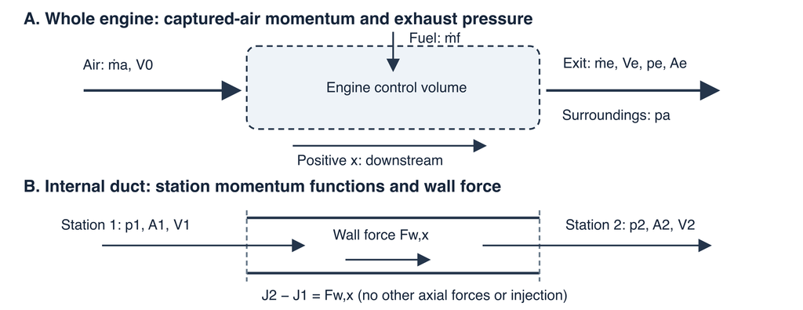

Figure 1.1. Original control-boundary diagrams. The upper boundary defines uninstalled engine performance; the lower one defines a force balance on the fluid inside a duct. The wall-force arrow indicates the positive convention, not its predicted sign.

A solvable component problem must specify enough independent information to determine its outlet. For example, continuity, momentum and energy alone do not supply an equation of state, a wall-friction law, a chemical composition or a nozzle branch. Conversely, prescribing geometry, all inlet and outlet states, heat addition and wall force independently may overconstrain the problem. Chapters 2, 24 and 26 show how particular closures turn the same balances into different computable models.

## 1.12 Applying the chapter in ThrustOne

Before comparing two outputs, identify the selected mode, reference mass flow, fuel or propellant denominator, exit-pressure closure and included boundary forces. The same engine label can contain a complete cycle model and a standalone component model with different boundaries.

Use exported SI inputs to recover the physical state behind a result. A changed display unit does not change the control volume. A changed model, nozzle closure or normalization does. The purpose of the following chapters is to make those differences explicit before deriving the individual model equations.

The following distinctions apply to the current implementation. They are physical interpretation rules; they do not require the reader to memorize an export schema.

| Model family or input | Interpretation needed for comparison |
| --- | --- |
| Turbojet cycle | Specific thrust is per captured air flow; an absolute force requires an air-flow scale. Afterburning consumption includes the fuel added downstream. |
| Separate-flow turbofan | Whole-engine specific thrust uses total captured air. Fuel-air ratio uses core air. A bypass-stream specific contribution may use bypass air, so stream quantities must be weighted before summation. |
| Variable-property turbofan | Core-based fuel and total-air-based specific thrust remain distinct, including the optional mixed-flow path. |
| Rocket performance | Thrust has no captured-air momentum subtraction. Impulse uses total propellant, and effective exhaust velocity includes any pressure-thrust contribution. |
| Calibrated scramjet full engine | Gross exhaust force and captured-air momentum give net force. The reported injected-mass impulse uses all modeled injection, not fuel alone. |
| Earlier constant-property scramjet flowpath | A net result requires captured-air information. A generic force label must be interpreted together with the mode and supplied boundary state. |
| F/G state reconstruction | F is a station momentum function. Constant-property G uses $c_pT+V^2/2$; NASA9 frozen G uses formation-inclusive enthalpy. These G values are not interchangeable. |

Two efficiency conventions require particular care. The constant-property turbojet and turbofan calculations retain a thrust-power overall efficiency when an exit is not fully expanded, but suppress the thermal/propulsive kinetic-energy split in that condition. The variable-property cycle implementation reports no such efficiency outputs even with fully expanded exits: it uses formation-enthalpy combustion and does not supply the compatible heating-value denominator used by the other model. A missing metric is therefore not equivalent to a zero metric or proof of failed calculation.

The balances in this chapter determine relationships among states and streams. Subsequent chapters supply the properties, losses, geometry and root choices needed to determine those states. That separation makes a meaningful comparison possible: first establish that both calculations describe the same boundary, then compare how their model assumptions predict the flow through it.

# 2. Static, stagnation and sonic states

## 2.1 A flowing state contains more than temperature and pressure

At a station in an engine, static temperature and static pressure describe the local thermodynamic state of a specified gas. Velocity supplies the additional information needed to describe its motion relative to the engine. A gas can therefore have the same static temperature and pressure at two stations yet carry different kinetic energy and different mass flux through equal areas.

The term *static* does not mean that the gas is stationary. It distinguishes local thermodynamic properties from properties obtained by imagining a particular process that brings the moving gas to rest. A fluid element moving at high speed still has a static temperature, density and pressure. In the notation of this book, an unsubscripted T or p is static unless the selected model states otherwise; the subscript t denotes a stagnation or total state.

Mass flow requires geometry as well as state. For a uniform one-dimensional stream normal to its section,

$$\dot m=\rho VA.$$

Neither T/p/M nor T/p/V alone fixes an absolute mass flow without an area. Conversely, prescribed mass flow can be used to recover area after the thermodynamic state and speed have been determined. This difference separates a state-reconstruction task from a nozzle-sizing task even when both display the same station quantities.

The following derivations assume a steady stream, negligible gravitational-height change and an ideal gas. Additional restrictions are stated as they are introduced. The distinction between a frozen gas and an equilibrium reacting mixture is deferred until Section 2.10; it cannot be hidden in the choice of a numerical gamma.

## 2.2 Thermally and calorically perfect descriptions

An ideal gas with fixed composition obeys

$$p=\rho RT,\qquad dh=c_p(T)\,dT,\qquad c_p(T)-c_v(T)=R.$$

Here R is the mixture-specific gas constant in J/(kg K). A thermally perfect description permits temperature-dependent heat capacity while retaining ideal-gas behavior. A calorically perfect description additionally holds $c_p$, $c_v$ and $\gamma=c_p/c_v$ constant. It follows that

$$c_p=\frac{\gamma R}{\gamma-1},\qquad
c_v=\frac{R}{\gamma-1}.$$

These are connected properties, not three arbitrary independent constants. Supplying mutually inconsistent values of R, cp and gamma would cause the energy equation and equation of state to describe different gases. The App’s constant-property models may derive one property from the others; a comparison with an external calculation must follow that same convention.

For a fixed composition the entropy differential is

$$ds=\frac{c_p(T)}{T}\,dT-R\frac{dp}{p}.$$

It separates thermal and pressure contributions. With constant cp, integration between two states gives

$$s_2-s_1=c_p\ln\frac{T_2}{T_1}-R\ln\frac{p_2}{p_1}.$$

Setting this change to zero produces an isentropic relation. It does not make an arbitrary real flow isentropic: a shock, friction or mixing can generate entropy while conserving total enthalpy. The state relation must be used with the physical process, not as a replacement for it.

## 2.3 Stagnation enthalpy comes from energy conservation

For an adiabatic stream with no shaft work, Chapter 1 gives

$$h_t=h+\frac{V^2}{2}=\text{constant along the modeled stream}.$$

The associated stagnation temperature is defined by $h(T_t)=h_t$ for the same frozen composition. Under the constant-cp approximation,

$$h(T_t)-h(T)=c_p(T_t-T)=\frac{V^2}{2},$$

and therefore

$$T_t=T+\frac{V^2}{2c_p}.$$

This temperature relation follows from energy; it does not require the actual deceleration to be reversible. A stationary adiabatic normal shock preserves total enthalpy even though it generates entropy. For the same calorically perfect gas this means total temperature is unchanged while total pressure falls.

A hot gas can possess considerable static enthalpy but modest kinetic energy. A colder gas moving rapidly can have the same total enthalpy. A nozzle uses this exchange to accelerate the stream; a diffuser converts kinetic energy into static enthalpy. Neither component creates energy simply by changing velocity.

For a variable-cp gas the correct relation is instead

$$\int_T^{T_t}c_p(\theta)\,d\theta=\frac{V^2}{2}.$$

The temperature on the upper limit is an unknown. Replacing the integral with $c_p(T)(T_t-T)$ is a further approximation. Formation-enthalpy constants cancel between states with unchanged composition, but they cannot generally be discarded when species compositions differ. Chapters 5 and 10 make the reacting and frozen reference conventions explicit.

Stagnation properties also depend on the velocity reference frame. A freestream that has one total enthalpy relative to the ground has another relative to a fast-moving engine. The cycle calculations use the engine frame. Rotating blade relative-total properties introduce a different frame and should not be substituted into an absolute-frame nozzle state.

## 2.4 Stagnation pressure requires an isentropic reference process

Stagnation pressure is the pressure reached by bringing the local flow to rest isentropically, with the selected composition constraint. It is a constructed state property; it is not generally the pressure that an actual lossy stopping process delivers.

For a calorically perfect gas, set $s_t=s$ in the entropy relation:

$$0=c_p\ln\frac{T_t}{T}-R\ln\frac{p_t}{p}.$$

Rearrangement gives

$$\frac{p_t}{p}=\left(\frac{T_t}{T}\right)^{c_p/R}
=\left(\frac{T_t}{T}\right)^{\gamma/(\gamma-1)}.$$

At zero velocity, Tt=T and pt=p. At nonzero velocity, the same gas has Tt>T and pt>p. Substituting total pressure into $\rho=p/(RT)$ while leaving the temperature static mixes two states and overestimates the local density. The static mass-flow equation must use a mutually compatible static density and speed.

If a fixed-composition adiabatic device preserves Tt but generates entropy, its inlet and outlet total states satisfy

$$s_2-s_1=-R\ln\frac{p_{t,2}}{p_{t,1}}.$$

A positive entropy change then corresponds to a total-pressure ratio below one. Total-pressure recovery can describe a loss even when total temperature is constant. Inlet recovery and combustor pressure-loss parameters should be interpreted in this way, rather than as direct changes in temperature or energy.

A pressure probe that creates a shock in a supersonic stream measures a post-shock stopping pressure. That measured value is not the upstream isentropic total pressure unless the shock loss is accounted for. This chapter defines the state quantities; it does not provide a probe-correction model or claim that the App reconstructs an arbitrary measurement installation.

## 2.5 Mach number and sonic reference ratios

For a frozen ideal-gas composition, the local acoustic speed follows from an isentropic infinitesimal disturbance:

$$a_f^2=\left(\frac{\partial p}{\partial\rho}\right)_{s,Y}
=\gamma(T)RT,\qquad M_f=\frac{V}{a_f}.$$

The subscript Y indicates that composition is held fixed. Under constant properties, writing V²=M²γRT in the stagnation-temperature relation gives

$$\tau(M)\equiv\frac{T_t}{T}
=1+\frac{\gamma-1}{2}M^2.$$

Temperature, pressure and density ratios then become

$$\frac{T}{T_t}=\tau^{-1},\qquad
\frac{p}{p_t}=\tau^{-\gamma/(\gamma-1)},\qquad
\frac{\rho}{\rho_t}=\tau^{-1/(\gamma-1)}.$$

The starred state is the sonic state on the same constant-property isentrope, with M=1:

$$\frac{T^*}{T_t}=\frac{2}{\gamma+1},\qquad
\frac{p^*}{p_t}=\left(\frac{2}{\gamma+1}\right)^{\gamma/(\gamma-1)}.$$

For gamma=1.4 these are approximately 0.833333 and 0.528282. They are ratios of static sonic properties to total properties. They are not ratios to a general inlet static state, and they change with gamma. In particular, 0.833333 follows directly from 2/2.4; a corrupted table or OCR value near it must not override the defining equation.

A star does not always identify a physical throat present in the geometry. A subsonic duct can be assigned a hypothetical sonic reference area for its existing mass flow and total state. That reference becomes the actual minimum-area section only when the assumptions and boundary conditions establish a choked smooth-nozzle solution.

## 2.6 Deriving the maximum mass flux

Define axial mass flux $j_m=\dot m/A=\rho V$. This notation avoids confusion with the G input used elsewhere for total specific enthalpy. Substituting the ideal-gas law, acoustic speed and static-to-total ratios gives

$$j_m=\frac{p_t}{\sqrt{T_t}}\sqrt{\frac{\gamma}{R}}\,
M\left(1+\frac{\gamma-1}{2}M^2\right)^{-\frac{\gamma+1}{2(\gamma-1)}}.$$

For fixed gas, pt and Tt, only the last two factors vary with Mach number. Put $b=(\gamma-1)/2$ and differentiate the logarithm with respect to M:

$$\frac{d\ln j_m}{dM}
=\frac{1}{M}-\frac{\gamma+1}{2(\gamma-1)}\frac{2bM}{1+bM^2}
=\frac{1-M^2}{M(1+bM^2)}.$$

The derivative is positive for 0<M<1, zero at M=1 and negative for M>1. Thus the sonic state maximizes mass flux at fixed total conditions. The critical value is

$$j_m^*=\frac{p_t}{\sqrt{T_t}}\sqrt{\frac{\gamma}{R}}
\left(\frac{2}{\gamma+1}\right)^{\frac{\gamma+1}{2(\gamma-1)}}.$$

An increase in velocity on the supersonic branch is accompanied by a sufficiently large density decrease that mass flux falls. Faster flow does not automatically mean more mass through the same area when total conditions are held fixed.

The formula also exposes its scale dependence: doubling pt doubles the critical mass flux, while multiplying Tt by four halves it if gas properties remain unchanged. In a reacting chamber, temperature and properties can change together, so the latter relation is a controlled constant-property comparison, not a complete combustion trend.

Choking means that a selected throat has reached this limiting mass flux for its upstream total state. Further changes downstream cannot simply demand a larger steady mass flow through that same section without changing the upstream state or the physical flow pattern. It does not mean that every station is sonic or that the entire engine stops responding to operating conditions.

## 2.7 Area–Mach inversion and the two roots

For the same stream and isentropic total conditions,

$$\dot m=A j_m=A^*j_m^*.$$

Taking the ratio gives

$$\frac{A}{A^*}=\frac{1}{M}
\left[\frac{2}{\gamma+1}
\left(1+\frac{\gamma-1}{2}M^2\right)\right]^{\frac{\gamma+1}{2(\gamma-1)}}.$$

This function reaches its minimum value of one at M=1. For a ratio greater than one, it has a subsonic root and a supersonic root. The specified area ratio by itself cannot choose between them. A ratio below one has no root under these assumptions. An algorithm that silently returns one branch has added a physical assumption without informing the reader.

The differential form explains the geometry. Continuity gives $d\rho/\rho+dV/V+dA/A=0$. For an inviscid isentropic stream without added mass or heat, momentum gives $dp=-\rho V\,dV$, and the acoustic relation gives $dp=a^2d\rho$. Combining them yields

$$\frac{d\rho}{\rho}=-M^2\frac{dV}{V},\qquad
\frac{dA}{A}=(M^2-1)\frac{dV}{V}.$$

A subsonic flow accelerates through a contraction, whereas a supersonic flow accelerates through an expansion. Smooth passage through M=1 requires an area extremum in this restricted model; a converging-diverging nozzle supplies the familiar minimum. The relation does not guarantee that a supplied back pressure will establish the supersonic solution downstream. Shock-containing and entirely subsonic solutions require the appropriate boundary treatment.

Heat transfer, friction and injection alter this differential equation. Consequently the common statement “Mach one occurs at the minimum area” is not a general theorem for the source-term ducts used in other App modes. A sonic event in such a model is a compatibility condition, not merely a geometric feature.

## 2.8 Worked example: the same area supports different states

Use gamma=1.4, R=287 J/(kg K), pt=300 kPa and Tt=600 K. Let a choked reference throat have area 0.004 m². The constant-property model gives

$$T^*=600\frac{2}{2.4}=500\ \mathrm{K},
\qquad p^*\approx158.485\ \mathrm{kPa}.$$

The critical mass flux is approximately 495.023 kg/(m² s), so the mass flow is

$$\dot m=0.004(495.023)\approx1.98009\ \mathrm{kg/s}.$$

Select a downstream area ratio of 1.6875, giving A=0.00675 m². The supersonic area root is M=2. At that state,

$$T=\frac{600}{1+0.2(2)^2}=333.333\ \mathrm{K},$$
$$p=300\left(\frac{333.333}{600}\right)^{3.5}
\approx38.3414\ \mathrm{kPa},$$
$$V=2\sqrt{1.4(287)(333.333)}\approx731.938\ \mathrm{m/s}.$$

Using static density gives approximately 0.400781 kg/m³. Multiplying density, speed and exit area recovers 1.98009 kg/s.

The subsonic root for the same area ratio is approximately 0.372244. It has a much higher pressure and density, and a much lower speed:

| Quantity | Subsonic area root | Supersonic area root |
| --- | --- | --- |
| Mach number | 0.372244 | 2.000000 |
| Static temperature, K | 583.820 | 333.333 |
| Static pressure, kPa | 272.627 | 38.3414 |
| Speed, m/s | 180.291 | 731.938 |
| Density, kg/m³ | 1.62708 | 0.400781 |
| Mass flux, kg/(m² s) | 293.347 | 293.347 |

The two states share total conditions, mass flux and area ratio, but their pressures are very different. They are alternative algebraic branches, not two simultaneous exit states. Connecting a selected root to an actual throat and prescribed ambient pressure requires a complete nozzle-flow solution. In particular, this table is not a model of a normal shock between the two states: a physical shock would change total pressure and would not connect them on the same isentrope.

## 2.9 Near-sonic inversion is sensitive

Let $M=1+\delta$. Expanding the area relation around its minimum gives

$$\frac{A}{A^*}=1+\frac{2}{\gamma+1}\delta^2+O(\delta^3).$$

There is no linear term. The two branches approach each other as the square root of the area excess:

$$M\approx1\pm\sqrt{\frac{\gamma+1}{2}\left(\frac{A}{A^*}-1\right)}.$$

For gamma=1.4, an area-ratio excess of 0.0001 corresponds to a leading-order Mach deviation of about 0.0109545. An area displayed as 1.000 to only three decimal places can therefore conceal a physically relevant difference between slightly subsonic and slightly supersonic states.

Direct substitution provides another illustration: M=0.99 gives A/A*=1.000083802, while M=1.01 gives 1.000082876. The small asymmetry comes from terms beyond the quadratic approximation. Rounding both ratios to one would erase both the deviation and the branch.

This is conditioning, not automatically a defective root solver. The slope of the forward area function vanishes at the minimum, so its inverse becomes sensitive. A solver should retain the selected branch and sufficient internal precision; a report should not imply more information than the input area ratio supports. Chapters 26 and 33 discuss the related distinction between a valid limiting state, an unbracketed root and a terminated integration.

## 2.10 Frozen variable-property expansion

For a frozen ideal-gas mixture, R remains constant with temperature but cp and gamma may change. Specify the total state and composition. A trial static temperature supplies enthalpy and entropy, from which the isentropic pressure and speed follow:

$$\ln\frac{p_t}{p}=\frac{1}{R}\int_T^{T_t}\frac{c_p(\theta)}{\theta}\,d\theta,
\qquad
V(T)=\sqrt{2[h(T_t)-h(T)]}.$$

Then $\rho(T)=p(T)/(RT)$, $j_m(T)=\rho(T)V(T)$, and the local frozen Mach number follows from the local heat-capacity ratio. This sequence replaces a single global gamma power law. The property data must support every trial state, not only the inlet and final accepted exit.

An original analytic example makes the distinction visible without relying on a species database. Let a hypothetical frozen ideal gas have R=287 J/(kg K) and

$$c_p(T)=1000+0.1T\quad\mathrm{J/(kg\,K)}$$

over the chosen illustrative interval. The coefficient 0.1 has units J/(kg K²). Between T=600 K and Tt=900 K,

$$h_t-h=1000(900-600)+0.05(900^2-600^2)
=322{,}500\ \mathrm{J/kg}.$$

Therefore V≈803.119 m/s. At the static state cp=1060 J/(kg K), gamma≈1.37128 and the local frozen acoustic speed is approximately 485.937 m/s, giving M≈1.65272. The exact pressure ratio for this hypothetical property law is

$$\frac{p_t}{p}=\exp\left[
\frac{1000\ln(900/600)+0.1(900-600)}{287}\right]
\approx4.55990.$$

If cp were frozen at its 600 K value for the entire deceleration, the same kinetic energy would instead give Tt≈904.245 K and a pressure ratio of approximately 4.54904. The point is not that this particular difference is always large. The approximation has changed both the energy integral and entropy integral, and no single local gamma guarantees that both are represented consistently. The App’s NASA-property models use their actual property functions, not this illustrative linear law.

For fixed composition, maximizing the isentropic mass flux still leads to the local frozen sonic condition. Along the isentrope, energy gives $V\,dV=-dh=-dp/\rho$, while $dp=a_f^2d\rho$. It follows that

$$\frac{d(\rho V)}{d\rho}=V-\frac{a_f^2}{V},$$

which vanishes at V=af. This is a local property result; it does not restore the constant-gamma area formula. The critical temperature and pressure must still be found using the variable-property enthalpy and entropy relations.

In an equilibrium expansion, composition is allowed to change along the path. The path derivative used to identify maximum mass flux is then different from the frozen acoustic derivative. A reported frozen Mach number need not equal one at the equilibrium critical state. ThrustOne distinguishes the equilibrium critical mass-flux closure from its local `frozen_mach` diagnostic; Chapter 17 develops the chemical and sonic conventions in detail.

## 2.11 What choking does and does not determine

A convergent nozzle connected to a reservoir provides a simple boundary example. If downstream pressure is sufficiently high, the nozzle can remain subsonic, with exit static pressure matching the downstream condition in the ideal model. As back pressure falls to the critical ratio, the minimum-area exit becomes sonic. Further lowering ambient pressure does not lower the internal exit pressure in the ideal choked convergent model; instead the jet is underexpanded outside the exit.

This distinction prevents an invalid combination of assumptions: setting the exit of a convergent nozzle to M=1 while also assigning it an arbitrary pressure below the critical static pressure at unchanged total conditions overdetermines the state. A calculation that fully expands to a specified low pressure may be sizing an exit area for a converging-diverging nozzle rather than predicting a fixed convergent nozzle.

A supersonic area-root calculation has a similarly limited meaning. It determines a candidate isentropic exit state from area ratio and total conditions. It does not automatically determine whether the physical nozzle has an internal shock, separated flow or a start transient. Those features require further equations and information. The selected App mode must tell the reader which boundary problem is actually closed.

The constant-property cycle, frozen-property nozzle and equilibrium rocket nozzle share conservation laws but impose different closures and property assumptions. Their results should be compared by matching total state, composition, area and ambient convention, not simply by matching a label such as “nozzle exit Mach.”

## 2.12 Relating the derivation to the selected App mode

The same physical relation appears under different boundary conditions in the App. The distinctions below are essential to choosing an interpretable calculation.

| Calculation | State/branch actually determined | Interpretation limit |
| --- | --- | --- |
| Explicit-gas rocket performance | Supersonic area–Mach exit root, with a sonic limit at unity area ratio | Ambient pressure changes the pressure-thrust term and warnings; it does not automatically reposition a shock or select a subsonic exit. |
| Finite-contraction chamber plane | Subsonic area–Mach root from a supplied static chamber plane, then conversion to total conditions | This is an independent finite-contraction calculation, not an automatic correction applied to all rocket modes. |
| Constant-property component nozzle | Expansion to a prescribed exit static pressure | Its critical-pressure-ratio/choking flag is diagnostic; it does not clamp the exit Mach to one or size an area. |
| Frozen-property component nozzle | Entropy and enthalpy closure at the prescribed exit pressure | A state calculation without fixed-geometry ambient matching or a separation solution. |
| Separate-flow turbofan off-design | Fixed-throat convergent-nozzle constraints within reference-normalized matching | Available total-to-ambient pressure ratio is capped at the sonic ratio for the internal exit state; pressure mismatch remains in the force accounting. |
| Frozen variable-property nozzle profile | Sonic or supersonic inlet, nondecreasing area, conserved entropy and total enthalpy | A supersonic inlet need not be the throat. The permitted branch never crosses through a sonic singularity into a subsonic solution. |
| Frozen thermochemical rocket nozzle | Chamber composition established first, then a frozen sonic throat and downstream expansion | Requires ambient pressure below the model’s throat pressure; it does not solve the alternative unchoked branch. |
| Equilibrium rocket nozzle | Critical state at an interior maximum of equilibrium mass flux, then a post-critical expansion branch | Local frozen Mach is a diagnostic, not the equilibrium sonic definition. A selected freeze area is an input, not a predicted kinetic freeze location. |

Temperature-domain checks in variable-property calculations are physical-data constraints. A requested expansion that would fall below the mixture’s common data range is rejected instead of extrapolating the species fits. The existence of a constant-gamma answer outside that interval does not authorize the variable-property model to continue there.

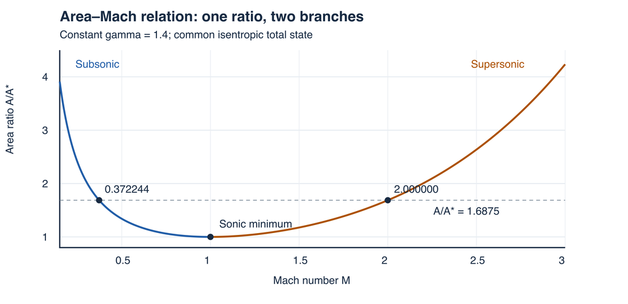

Figure 2.1. Original constant-gamma area–Mach curve for gamma=1.4. A single ratio above unity intersects the subsonic and supersonic branches. The example ratio 1.6875 intersects at approximately M=0.372244 and M=2; the branches coalesce at the sonic minimum.

When reading a result, first identify whether its boundary was specified by exit pressure, area ratio, an inlet state and increasing area, or reference-matched convergent geometry. Only then interpret its Mach number, mass flow and pressure-thrust contribution. The algebra of an isentrope is common to these problems; their boundary conditions decide which particular state it describes.

# 3. Performance normalization and similarity

## 3.1 Why one physical engine needs several coordinate systems

A compressor running at the same shaft speed does not necessarily operate at the same aerodynamic condition when its inlet temperature changes. The blade speed can remain fixed while the acoustic speed changes. Similarly, the same air mass flow passing through a component at lower inlet pressure occupies a larger volume and may require a different flow velocity. Raw rpm and kg/s therefore do not isolate the similarity of the internal flow.

Normalization removes selected scales so that meaningful comparisons become easier. It does not remove the underlying physics. A corrected coordinate can compensate for inlet temperature and pressure while leaving Reynolds-number effects, tip clearance, gas composition and geometry changes unresolved. Two points close together on a corrected map are not automatically interchangeable engines.

Three different operations must be kept separate. A dimensionless quantity has no physical units, such as a pressure ratio. A corrected quantity retains units while referring a measured value to a chosen temperature and pressure convention. A reference-normalized quantity is a ratio to one selected operating point. A corrected mass flow in kg/s, a mass-flow parameter containing dimensional gas constants, and a flow ratio relative to a design point are related but are not the same object.

The distinction matters in ThrustOne because component-map coordinates, standalone component states and reference-based off-design calculations coexist. External maps may use rpm, a fraction of design corrected speed, or a percentage. ThrustOne expects its map coordinates and dependent tables to be dimensionless and design-point normalized; it does not perform the physical temperature/pressure correction on import. An external map must first be expressed in that convention.

## 3.2 Obtaining flow and speed similarity groups

Consider geometrically similar rotating components with characteristic diameter D. Let inlet total pressure and temperature be pt and Tt, and let the working gas have fixed R and gamma. The acoustic velocity scale is proportional to $\sqrt{RT_t}$. A density scale is proportional to $p_t/(RT_t)$. Their product with an area scale gives a mass-flow scale:

$$\rho_{scale}V_{scale}D^2
=\frac{p_t}{RT_t}\sqrt{RT_t}D^2
=\frac{p_tD^2}{\sqrt{RT_t}}.$$

A corresponding dimensionless flow group is

$$\Pi_m=\frac{\dot m\sqrt{RT_t}}{p_tD^2}.$$

Let N denote shaft revolutions per second. Blade speed is proportional to ND, so a dimensionless speed group is

$$\Pi_N=\frac{ND}{\sqrt{RT_t}}.$$

Using angular velocity instead of revolutions per second introduces the constant 2π; using rpm introduces a factor of 60. Such constants are harmless only when they are carried consistently. An rpm coordinate cannot be inserted into a formula calibrated with revolutions per second without conversion.

For a fixed component diameter and fixed gas, holding these groups constant gives the familiar proportionalities

$$\dot m\frac{\sqrt{T_t}}{p_t}=\text{constant},
\qquad \frac{N}{\sqrt{T_t}}=\text{constant}.$$

The first result also follows from the mass-flux relation in Chapter 2 for fixed Mach number and area. A compressor does not have one uniform Mach number everywhere, but the scaling motivates useful correlating coordinates for similar internal flow patterns.

Additional dimensionless parameters remain. Reynolds number involves viscosity, speed, density and length. Relative clearance involves a clearance-to-diameter ratio. Gas-property changes affect gamma and the thermodynamic conversion from work to pressure ratio. Consequently a family of maps at matched corrected flow and speed may still show changes in efficiency or stability boundaries. In this book, similarity is a stated approximation or a data correlation, never a claim that two dimensional scales determine every feature of a real compressor.

## 3.3 Corrected quantities retain a reference convention

Choose reference temperature Tref and pressure pref. At the inlet station relevant to the component, define

$$\theta=\frac{T_t}{T_{ref}},\qquad
\delta=\frac{p_t}{p_{ref}}.$$

The usual fixed-gas corrected mass flow and corrected speed are

$$\dot m_c=\dot m\frac{\sqrt{\theta}}{\delta},
\qquad N_c=\frac{N}{\sqrt{\theta}}.$$

Because theta and delta are dimensionless, corrected mass flow has the same units as actual mass flow and corrected speed has the same units as actual speed. These definitions can be inverted:

$$\dot m=\dot m_c\frac{\delta}{\sqrt{\theta}},
\qquad N=N_c\sqrt{\theta}.$$

The pressure and temperature belong to the chosen component inlet, not automatically to the atmosphere. In a turbojet, the compressor inlet total state follows the inlet’s ram rise and pressure recovery. In a turbofan, the high-pressure compressor inlet follows the fan or booster path. Correcting every spool with freestream static conditions would mix incompatible reference stations.

A turbine and compressor on one shaft share actual mechanical speed, but their corrected speeds usually differ because their inlet total temperatures differ. If the same Tref is used for both,

$$\frac{N_{c,t}}{N_{c,c}}=\sqrt{\frac{T_{t,c}}{T_{t,t}}}.$$

There is no mechanical contradiction: the two coordinates describe the same shaft motion relative to different local acoustic scales.

The selected reference conditions are part of a data definition. They should accompany a map or case documentation. A corrected value without its inlet station and reference temperature/pressure is an incomplete specification, even if the number is finite and lies inside a tabulated axis range.

## 3.4 Worked example: preserving an aerodynamic coordinate

Use the illustrative convention Tref=288 K and pref=100 kPa. Suppose a reference component point has inlet totals equal to these values, actual mass flow 20 kg/s and actual speed 10000 rpm. Its corrected values are then 20 kg/s and 10000 rpm.

Now change the inlet totals to 360 K and80 kPa while asking for the same corrected coordinates. The ratios are theta=1.25 and delta=0.8. Therefore,

$$\dot m=20\frac{0.8}{\sqrt{1.25}}
\approx 14.3108\ \mathrm{kg/s},$$
$$N=10000\sqrt{1.25}\approx 11180.34\ \mathrm{rpm}.$$

The hotter stream requires a higher actual speed to maintain the same corrected speed. The reduced pressure and higher temperature reduce the actual mass flow corresponding to the selected corrected flow. Feeding the old actual values into the new state would move the operating point on the map.

For example, retaining 10000 rpm at 360 K gives a corrected speed of approximately8944.27 rpm under this convention. A controller holding actual speed fixed and a calculation holding corrected speed fixed are imposing different conditions. Neither is intrinsically wrong; they answer different questions.

These calculations do not establish that the same point is physically attainable at both conditions. They presume the same gas, geometry and usable map correlation. Temperature limits, Reynolds-number changes and shaft constraints can invalidate the supposed correspondence. The example isolates the coordinate transformation so those additional decisions remain visible.

## 3.5 Changing the correction convention does not change the engine

Suppose the same map data are re-expressed using Tref,2 and pref,2 rather than Tref,1 and pref,1. Applying the definitions to the same actual state gives

$$\frac{\dot m_{c,2}}{\dot m_{c,1}}
=\sqrt{\frac{T_{ref,1}}{T_{ref,2}}}
\frac{p_{ref,2}}{p_{ref,1}},
\qquad
\frac{N_{c,2}}{N_{c,1}}
=\sqrt{\frac{T_{ref,2}}{T_{ref,1}}}.$$

For the preceding 20 kg/s and 10000 rpm corrected point, changing the convention to300 K and101.325 kPa gives approximately 19.8556 kg/s and 10206.21 rpm. The physical engine has not changed. Every point and every query must be transformed consistently before the new coordinates can be used.

A design-normalized map may instead use $\widehat N_c=N_c/N_{c,R}$. A value of 0.95 then means 95% of the reference corrected speed. It does not mean 0.95 rpm, and it does not necessarily mean 95% of reference mechanical speed. With $T_t/T_{t,R}=1.21$, a mechanical speed ratio of 0.95 corresponds to

$$\frac{N_c}{N_{c,R}}
=\frac{N}{N_R}\sqrt{\frac{T_{t,R}}{T_t}}
=\frac{0.95}{1.1}\approx 0.863636.$$

The corrected speed ratio has changed more because the inlet is hotter. Conversely, holding a corrected speed ratio at 0.95 under these temperature conditions would imply a mechanical speed ratio of1.045. Confusing the two could conceal a shaft-speed exceedance in a real application, even though a simple map interpolation produces a valid number.

## 3.6 Pressure, temperature and work ratios describe different effects

A component total-pressure ratio is $\pi=p_{t,out}/p_{t,in}$; its total-temperature ratio is $\tau=T_{t,out}/T_{t,in}$. These definitions do not include an efficiency by themselves. A compressor model supplies the relation between them.

For a calorically perfect gas and an isentropic compressor, $\tau_s=\pi^{(\gamma-1)/\gamma}$. With an isentropic efficiency defined as ideal work divided by actual work,

$$\eta_c=\frac{\tau_s-1}{\tau-1},
\qquad
\tau=1+\frac{\pi^{(\gamma-1)/\gamma}-1}{\eta_c}.$$

The actual specific work is $\Delta h_t=c_pT_{t,in}(\tau-1)$. Thus the same pressure ratio and efficiency require more work per kilogram when the inlet total temperature is higher. A pressure-ratio match alone is not a shaft-power match.

A polytropic efficiency uses a different differential process convention and produces a different finite pressure-to-temperature relation. One must not replace isentropic efficiency with a polytropic number in the equation above. Chapters11 and15 derive the component conventions; here the important distinction is between a coordinate definition and the physical relation that connects coordinates.

For a fixed-geometry compressor family, a simplified work-coefficient assumption may give

$$\Delta h_t=K N^2,$$

where K contains geometry, units and the assumed work coefficient. This is an operating-region approximation, not a universal compressor law. Combining it with the constant-property isentropic-efficiency relation and dividing by a reference point gives

$$\left(\frac{N}{N_R}\right)^2
=\frac{T_{t,in}}{T_{t,in,R}}
\frac{\pi^{(\gamma-1)/\gamma}-1}
{\pi_R^{(\gamma-1)/\gamma}-1}
\frac{\eta_{c,R}}{\eta_c}.$$

If efficiency is unchanged, the last factor is one. The inlet-temperature ratio disappears only after converting this mechanical-speed ratio into a corrected-speed ratio. This derivation explains why a speed estimate in a reference-normalized cycle can resemble a map relation without actually using a measured map.

Changing gas composition or cp changes the derivation as well. A variable-property compressor requires an enthalpy calculation, and the assumed constant K may no longer represent the same blade loading. Similarity relations should therefore be restricted to the gas and component approximation under which they were obtained.

## 3.7 A reference point replaces constants, not missing equations

Referencing is useful when a constant is difficult to identify separately but an operating point is known. For a choked section with fixed area, gas and discharge convention, Chapter2 gives

$$\dot m=C\frac{p_t}{\sqrt{T_t}}.$$

The constant C includes the area and critical-flow factor. Comparing with a reference state eliminates it:

$$\frac{\dot m}{\dot m_R}
=\frac{p_t}{p_{t,R}}\sqrt{\frac{T_{t,R}}{T_t}}.$$

If the section area changes, an area ratio must be restored. If gamma or R changes, the critical-flow factors must also be restored. If the section becomes unchoked, the Mach-dependent mass-flow function replaces the fixed sonic factor. A reference value does not authorize a model to ignore those changes.

As a simple original example, a fixed choked section with total-pressure ratio0.7 and total-temperature ratio1.2 has a mass-flow ratio of approximately 0.639010. Multiplying a reference flow of 25 kg/s gives about 15.9752 kg/s. The reduction is stronger than the pressure ratio alone because the gas is hotter. This applies to the mass passing through the selected section. Converting hot-gas flow to captured air requires the fuel-addition and bleed assumptions, rather than silently equating the two flows.

A full off-design engine must satisfy multiple constraints simultaneously: compatible component mass flows, shaft power balances, nozzle capacity, specified geometry and an operating control such as fuel flow or turbine temperature. A reference point can supply constants in these equations. It cannot replace the equations themselves. If a model assumes two sections remain choked, its result is conditional on that assumption even when every reference-normalized residual is small.

## 3.8 Map coordinates and physical operating lines

A component map relates performance quantities over an operating domain. In the App’s representation, a dimensionless corrected-speed axis and a beta axis locate a point, while normalized corrected flow, pressure-ratio multiplier and efficiency multiplier are dependent tables. Beta is an ordering coordinate along a tabulated line; it is not inherently a blade angle, a bypass ratio or a physical control setting.

This representation permits interpolation without requiring every speed line to have the same corrected-flow values. It also means that a requested corrected flow is not simply the second map coordinate. In general an inverse query would search for beta locations whose interpolated output matches a target quantity, and a nonmonotone map could have multiple inverse roots. The current App implements a narrower inverse: it requires consistently monotone pressure-ratio rows and solves for beta at a prescribed normalized speed and pressure-ratio multiplier. It rejects a nonmonotone map for this inverse task rather than providing a multiple-root selector. It does not invert corrected flow.

A component’s operating line is generated by the rest of the engine and its controls. Interpolating a map at a prescribed speed and beta does not solve for that operating line. Neither does drawing a smooth curve through available points establish a surge boundary from first principles. A surge-pressure-ratio array, where supplied, is additional normalized information. The App reports the pressure-ratio indicator pi_surge/pi_operating − 1. That is neither a mass-flow-distance margin nor a dynamic stability prediction.

Out-of-range coordinates require new physical information, not just a more convenient interpolation formula. The App rejects extrapolation from the supplied map domain. That refusal is materially different from predicting that the real component cannot operate anywhere beyond the table: the table may be incomplete, while the App has no justified model for the unprovided region.

## 3.9 Using normalized results without overstating similarity

Before comparing two runs, identify the correction inlet station, reference temperature and pressure, gas model, geometry, reference operating point, and whether a displayed speed is actual, corrected or reference-normalized. Chapter1’s flow-basis rules still apply: a corrected core flow is not automatically corrected total inlet air, and a core-based specific work is not a whole-engine power.

Data provenance must be carried by the case or accompanying map documentation. A file that preserves the numeric map axes but omits their engineering meaning can round-trip perfectly while remaining ambiguous. A successful import proves that a data structure was read, not that its corrected coordinates match the intended reference convention.

Reference-normalized turbine-engine modes are useful because they expose changes around a specified design state without demanding a complete measured component set. Their limits should be stated positively and precisely: fixed-area or choked assumptions, supplied reference states, chosen efficiency relations and the matching equations actually solved. They should not be described as arbitrary engine simulation, a validated stability envelope or a general substitute for measured maps.

The following chapters use these distinctions to connect atmospheric inputs, component states and engine cycles. A normalization is successful when it makes the model’s assumptions easier to inspect, rather than hiding them behind apparently universal curves.

## 3.10 Interpreting the App’s map multipliers

A small original example shows why a normalized map output is not itself a physical pressure ratio. Suppose the standalone compressor calculation supplies a baseline total-pressure ratio of10 and a baseline isentropic efficiency of0.85. At the selected dimensionless corrected speed and beta, let the map return flow multiplier0.90, pressure-ratio multiplier1.10 and efficiency multiplier0.96. The component uses

$$\pi_c=10(1.10)=11.0,\qquad
\eta_c=0.85(0.96)=0.816.$$

The flow ordinate0.90 remains a dimensionless corrected-flow ratio. It is not0.90 kg/s and cannot be turned into an absolute flow without the missing design-flow scale and correction convention. If an inverse query is intended to find this point, its target map pressure-ratio multiplier is1.10, not the component’s physical pressure ratio11.0.

If the normalized surge pressure ratio at this speed is1.20, the displayed pressure-ratio margin is

$$\frac{1.20}{1.10}-1\approx0.090909.$$

The common normalization cancels in this ratio. A margin of about9.09% under this convention says nothing by itself about transient surge onset or the distance in mass flow to a physical stability boundary. It is a useful interpretation of supplied map data, not a replacement for such data.

The analytic demonstration-map generator selects a design point and normalizes its dependent tables there. It illustrates the workflow; it is not a measured manufacturer’s map. The generic beta axis is only required to be finite and strictly increasing. Although the demonstration generator uses beta from0 to1, that interval does not establish a universal physical meaning for beta.

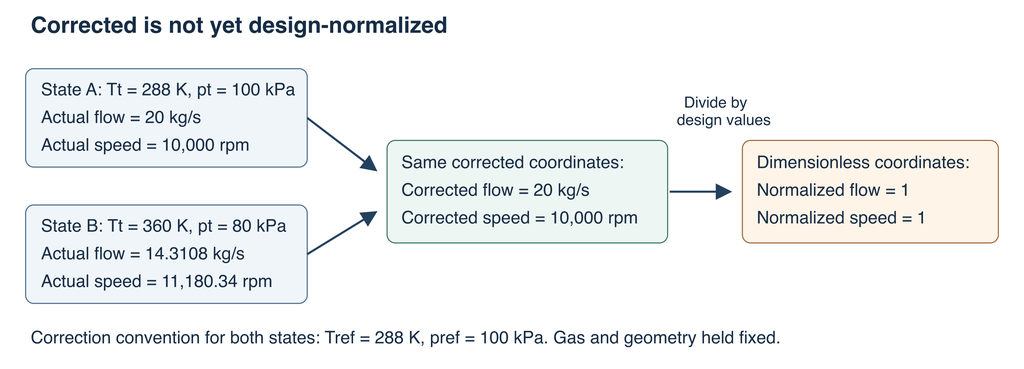

Figure 3.1. Original coordinate transformation. Different dimensional inlet conditions can produce the same corrected coordinates; design-point normalization is an additional operation. The App’s map consumes normalized coordinates rather than reconstructing them from rpm and mass flow.

The cycle-level reference models use another set of quantities. Their mechanical spool-speed ratios include the appropriate inlet total-temperature factors in the work relation. They are inferred speed ratios under a closed-form reference model, not measured shaft speeds and not the normalized corrected-speed coordinates of the standalone component map. The single-spool turbojet also reports a corrected-flow ratio obtained from its own reference closure; that output is not automatically the ordinate of an independently supplied map.

The distinction prevents a tempting but invalid shortcut: taking a cycle’s mechanical speed ratio, inserting it directly as map corrected speed, and treating the returned flow multiplier as a completed whole-engine match. A coupled match would require compatible reference stations and scales, component flow continuity, shaft-power constraints and nozzle conditions to be solved together. The present map lookup and reference-cycle modes are separate bounded calculations.

# 4. Freestream and inlet bookkeeping

An engine calculation begins before air crosses its physical inlet. The flight condition establishes a static thermodynamic state, the speed of the incoming stream, and the energy and momentum carried toward the engine. The inlet then changes that state. Keeping these operations distinct prevents an atmospheric pressure from being mistaken for compressor entry pressure, or an inlet pressure loss from being applied twice.

This chapter develops the route from a flight specification to inlet boundary conditions. The atmosphere supplies an optional relation between altitude, pressure and temperature. Gas properties turn Mach number into velocity. A stagnation calculation accounts for ram heating. An inlet model supplies losses or a downstream state. Finally, a chosen capture area converts incoming mass flux into mass flow. Each operation requires its own assumptions.

The reader should be able to reconstruct a resolved flight state, explain which quantities are independently specified, and identify when two superficially similar input routes describe different physical conditions. Chapter 2 supplies the detailed stagnation derivation; Chapter 3 supplies corrected-flow conventions. The calibrated variable-property inlet receives its full treatment in Chapter 27.

## 4.1 Stations before components

Use station 0 for the undisturbed incoming stream and station 2 for a representative inlet exit or compressor entry. At station 0, distinguish static pressure $p_0$ from total pressure $p_{t0}$. The subscript 0 identifies a location; it does not itself mean stagnation. Likewise, $T_0$ is the local static temperature and $T_{t0}$ is the temperature associated with bringing that stream to rest adiabatically without shaft work.

For a calorically perfect ideal gas,

$$\rho_0=\frac{p_0}{RT_0},\qquad
a_0=\sqrt{\gamma RT_0},\qquad V_0=M_0a_0.$$

These relations require composition through $R$, and the heat-capacity model through $\gamma$. Mach number alone does not specify speed. Two streams at the same Mach number and different temperatures have different velocities even when their composition is identical.

An adiabatic inlet without shaft work preserves total enthalpy while dissipative mechanisms increase entropy. Its static pressure may increase as velocity decreases, while total pressure decreases. These statements are compatible: static pressure measures one part of the local state, while total pressure also reflects the stream’s recoverable mechanical potential.

A cycle inlet can be represented by total-pressure recovery without resolving its internal geometry. A flowpath inlet instead needs a downstream static state, velocity and area relationship. The amount of information returned by these two models differs. A recovery factor alone cannot locate shocks, predict boundary-layer separation or determine an exit Mach number.

## 4.2 Standard atmosphere as a closure

An altitude is a geometric coordinate. It becomes a thermodynamic state only after an atmospheric model has been selected. A standard atmosphere provides a reproducible reference profile; it does not measure the weather encountered by a vehicle.

ThrustOne’s standard-atmosphere helper uses a constant-molecular-weight approximation over geometric altitudes from 0 to 86 km. Its sea-level values are

$$T_{\mathrm{SL}}=288.15\ \mathrm{K},\quad
p_{\mathrm{SL}}=101325\ \mathrm{Pa},\quad
R=287.05287\ \mathrm{J\,kg^{-1}K^{-1}}.$$

The profile uses geopotential altitude $H$ internally. With geometric altitude $z$ and reference Earth radius $R_E=6356766\ \mathrm{m}$,

$$H=\frac{R_Ez}{R_E+z},\qquad
z=\frac{R_EH}{R_E-H}.$$

This transformation allows a constant reference gravitational acceleration $g_0=9.80665\ \mathrm{m\,s^{-2}}$ in the hydrostatic equations. Under the corresponding inverse-square gravity approximation,

$$\frac{dH}{dz}=\frac{R_E^2}{(R_E+z)^2},\qquad
g(z)\,dz=g_0\,dH.$$

Geometric and geopotential altitude are close near sea level, but their difference grows with height. Layer boundaries below are geopotential values; entering a listed boundary as geometric altitude does not place the calculation exactly on that boundary.

| Geopotential layer base, km | Base temperature, K | Lapse rate, K/km |
| --- | --- | --- |
| 0 | 288.15 | −6.5 |
| 11 | 216.65 | 0 |
| 20 | 216.65 | +1.0 |
| 32 | 228.65 | +2.8 |
| 47 | 270.65 | 0 |
| 51 | 270.65 | −2.8 |
| 71 | 214.65 | −2.0 |

The lapse rate is $dT/dH$, with its sign included. The final layer is used only up to the supported upper boundary. This is a piecewise atmospheric reference, not a promise that constant gas properties or an engine model remain physically adequate throughout the full altitude range.

### Hydrostatic pressure in a layer

A stationary atmosphere obeys

$$\frac{dp}{dH}=-\rho g_0=-\frac{pg_0}{RT}.$$

Within a layer beginning at $H_b$, write

$$T=T_b+L(H-H_b).$$

For nonzero lapse rate $L$, integration gives

$$\ln\frac{p}{p_b}=-\frac{g_0}{RL}\ln\frac{T}{T_b},\qquad
p=p_b\left(\frac{T}{T_b}\right)^{-g_0/(RL)}.$$

For an isothermal layer, integrate with $T=T_b$:

$$p=p_b\exp\left[-\frac{g_0(H-H_b)}{RT_b}\right].$$

The exponential relation is also the limit of the lapse relation as $L$ approaches zero. Substituting a zero lapse rate directly into the power-law expression creates a division by zero; the separate expression is part of the model’s definition.

Pressure at a new layer base is inherited from the preceding layer. It is not reset to sea-level pressure. This propagation preserves pressure continuity; the specified base temperatures preserve temperature continuity. The slope of temperature can change abruptly even though temperature itself remains continuous. Consequently, derivatives of downstream quantities may change at layer boundaries without indicating a solver defect.

## 4.3 Dynamic pressure is not stagnation-pressure rise

Dynamic pressure is defined by

$$q=\frac{1}{2}\rho_0V_0^2.$$

For the constant-property ideal gas above,

$$q=\frac{\gamma}{2}p_0M_0^2.$$

Temperature cancels because density varies inversely with temperature while squared speed at fixed Mach varies directly with temperature. This cancellation is conditional on the selected gas model. With temperature-dependent heat capacities, $\gamma$ itself changes with temperature.

The corresponding inversions are

$$p_0=\frac{2q}{\gamma M_0^2},\qquad
M_0=\sqrt{\frac{2q}{\gamma p_0}}.$$

The first inversion requires nonzero Mach number. At $M_0=0$, every finite positive static pressure gives $q=0$; the pair $M_0=0,q=0$ cannot determine pressure. Positive $q$ paired with zero Mach is inconsistent. The second inversion is well defined at zero dynamic pressure when static pressure is already known.

Total pressure follows the compressible stagnation relation,

$$\frac{p_{t0}}{p_0}=
\left(1+\frac{\gamma-1}{2}M_0^2\right)^{\gamma/(\gamma-1)}.$$

Expanding this relation for small Mach number gives $p_{t0}-p_0=q+O(M_0^4)$. Thus dynamic pressure approximates the stagnation-pressure rise at low Mach number. It is not their exact difference at general Mach number. Using $p_{t0}=p_0+q$ at supersonic speed discards the compressible pressure relation even if every other part of the cycle uses it correctly.

Dynamic pressure is useful as a loading coordinate. It does not independently establish a vehicle’s structural limit, thermal limit or engine operability boundary. Those limits require additional models or supplied constraints.

## 4.4 What each flight input route determines

The generic turbojet flight adapter resolves the following routes before the applicable cycle calculation. This adapter is not a universal input resolver for every engine family; component and dual-spool modes have separate handling.

| Route | Supplied quantities | Resolution |
| --- | --- | --- |
| Mach and ambient state | $M_0,T_0,p_0$ | Retain the supplied ambient state |
| Altitude and Mach | Geometric $z,M_0$ | Obtain $T_0,p_0$ from the standard atmosphere |
| Mach and dynamic pressure | $M_0,q$ | Compute pressure, invert the standard atmosphere, then obtain standard temperature |
| Altitude and dynamic pressure | Geometric $z,q$ | Obtain standard temperature and pressure, then compute Mach |

The generic dynamic-pressure routes use $\gamma=1.4$ to resolve the flight condition. This choice is independent of an editable cold-gas ratio used later in a cycle. Changing a cycle property does not automatically redefine the flight adapter’s dynamic-pressure convention. For a comparison involving a different gas-property model, reconstruct the physical ambient state and velocity consistently rather than assuming that matching labels guarantees identical conditions.

The Mach-and-dynamic-pressure route imposes more than the algebraic pressure relation. It also imposes the standard-atmosphere temperature associated with that pressure. A manually entered ambient temperature is therefore not an independent degree of freedom on this route.

Pressure decreases monotonically through the supported standard atmosphere. The App uses that monotonicity to invert pressure to geometric altitude within its supported interval. A pressure outside that interval cannot be assigned a supported standard altitude. Such rejection does not mean the pressure is thermodynamically impossible; it means the chosen atmospheric closure does not represent it.

The altitude-and-dynamic-pressure route permits zero dynamic pressure and resolves zero Mach. The Mach-and-dynamic-pressure route requires both quantities to be positive because pressure inversion would otherwise be underdetermined or inconsistent. Different boundary behavior follows from the different unknowns.

## 4.5 Ram heating and inlet recovery

Define the ram temperature ratio

$$\tau_r=1+\frac{\gamma-1}{2}M_0^2.$$

Then

$$T_{t0}=T_0\tau_r,\qquad
p_{t0}=p_0\tau_r^{\gamma/(\gamma-1)}.$$

These are freestream total conditions before an inlet loss is applied. For an adiabatic, no-work constant-property inlet,

$$T_{t2}=T_{t0},\qquad p_{t2}=\pi_d p_{t0}.$$

Here $\pi_d$ is total-pressure recovery. Multiplying static pressure by recovery instead produces the wrong station quantity. Reducing total temperature by the same factor would incorrectly remove energy from an adiabatic inlet.

The current constant-property turbojet cycle forms its nonideal inlet ratio from the supplied recovery factor and an empirical Mach-dependent ram-recovery factor:

$$\pi_d=\pi_{d,\mathrm{supplied}}\eta_r(M_0),$$

$$\begin{gathered}
\eta_r(M)=
\begin{cases}
1,&M\leq1,\\
1-0.075(M-1)^{1.35},&1<M<5,\\
800/(M^4+935),&M\geq5.
\end{cases}
\end{gathered}$$

The ideal cycle setting uses an inlet ratio of one. The empirical correlation summarizes a loss allowance for a cycle calculation. It does not compute a particular shock arrangement, spill flow or inlet unstart. Nor should its piecewise join be interpreted as a newly predicted physical discontinuity.

For a fixed-composition ideal gas at unchanged total temperature, the entropy change is

$$\Delta s=-R\ln\pi_d.$$

Recovery below one therefore corresponds to positive entropy production. This provides a physical interpretation of the loss: the total enthalpy remains available in the energy balance, but less pressure potential remains for subsequent components. It also explains why a compressor pressure ratio must multiply $p_{t2}$, not the loss-free $p_{t0}$.

## 4.6 Capture area and incoming mass flow

For a uniform freestream normal to a capture plane,

$$\dot m_a=\rho_0V_0A_c.$$

The area $A_c$ belongs to the upstream streamtube entering the engine. It need not equal a geometric inlet lip area under conditions with spillage, external compression or a nonuniform incoming flow. Assigning an area to a calculation is not equivalent to predicting the streamtube that a physical installation captures.

For a steady inlet with no bleed or added mass,

$$\rho_0V_0A_c=\rho_2V_2A_2.$$

Defining contraction ratio as $CR=A_c/A_2$ gives

$$CR=\frac{\rho_2V_2}{\rho_0V_0},\qquad A_2=\frac{A_c}{CR}.$$

This is a continuity statement. It does not independently determine the exit state. Energy, entropy or a loss closure, and an appropriate branch selection are still required.

If an inlet slows the flow, density usually rises through compression; whether the area decreases depends on their combined effect on mass flux. Interpreting a velocity decrease alone as evidence for a larger exit area ignores density. The same warning applies when comparing cold ambient air with heated downstream gas.

A specific-thrust result also does not determine absolute thrust until its normalization and mass flow are established. Use the air-flow basis of the selected engine model. In particular, fuel addition changes downstream mass flow, while bypass engines may distinguish core air from total captured air, as developed in Chapter 1.

## 4.7 Worked flight-to-inlet calculation

Consider an illustrative constant-property stream at geometric altitude 10,000 m and Mach 2. Use standard air, $\gamma=1.4$, supplied inlet recovery 0.95, and an independently assigned capture area of $0.20\ \mathrm{m^2}$. This example demonstrates bookkeeping; it does not establish the design of a physical inlet.

First convert altitude:

$$H=\frac{6356766(10000)}{6356766+10000}=9984.2934\ \mathrm{m}.$$

The state lies in the first atmospheric layer. Consequently,

$$T_0=288.15-0.0065H=223.2521\ \mathrm{K},$$

$$p_0=101325\left(\frac{223.2521}{288.15}\right)^{9.80665/(0.0065\,287.05287)}
\approx26499.87\ \mathrm{Pa}.$$

Using unrounded intermediate values gives the following chain:

| Quantity | Result | Role |
| --- | --- | --- |
| Static density | 0.413510 kg/m³ | Incoming mass per volume |
| Speed of sound | 299.532 m/s | Converts Mach to speed |
| Flight speed | 599.063 m/s | Momentum and kinetic energy |
| Dynamic pressure | 74.1996 kPa | Loading coordinate |
| Freestream total temperature | 401.854 K | Inlet total-energy state |
| Freestream total pressure | 207.347 kPa | Loss-free stagnation pressure |
| Combined inlet recovery | 0.878750 | $0.95\times0.925$ |
| Inlet-exit total pressure | 182.206 kPa | Compressor boundary pressure |
| Captured air flow | 49.5438 kg/s | Based on the assigned capture area |

At this Mach number, $p_{t0}-p_0\approx180.847\ \mathrm{kPa}$, much greater than $q\approx74.200\ \mathrm{kPa}$. Their difference is a compressibility effect, not an inlet loss. The inlet loss subsequently reduces total pressure by approximately 25.141 kPa.

The same standard-atmosphere condition can be specified by Mach 2 and the computed dynamic pressure: the algebra gives the original static pressure, and atmospheric inversion returns the original altitude and temperature. Altitude 10,000 m with that dynamic pressure likewise recovers Mach 2. Small differences from entering rounded values are expected.

If corrected mass flow is needed at compressor entry, Chapter 3’s correction must use $T_{t2}$ and $p_{t2}$. Using loss-free freestream total pressure would reduce the reported corrected flow and conceal the inlet loss. A reference station is part of the definition of a corrected quantity.

## 4.8 A nonstandard atmosphere is a different case

Now prescribe $T_0=250\ \mathrm{K}$, $p_0=20\ \mathrm{kPa}$, and Mach 2 directly, with the same constant gas properties and capture area. The dynamic pressure is

$$q=\frac{1.4}{2}(20000)(2^2)=56000\ \mathrm{Pa}.$$

The speed is approximately 633.935 m/s and the captured mass flow is 35.3348 kg/s. This state is fully specified without assigning a standard altitude.

Entering only Mach 2 and 56 kPa dynamic pressure into the generic atmospheric route recovers 20 kPa static pressure, but it obtains temperature from the standard profile. It therefore does not preserve the independently supplied 250 K state. Equal Mach and dynamic pressure are insufficient to guarantee equal velocity or mass flow when atmospheric temperature is not the same.

At fixed $p_0$, $M_0$, composition and constant $\gamma$,

$$V_0\propto\sqrt{T_0},\qquad
\rho_0\propto T_0^{-1},\qquad
\dot m_a\propto T_0^{-1/2}$$

for fixed capture area. Warming the stream raises speed but lowers captured flow; dynamic pressure remains unchanged. A study at fixed dynamic pressure therefore does not hold every physically important inlet quantity fixed. State explicitly whether altitude, static pressure, temperature, Mach number or capture area is constrained when interpreting a trend.

## 4.9 The separate calibrated inlet convention

The calibrated inlet uses frozen variable-property air with nitrogen and oxygen mole fractions 0.79 and 0.21. Its current implementation requires the NASA9 property representation. It computes sound speed and enthalpy from that gas model, rather than treating the generic flight adapter’s constant $\gamma=1.4$ as a universal convention.

Its altitude routes are bounded to geometric altitudes from 0 to 70 km. In the Mach-and-dynamic-pressure route, it searches altitude using dynamic pressure evaluated with its own gas properties. In the altitude-and-dynamic-pressure route, it derives Mach from the dynamic pressure of a unit-Mach state at that altitude. Both procedures preserve the calibrated model’s property convention.

The inlet solution requires supersonic freestream flow. Its reference condition sets an entropy-loss relation, and that relation is then used with total-enthalpy conservation and continuity to obtain downstream states. A constant loss coefficient calibrated from one reference condition is a modeling assumption, not a measured inlet map spanning every flight condition.

The full calibrated scramjet flowpath additionally requires a supersonic inlet exit. A mathematically available subsonic exit cannot silently replace that required branch. The separate inlet model and the complete engine model therefore have different admissibility conditions.

In that flowpath, the captured air flow is computed from freestream density, Mach, local frozen sound speed and the supplied capture area. Inlet exit area follows from contraction ratio. This arrangement connects absolute geometry to mass flow, but it still does not predict external spillage or aircraft installation effects.

Do not multiply the calibrated inlet’s pressure recovery by the generic turbojet ram correlation merely because both are called inlet recovery. Each belongs to a separate loss closure. Combining them without redefining the model counts losses twice and changes the meaning of the calibration.

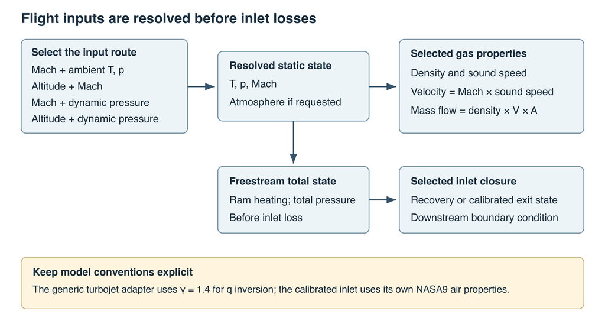

Flight-state resolution and inlet bookkeeping

## 4.10 Reading a resolved result

A useful flight-state report identifies the input route, the resolved static state, the property convention, and the inlet closure. An altitude label alone omits the atmospheric assumption. A Mach label alone omits the speed of sound. A pressure label without its static or total qualification omits the energy-state definition.

Before comparing two runs, reconstruct those definitions. The most informative discrepancies are often structural: a standard-temperature substitution, a recovery applied to the wrong pressure, a capture area changed between cases, or a different sound-speed convention. These can alter a comparison even when both numerical solutions have converged accurately.

The chapter’s equations provide a short route from independent inputs to interpretable inlet conditions. They also identify what remains outside the result: weather prediction, installation drag, spillage, internal shock layout and general inlet operability. Later engine chapters build on the resolved state and add only the component closures supported by their particular models.

# 5. Frozen mixtures and property polynomials

A fixed composition does not imply a fixed heat capacity. A stream can retain the same species proportions while its molecular energy storage changes strongly with temperature. Frozen thermodynamics describes that situation: the composition is prescribed, while enthalpy, heat capacities, entropy, density and sound speed are evaluated at the requested state.

The distinction matters in propulsion because temperature changes can be large. A single heat-capacity ratio may offer a useful simplified cycle, but a more detailed temperature calculation requires integrated property relations. Replacing a constant gamma with a local value in every familiar power law does not perform those integrations.

This chapter develops the property model used by the frozen-gas calculation and shared by several flowpath models. It explains composition normalization, polynomial evaluation, reference energies, entropy of mixing and temperature inversion. Chemical equilibrium changes the composition and is treated in Chapter 6. Finite-rate chemistry changes composition over a specified time or distance and is treated in Chapters 7–8 and 29.

## 5.1 Specifying composition without specifying batch size

Let $n_i$ be an amount of species $i$, $W_i$ its molecular weight in kg/kmol, and $n=\sum_i n_i$. The mole fraction is

$$x_i=\frac{n_i}{n},\qquad \sum_i x_i=1.$$

All amounts must use a common basis. Their absolute scale is irrelevant to an intensive property calculation: amounts 79 and 21 describe the same mixture as 0.79 and 0.21. The App accepts nonnegative relative molar amounts, merges repeated entries for the same recognized species, and normalizes their sum. At least one amount must be positive. Negative amounts and unknown species do not define an admissible mixture.

The mixture molecular weight follows from total mass divided by total molar amount:

$$\overline W=\frac{\sum_i n_iW_i}{\sum_i n_i}=\sum_i x_iW_i.$$

The mass fraction is therefore

$$Y_i=\frac{n_iW_i}{\sum_jn_jW_j}=\frac{x_iW_i}{\overline W}.$$

Conversely, supplied mass fractions imply

$$x_i=\frac{Y_i/W_i}{\sum_jY_j/W_j},\qquad
\overline W=\left(\sum_i\frac{Y_i}{W_i}\right)^{-1}.$$

These transformations explain why mass percentages cannot be entered unchanged in a molar-composition field. The error becomes especially large when light hydrogen is mixed with heavier species. Normalization only makes the entries sum to one; it cannot determine that the wrong physical basis was supplied.

A species with exactly zero amount makes no thermodynamic contribution. In the current property calculation, recognized zero-amount entries are omitted after normalization, including from the active temperature-range intersection. An unknown species name is still rejected even if its entered amount is zero. This separates a valid absent component from an unrecognized component definition.

## 5.2 Molar and mass-specific quantities

Use an overbar for a molar quantity, such as $\overline h_i$ in J/kmol. Unbarred $h$ denotes J/kg. The universal gas constant in the App is

$$R_u=8314.46261815324\ \mathrm{J\,kmol^{-1}K^{-1}}.$$

The mixture mass-specific gas constant is

$$R=\frac{R_u}{\overline W}.$$

For an ideal mixture with frozen composition,

$$\overline c_p=\sum_i x_i\overline c_{p,i},\qquad
\overline h=\sum_i x_i\overline h_i,$$

$$c_p=\frac{\overline c_p}{\overline W}=\sum_iY_ic_{p,i},\qquad
h=\frac{\overline h}{\overline W}=\sum_iY_ih_i.$$

Either molar or mass-weighted expressions are valid when the weights and property units match. A mole-weighted sum of species values already expressed in J/kg generally gives the wrong mixture value.

The ideal-gas relation is $p=\rho RT$. Since $h=u+RT$ and composition is fixed,

$$c_v=c_p-R,\qquad \gamma=\frac{c_p}{c_v},\qquad
\rho=\frac{p}{RT},\qquad a_f=\sqrt{\gamma RT}.$$

The subscript on $a_f$ identifies frozen sound speed. The thermal response used in this derivative holds species proportions fixed. An equilibrium acoustic response can include composition changes and need not equal the frozen response. Likewise, the heat capacity of an equilibrium path is not obtained merely by evaluating frozen heat capacities at its current composition: the changing species amounts also contribute to the energy derivative.

Within this ideal frozen model, pressure changes density and entropy but does not change enthalpy or heat capacity at a fixed temperature. Real-gas pressure dependence, liquid phases and condensation are outside the property calculation.

## 5.3 NASA9: one heat-capacity fit and two integration constants

A property record consists of a temperature interval, a reference pressure and polynomial coefficients. The NASA9 representation can be written with coefficients $a_1,\ldots,a_9$:

$$\frac{\overline c_p^{\circ}(T)}{R_u}=
a_1T^{-2}+a_2T^{-1}+a_3+a_4T+a_5T^2+a_6T^3+a_7T^4.$$

The superscript circle denotes the species standard-state function. Temperature is in kelvin; the coefficient units are those required by this expression. Changing the input temperature unit without changing the coefficients destroys the fit.

Enthalpy follows from $d\overline h/dT=\overline c_p$. Integrating each term gives

$$\frac{\overline h^{\circ}(T)}{R_u}=
-\frac{a_1}{T}+a_2\ln T+a_3T+\frac{a_4T^2}{2}
+\frac{a_5T^3}{3}+\frac{a_6T^4}{4}+\frac{a_7T^5}{5}+a_8.$$

Equivalently,

$$\frac{\overline h^{\circ}(T)}{R_uT}=
-\frac{a_1}{T^2}+\frac{a_2\ln T}{T}+a_3+\frac{a_4T}{2}
+\frac{a_5T^2}{3}+\frac{a_6T^3}{4}+\frac{a_7T^4}{5}+\frac{a_8}{T}.$$

At fixed reference pressure, $d\overline s^{\circ}/dT=\overline c_p^{\circ}/T$. Integrating once more yields

$$\frac{\overline s^{\circ}(T)}{R_u}=
-\frac{a_1}{2T^2}-\frac{a_2}{T}+a_3\ln T+a_4T
+\frac{a_5T^2}{2}+\frac{a_6T^3}{3}+\frac{a_7T^4}{4}+a_9.$$

The logarithms use the temperature convention of the fitted coefficients. The integration constants carry the selected enthalpy and entropy references. They are not optional numerical decorations. Deleting $a_8$ preserves the derivative $d\overline h/dT$ while changing chemical energy differences; deleting $a_9$ preserves the entropy derivative while changing chemical potentials.

The representation contains nine coefficients because seven terms describe heat capacity and two constants establish the integrated reference states. It does not mean that heat capacity is a ninth-degree polynomial. The inverse powers and logarithms are essential parts of the representation.

Each interval has its own complete coefficient set. The current NASA9 records use a lower interval from 200 to 1000 K and an upper interval from 1000 to 6000 K; the upper set is selected at exactly 1000 K. Coefficient changes approximate the same species functions across a broad range. Small fit inconsistencies at a join should not be interpreted as a phase transition, nor should a polynomial be extended past its recorded upper limit simply because it still returns a number.

## 5.4 NASA7 and database consistency

The hydrogen–oxygen mechanism uses NASA7 records. With coefficients $b_1,\ldots,b_7$, its heat capacity is

$$\frac{\overline c_p^{\circ}}{R_u}=b_1+b_2T+b_3T^2+b_4T^3+b_5T^4.$$

The integrated functions are

$$\frac{\overline h^{\circ}}{R_uT}=b_1+\frac{b_2T}{2}+\frac{b_3T^2}{3}
+\frac{b_4T^3}{4}+\frac{b_5T^4}{5}+\frac{b_6}{T},$$

$$\frac{\overline s^{\circ}}{R_u}=b_1\ln T+b_2T+\frac{b_3T^2}{2}
+\frac{b_4T^3}{3}+\frac{b_5T^4}{4}+b_7.$$

The App evaluates these through the same algebraic representation by placing two zero coefficients before the seven NASA7 coefficients. This is an exact embedding of the NASA7 functional form, not a refit and not a conversion to a different physical dataset.

| Property set | Included species | Recorded pressure reference | Temperature qualifications |
| --- | --- | --- | --- |
| General NASA9 set | Ar, CH4, CO, CO2, H, H2, H2O, N, N2, NO, O, O2, OH | 100,000 Pa | 200–6000 K for the included records |
| Hydrogen–oxygen NASA7 set | Ar, H, H2, H2O, H2O2, HO2, N2, O, O2, OH | 101,325 Pa | Reactive species: 200–3500 K; Ar and N2: 300–5000 K |

A database choice changes more than the number of coefficients. It changes the available species, fitted functions, reference conventions and valid intervals. The standalone frozen-property mode uses the general NASA9 set. The NASA7 set is associated with the supported hydrogen–oxygen mechanism where selected; it is not an arbitrary replacement for every model’s property data. In particular, calibrated inlet/engine calculations require their NASA9 convention.

No single common range covers every imaginable mixture. For an actual set of active species, the usable interval is

$$T_{\min}=\max_iT_{\min,i},\qquad
T_{\max}=\min_iT_{\max,i}.$$

For example, an active NASA7 mixture of H2, O2 and N2 is restricted to 300–3500 K. Pure H2 in that database has a 200 K lower boundary; adding positive N2 narrows it to 300 K. A later reacting calculation may need species that were absent initially, so its admissible domain must account for its own species requirements. An initial-mixture property range alone does not guarantee that an entire reactive trajectory is supported.

## 5.5 Ideal mixing entropy and the pressure term

For ideal gases, each species contributes entropy at its partial pressure $p_i=x_ip$:

$$\overline s(T,p,\boldsymbol{x})=
\sum_i x_i\left[\overline s_i^{\circ}(T)
-R_u\ln\left(\frac{x_ip}{p_i^{\circ}}\right)\right].$$

The reference pressure $p_i^{\circ}$ must match the species record. When every record shares one reference pressure $p^{\circ}$, this separates into

$$\overline s=\sum_i x_i\overline s_i^{\circ}(T)
-R_u\sum_i x_i\ln x_i-R_u\ln(p/p^{\circ}).$$

The middle term is the ideal entropy of mixing. It is nonnegative because every nonzero mole fraction is at most one. The last term represents the pressure effect: isothermal compression reduces entropy. The mass-specific value is $s=\overline s/\overline W$.

For fixed composition between two states,

$$s_2-s_1=\int_{T_1}^{T_2}\frac{c_p(T)}{T}\,dT
-R\ln\frac{p_2}{p_1}.$$

The mixing term cancels because composition is unchanged. It must remain when comparing different compositions, such as in a mixing or equilibrium calculation. Removing it because it cancels along one frozen path would corrupt those other problems.

A zero mole fraction contributes the limiting value $x\ln x\to0$. The implementation omits zero components and splits the logarithm into $\ln x_i+\ln(p/p_i^{\circ})$ for active species. This avoids forming a tiny partial-pressure product that could underflow before taking a logarithm. It does not remove the physical mixing term or turn a trace species into a finite concentration floor.

Changing the reference pressure also requires changing the standard-state entropy convention if the physical entropy is to stay unchanged. Retaining the old entropy coefficients while substituting a new pressure reference shifts the result. This is why the difference between 1 bar and 1 atmosphere belongs in the property definition, even when its numerical effect seems modest.

## 5.6 Formation enthalpy and sensible heating

A species enthalpy can be expressed schematically as

$$\overline h_i(T)=\Delta_f\overline h_i^{\circ}(T_r)
+\int_{T_r}^{T}\overline c_{p,i}(\vartheta)\,d\vartheta,$$

with the reference temperature and elemental conventions consistent with the dataset. The polynomial integration constant carries that reference information. Species with negative formation enthalpy can have negative enthalpy over part of the supported range. Negative enthalpy is not negative temperature and does not itself make the state invalid.

For a frozen stream of unchanged composition, the reference contribution cancels from $h_2-h_1$. This is why a constant-cp approximation can sometimes reproduce a temperature rise even when it uses a different zero of enthalpy. In a reacting stream, however, species amounts change. The difference between product and reactant formation terms is then part of the energy balance.

If the energy equation already uses formation-inclusive species enthalpies, adding a fuel heating value as a second chemical-energy source counts reaction energy twice. A heating-value cycle and a formation-enthalpy chemistry calculation are different accounting formulations. Each can be meaningful, but their terms cannot be combined casually.

Similarly, a supplied total enthalpy

$$h_t=h(T,\boldsymbol{x})+\frac{V^2}{2}$$

uses the same enthalpy reference as the property model. A numerical value previously formed as $c_pT+V^2/2$ is not automatically transferable. The reference offset affects an absolute target even when it has no effect on a frozen temperature difference. This point is particularly important for the state-reconstruction modes developed in Chapter 26.

## 5.7 Inverting an enthalpy or entropy target

The direct property problem supplies temperature and pressure. The enthalpy inversion instead supplies composition, pressure and a mass-specific enthalpy target, and seeks temperature from

$$f(T)=h(T,\boldsymbol{x})-h_{\mathrm{target}}=0.$$

For an admissible frozen ideal gas, $dh/dT=c_p>0$. Enthalpy is therefore increasing within the supported fit intervals. The App brackets the calculation by the common temperature range, evaluates its endpoint enthalpies, and rejects a target outside them. It then uses bounded bisection to locate the temperature. Its finite iteration count is a numerical procedure, not a statement that the fitted thermodynamic data have that many digits of physical accuracy.

Pressure remains a required positive input for the reported state, even though ideal-gas enthalpy at fixed composition does not depend on it. A pressure change should affect the returned density and entropy, not the temperature recovered from a fixed enthalpy target.

The shared property layer also supports entropy inversion at a supplied pressure. The derivative $(\partial s/\partial T)_p=c_p/T$ is positive over an admissible positive-temperature range, so the same bracketing reasoning applies. Unlike enthalpy inversion, changing the specified pressure generally changes the temperature required to recover the same entropy.

A target outside the bracket does not authorize extrapolation. It may indicate an incorrect unit, an incompatible enthalpy reference, or a real physical state outside the available data. These cases have different engineering meanings, even if all produce a refusal to return an extrapolated temperature.

## 5.8 Worked composition and entropy example

Consider 79 relative molar units of N2 and 21 of O2 in the general database. Their molecular weights are 28.0134 and 31.9988 kg/kmol. Normalization gives $x_{N2}=0.79$ and $x_{O2}=0.21$, followed by

$$\overline W=0.79(28.0134)+0.21(31.9988)=28.850334\ \mathrm{kg/kmol}.$$

The mass fractions and gas constant are

$$\begin{gathered}
Y_{N2}=0.76708249,\\
Y_{O2}=0.23291751,\\
R=288.19294\ \mathrm{J\,kg^{-1}K^{-1}}.
\end{gathered}$$

Thus 21% oxygen by moles corresponds to approximately 23.29% by mass. The gas constant differs from the standard-atmosphere value in Chapter 4 because this explicit binary mixture has a different molecular-weight definition. The difference should be retained when moving between these models.

The ideal mixing contribution is

$$s_{\mathrm{mix}}=-R[0.79\ln0.79+0.21\ln0.21]
=148.1187\ \mathrm{J\,kg^{-1}K^{-1}}.$$

This is the mixing contribution, not the complete entropy of the gas. The species standard-state entropies and the pressure term are still required for the complete value.

If pressure is doubled at unchanged temperature and composition,

$$\Delta s=-R\ln2=-199.7601\ \mathrm{J\,kg^{-1}K^{-1}}.$$

Density doubles, while enthalpy, heat capacities and frozen sound speed remain unchanged. This contrasting case separates the ideal pressure effect from temperature and composition effects without requiring a second polynomial evaluation.

## 5.9 Worked property and inverse example

Argon provides a transparent example in the lower NASA9 interval. Its recorded coefficients reduce to $\overline c_p/R_u=2.5$, and the enthalpy integration constant gives

$$R=208.1321372\ \mathrm{J\,kg^{-1}K^{-1}},\quad
c_p=520.3303431\ \mathrm{J\,kg^{-1}K^{-1}},$$

$$h=c_p(T-298.15\ \mathrm{K}),\qquad \gamma=5/3.$$

At 600 K and 150 kPa the direct calculation yields

| Quantity | Illustrative value |
| --- | --- |
| Enthalpy | 157.061714 kJ/kg |
| Constant-volume heat capacity | 312.198206 J/(kg K) |
| Density | 1.201160 kg/m³ |
| Frozen sound speed | 456.215012 m/s |

For the inverse calculation, supply $h=157061.714\ \mathrm{J/kg}$, the same pure composition and a positive pressure. The analytical lower-interval inverse is

$$T=298.15+\frac{h}{520.3303431}\approx600\ \mathrm{K}.$$

The App uses its general bracketed property inversion rather than an argon-specific shortcut. The simple analytical result makes the unit and reference convention visible: entering 157.061714 as J/kg would describe a state close to the enthalpy reference temperature, not 600 K.

Heating this gas from 600 to 900 K requires an enthalpy rise of approximately 156.099103 kJ/kg. Isentropically doubling its pressure from the 600 K state instead gives

$$c_p\ln(T_2/600)=R\ln2,\qquad
T_2=600\,2^{0.4}=791.704746\ \mathrm{K}.$$

Both calculations remain within the lower interval, where the constant-cp reduction is exact for the recorded fit. That reduction must not be generalized to every species or temperature interval. A variable-cp mixture requires the integrated functions developed above.

## 5.10 From a property result to a flow model

The standalone **Frozen Composition · Variable-Specific-Heat Properties** mode evaluates the prescribed composition directly or recovers temperature from its enthalpy target. Its returned molecular weight, gas constant, heat capacities, gamma, enthalpy, entropy, density and sound speed describe one thermodynamic state. It does not predict whether the mixture would react, how fast it would react, or which composition would be in equilibrium.

A frozen nozzle adds mass continuity, total-enthalpy conservation and an entropy or loss condition. A frozen component adds a particular efficiency or pressure closure. A reacting flowpath instead updates species amounts while maintaining its energy and momentum conventions. The property model supplies constitutive values to those equations; it does not supply the missing component closure.

When reading a result, retain the composition basis, database, reference pressure, enthalpy convention and supported temperature interval alongside the displayed temperature and pressure. Those definitions allow the number to be reused correctly. The later thermochemistry and flowpath chapters rely on this same distinction between a local property evaluation and the physical process that connects two states.

# 6. Gas-phase equilibrium

A chemical-equilibrium calculation determines a composition compatible with a specified thermodynamic constraint and a conserved elemental inventory. It does not merely balance one reaction equation. It compares all admissible compositions within the selected species set and finds the state with no remaining thermodynamic tendency to change along an allowed reaction direction.

ThrustOne provides two related problems. The temperature–pressure mode fixes temperature and pressure, then determines composition. The constant-pressure energy mode fixes pressure and the incoming enthalpy plus supplied heat, then determines both temperature and composition. Their common chemical model is an ideal gas with a bounded set of 13 species. A converged result is equilibrium within that set; it does not establish that the set contains every important real species or phase.

Chapter 5 developed the formation-inclusive enthalpy and ideal mixing entropy used here. This chapter adds elemental constraints, chemical potentials and the energy closure. Reaction rates and residence times enter later chapters, not this equilibrium calculation.

## 6.1 The inventory that reactions cannot change

Let $n_i$ be the amount of species $i$, and let $A_{ki}$ count atoms of element $k$ in one molecule of that species. The elemental inventory is

$$b_k=\sum_iA_{ki}n_i,\qquad \boldsymbol A\boldsymbol n=\boldsymbol b.$$

For example, using columns H2, O2, H2O, H, O and OH gives

$$\begin{gathered}
\boldsymbol A=
\begin{bmatrix}
2&0&2&1&0&1\\
0&2&1&0&1&1
\end{bmatrix},
\end{gathered}$$

where the rows are hydrogen and oxygen. An initial amount of 1.2 H2 and 0.7 O2 contains 2.4 hydrogen atom units and 1.4 oxygen atom units. Any admissible equilibrium composition must retain both quantities, regardless of how much water, atomic gas or hydroxyl it contains.

Molecular amount need not be conserved. Dissociating one molecule into two changes total molecular count without changing the elemental inventory or total mass. Consequently, equilibrium mole fractions must be formed from the final total amount $N=\sum_i n_i$, not from the initial total.

The App derives inventory from the declared initial species. It then admits database species whose constituent elements all have positive inventories. Supplying hydrogen and oxygen does not authorize production of a nitrogen species; nitrogen is absent from that problem. Conversely, a species need not be present initially to appear among the products when its elements are available.

At fixed temperature and pressure, two initial mixtures with the same elemental inventory define the same equilibrium problem. Their chemical preparation history is not an additional constraint. In the energy-closure mode, their incoming enthalpies may differ, so identical inventories alone do not guarantee identical final states.

## 6.2 What is minimized at fixed temperature and pressure

For a homogeneous ideal gas mixture, the total Gibbs energy is

$$G=\sum_i n_i\mu_i,$$

where the chemical potential $\mu_i$ is the partial molar Gibbs energy. With a common standard pressure $p^{\circ}$,

$$\mu_i(T,p,\boldsymbol x)=\overline g_i^{\circ}(T)
+R_uT\ln\left(x_i\frac{p}{p^{\circ}}\right),
\qquad \overline g_i^{\circ}=\overline h_i^{\circ}-T\overline s_i^{\circ}.$$

The logarithmic term includes both mixing and pressure. It follows directly from the ideal entropy expression in Chapter 5. Omitting mixing entropy removes the $\ln x_i$ contribution and changes the composition selected by the calculation.

At fixed $T$, $p$ and elemental inventory, equilibrium minimizes $G$ over nonnegative species amounts. The imposed temperature implies that heat can be exchanged as needed to maintain that temperature. A TP equilibrium result therefore does not, by itself, predict the temperature of an adiabatic combustor.

For the ideal mixture, the composition-dependent Hessian has quadratic form

$$\delta\boldsymbol n^T\nabla^2G\,\delta\boldsymbol n
=R_uT\left[\sum_i\frac{(\delta n_i)^2}{n_i}
-\frac{(\sum_i\delta n_i)^2}{N}\right]\geq0.$$

The inequality follows from the weighted Cauchy–Schwarz inequality. It expresses the convex character of the ideal-mixture problem within its positive domain. The scale direction must still be constrained by inventory; a freely scalable amount is not an independent physical equilibrium branch. This thermodynamic structure is useful, but it does not make finite-precision iteration infallible or make a restricted species set complete.

## 6.3 Reaction directions and dimensionless equilibrium constants

A reaction direction $\boldsymbol\nu$ changes composition through an extent $\xi$:

$$\boldsymbol n=\boldsymbol n^{(0)}+\boldsymbol\nu\xi.$$

Take products as positive and reactants as negative. Element conservation requires $\boldsymbol A\boldsymbol\nu=0$. For an interior equilibrium, differentiation at fixed temperature and pressure gives

$$\frac{dG}{d\xi}=\sum_i\nu_i\mu_i=0.$$

Dividing by $R_uT$ and inserting the chemical potentials yields

$$\sum_i\nu_i\frac{\overline g_i^{\circ}}{R_uT}
+\ln\prod_i\left(x_i\frac{p}{p^{\circ}}\right)^{\nu_i}=0.$$

Define the dimensionless reaction quotient and equilibrium constant by

$$Q_p=\prod_i\left(x_i\frac{p}{p^{\circ}}\right)^{\nu_i},\qquad
K_p(T)=\exp\left[-\sum_i\nu_i\frac{\overline g_i^{\circ}(T)}{R_uT}\right].$$

Then equilibrium requires $Q_p=K_p$. A pressure ratio is essential inside this definition. Substituting a numerical pressure in pascals into a formula whose constant assumes atmospheres changes the result whenever $\Delta\nu=\sum_i\nu_i\ne0$.

For a fixed reaction definition, $K_p$ depends on temperature through the standard-state functions. Pressure still affects composition through $Q_p$, even though it does not change $K_p(T)$. At fixed temperature, increasing pressure generally opposes dissociation reactions that increase molecular count. This is a consequence of the pressure exponent, rather than an extra empirical rule imposed on the solver.

The App retains reaction directions to evaluate chemical stationarity after solving for element potentials. Those directions are thermodynamic constraints, not a kinetic mechanism. Redundant directions can check the same equilibrium from different stoichiometric combinations without describing additional reaction rates.

## 6.4 Positivity, bounds and trace species

For a single reaction, nonnegative species amounts bound its extent:

$$\xi\geq\max_{\nu_i>0}\left(-\frac{n_i^{(0)}}{\nu_i}\right),\qquad
\xi\leq\min_{\nu_i<0}\left(-\frac{n_i^{(0)}}{\nu_i}\right).$$

These inequalities prevent consuming more reactant than is available. In a multireaction system, the feasible set is the intersection of all elemental and nonnegativity constraints; independently pushing each reaction to completion does not generally locate the coupled equilibrium.

Trace species matter because chemical potentials depend on logarithms. A small mole fraction can contribute a large negative $\ln x_i$, even while contributing negligibly to bulk molecular weight. Rounding such a value to zero before evaluating chemical affinity can therefore destroy an otherwise balanced equilibrium calculation.

This does not mean every imaginable species must have a positive amount. Species requiring absent elements are excluded first. For the active ideal-gas species set, the numerical method represents positive trace amounts and rejects a solution if necessary amounts fall below its representable range. A printed value that rounds to zero is also different from a mathematically exact zero; reports should preserve sufficient notation to distinguish them.

The general reaction-coordinate routine in the code uses bounded reaction extents and logarithmic endpoint interpolation. The current 13-species gas mode instead uses a coupled element-potential solver. These are different numerical routes to the same ideal equilibrium conditions; the existence of the general routine should not be mistaken for the algorithm driving every gas-equilibrium result.

## 6.5 Element potentials reduce the coupled problem

Introduce one Lagrange multiplier $\lambda_k$ for each active element and minimize

$$\mathcal L=G-\sum_k\lambda_k\left(\sum_iA_{ki}n_i-b_k\right).$$

Stationarity with respect to an active species amount gives

$$\mu_i=\sum_kA_{ki}\lambda_k.$$

Writing $\ell_k=\lambda_k/(R_uT)$ and $g_i^{\circ}=\overline g_i^{\circ}/(R_uT)$, the species mole fractions satisfy

$$\ln x_i=\sum_kA_{ki}\ell_k-g_i^{\circ}-\ln(p/p^{\circ}).$$

The unknowns are the element potentials plus total molecular amount. They are determined by

$$N\sum_iA_{ki}x_i=b_k\quad\text{for each element},\qquad
\sum_i x_i=1.$$

This formulation handles species amounts spanning many orders of magnitude without repeatedly subtracting almost exhausted reactant inventories. The implementation normalizes the initial total amount for conditioning, uses logarithmic elemental balances and normalization, and restores the amount scale in the result. It evaluates sums of exponentials with a shifted logarithmic sum to limit overflow and underflow.

Newton-like corrections solve the coupled residual equations. Damping and shorter trial steps are used when an unrestricted step does not reduce the residual. These are numerical safeguards, not combustion efficiencies. The solver has a finite iteration budget and refuses a nonconverged composition rather than returning its last iterate as equilibrium.

Multiplying all initial amounts by a common positive factor leaves the equilibrium mole fractions unchanged, while scaling all final amounts and elemental inventories by the same factor. This scale invariance is a useful interpretation of relative molar inputs. It does not imply that pressure, temperature or the elemental ratios can be rescaled without changing composition.

## 6.6 What the residuals actually say

Three separate conditions are needed to interpret a computed composition:

| Condition | Meaning | What it does not establish |
| --- | --- | --- |
| Element conservation | The final atoms match the initial inventory | Chemical equilibrium |
| Mole-fraction normalization and positivity | The mixture is a valid composition | Correct thermodynamic data |
| Chemical stationarity | Allowed reaction directions have negligible Gibbs derivative | Completeness of the species or phase model |

The displayed equilibrium residual is the largest absolute dimensionless chemical-potential sum over the active checking directions,

$$r_{\mathrm{eq}}=\max_r\left|\sum_i\nu_{ir}\frac{\mu_i}{R_uT}\right|.$$

For one direction this is $|\ln(Q_p/K_p)|$. Its scale depends on the chosen stoichiometric coefficients: doubling every coefficient doubles this residual even though the equilibrium composition is unchanged. A small residual is therefore a numerical consistency statement for the defined model, not a universal percentage error in every species amount.

The present gas mode requires this affinity residual below $10^{-8}$ and separately checks each positive elemental inventory to a relative tolerance of $10^{-8}$. Its internal logarithmic closure uses a tighter residual threshold. These tolerances describe acceptance of the numerical equations; they do not imply eight-digit accuracy for real combustion products or property measurements.

An iteration count measures solver work. It is not a reaction time. More iterations do not imply slower chemistry, and a rapidly converged equilibrium does not imply that a flowing combustor has enough residence time to attain it.

## 6.7 Worked dissociation example with an explicit model boundary

To expose the pressure and extent algebra, consider a hypothetical two-species gas with the single reaction

$$A_2\rightleftharpoons2A.$$

Assume one initial molar unit of $A_2$, no inert gas, and an illustrative dimensionless $K_p=0.16$ at a fixed temperature. This is an analytical teaching model, not a fitted hydrogen or oxygen equilibrium and not a replacement for the App’s 13-species result.

Let $\alpha$ be the fraction dissociated. Then

$$n_{A_2}=1-\alpha,\quad n_A=2\alpha,\quad N=1+\alpha,$$

$$x_{A_2}=\frac{1-\alpha}{1+\alpha},\qquad
x_A=\frac{2\alpha}{1+\alpha}.$$

The elemental inventory is $2n_{A_2}+n_A=2$, independently of $\alpha$. The reaction quotient is

$$Q_p=\frac{x_A^2}{x_{A_2}}\frac{p}{p^{\circ}}
=\frac{4\alpha^2}{1-\alpha^2}\frac{p}{p^{\circ}}.$$

Solving $Q_p=K_p$ gives the physical nonnegative root

$$\alpha=\sqrt{\frac{K_p}{4p/p^{\circ}+K_p}}.$$

At $p=p^{\circ}$, $\alpha=0.1961161$, while $x_A=0.3279216$. The dissociation fraction and atomic mole fraction are different because dissociation changes total molecular count. Substituting the result back into the quotient gives 0.16, and the atom balance remains exactly two units analytically.

| Pressure ratio | Dissociation fraction $\alpha$ | Atomic mole fraction $x_A$ |
| --- | --- | --- |
| 0.25 | 0.3713907 | 0.5416264 |
| 1 | 0.1961161 | 0.3279216 |
| 4 | 0.0995037 | 0.1809975 |

The pressure trend follows with no temperature change: lower pressure favors the side with more molecules. Adding an inert gas at fixed total pressure would change the partial pressures and this algebra. Holding volume instead of pressure would define a different problem. Neither alteration can be represented by reusing the table unchanged.

## 6.8 From specified temperature to an energy closure

An adiabatic combustion temperature is unknown. For a constant-pressure process with no shaft work and negligible kinetic and potential energy changes, the mass-specific energy balance is

$$h_{\mathrm{eq}}(T,p,\boldsymbol b)=h_{\mathrm{in}}+q,$$

where $q$ is supplied heat per unit incoming mixture mass. Positive $q$ adds energy. All species enthalpies use the formation-inclusive convention from Chapter 5.

The App’s HP mode obtains $h_{\mathrm{in}}$ from the declared gaseous mixture at one common inlet temperature. At each trial product temperature, it solves TP equilibrium afresh and evaluates the enthalpy of that equilibrium composition. The outer root function is

$$f(T)=h_{\mathrm{eq}}(T,p,\boldsymbol b)-h_{\mathrm{in}}-q.$$

Thus an HP calculation contains two coupled levels: chemical closure at a trial temperature, and energy closure across temperatures. Evaluating the original frozen composition at every trial temperature would solve a different, nonreacting heating problem.

The declared lower and upper temperatures must bracket the enthalpy target. Both endpoint chemical calculations must succeed. A failed intermediate equilibrium is reported as an energy-root evaluation failure; it is not skipped to construct an apparently smooth enthalpy curve through missing states. The current outer calculation uses bounded bisection and requires an enthalpy residual within the larger of 0.01 J/kg and $10^{-9}|h_{\mathrm{target}}|$.

With $q=0$, the calculation is adiabatic gas-phase equilibrium. No extra heating value is added: reaction energy is already encoded in the species reference enthalpies. Liquid injection, vaporization enthalpy and separate inlet-stream temperatures are not implicit features of this standalone closure.

## 6.9 An energy-closure example that can be reconstructed exactly

Pure argon isolates the HP temperature closure without introducing a chemical-data comparison. Supply pure Ar at 450 K and 200 kPa, with $q=130000\ \mathrm{J/kg}$, and choose a product-temperature bracket of 500–800 K. In the included species set, an inventory containing only argon permits only argon, so its equilibrium mole fraction remains one.

Within this temperature interval, the lower NASA9 argon record gives

$$c_p=520.3303431\ \mathrm{J\,kg^{-1}K^{-1}},\qquad
h=c_p(T-298.15\ \mathrm{K}).$$

The incoming enthalpy and target are

$$h_{\mathrm{in}}=79012.1626\ \mathrm{J/kg},\qquad
h_{\mathrm{target}}=209012.1626\ \mathrm{J/kg}.$$

The bracket endpoint enthalpies are approximately 105028.6798 and 261127.7827 J/kg, so they enclose the target. The analytical root is

$$T=450+\frac{130000}{520.3303431}=699.841282\ \mathrm{K}.$$

This example demonstrates the same incoming-energy and temperature-bracket definitions used by the HP mode. It does not establish the accuracy of a reactive flame-temperature prediction. In a reacting mixture, dissociation and recombination change the equilibrium enthalpy curve, so replacing the curve with this constant-cp formula would be inappropriate.

The contrast with TP mode is immediate. Specifying pure argon at 699.841282 K and 200 kPa in TP mode reproduces the final composition and properties, but TP mode does not determine that 130 kJ/kg was required to reach it from 450 K. That conclusion uses the inlet state and energy balance.

## 6.10 Thermal response along equilibrium

The equilibrium mixture’s reported heat capacity is evaluated with its composition frozen at the returned state. If $Y_i^{\mathrm{eq}}$ varies with temperature, the total derivative of equilibrium enthalpy at fixed pressure is

$$\frac{dh_{\mathrm{eq}}}{dT}=
\sum_iY_i^{\mathrm{eq}}c_{p,i}
+\sum_i h_i\frac{dY_i^{\mathrm{eq}}}{dT}.$$

The first term is the frozen mixture heat capacity. The second term represents the energy effect of changing composition. It can be important in dissociation regions and cannot be reconstructed from the displayed frozen gamma alone.

Consequently, an equilibrium result can supply composition and local frozen properties to a downstream frozen nozzle, but a nozzle that remains in equilibrium must repeatedly update composition and enforce its own energy and entropy constraints. Chapter 17 distinguishes those paths. Neither is a finite-rate chemistry prediction merely because the composition differs from the inlet mixture.

## 6.11 Scope of the two App modes

The TP and HP gas-equilibrium modes use the general NASA9 set: Ar, CH4, CO, CO2, H, H2, H2O, N, N2, NO, O, O2 and OH. They contain no ions, condensed carbon, liquid water or general hydrocarbon species library. Temperature support is bounded by the records and the selected energy-root interval; numerical existence inside a polynomial range does not establish physical adequacy of the omitted-species assumptions.

A carbon-rich mixture can therefore produce a mathematically consistent gas-only result even where condensed carbon would matter in a broader model. A very hot state can likewise require ionization outside the current species set. These are model limitations, not residual failures. The reported conservation and affinity checks cannot detect physics that was never admitted to the calculation.

For a usable interpretation, retain the selected mode, pressure, inventory, species set, and either specified temperature or inlet enthalpy plus supplied heat. Read the equilibrium residual together with the energy residual when applicable. A converged state then has a precise meaning: it solves the declared ideal-gas chemical constraints, and, in HP mode, the declared energy balance. Whether a real engine approaches that state additionally depends on mixing, reaction rates, heat transfer and residence time.

# 7. Elementary and pressure-dependent rates

Equilibrium identifies a limiting composition; kinetics supplies the speed and direction of local chemical change. A finite-rate model starts from a reaction list, temperature and species concentrations. It returns production and consumption rates that a reactor or flow solver integrates over time or distance. The rate calculation alone does not determine temperature, residence time or the motion of the gas.

This chapter develops the mass-action and pressure-dependent expressions used by ThrustOne. The same rate evaluator supports the constant-temperature reactor and finite-rate flowpaths. Chapter 8 explains the reactor constraint, while Chapter 29 explains spatial transport through a reacting flowpath. Keeping those constraints separate from the reaction law makes a rate coefficient transferable only where its units, species definitions and thermodynamic references remain consistent.

## 7.1 Reaction progress and species production

Write reaction $r$ as

$$\sum_i\nu'_{ir}X_i\rightleftharpoons\sum_i\nu''_{ir}X_i,
\qquad \nu_{ir}=\nu''_{ir}-\nu'_{ir}.$$

Reactant and product coefficients are positive on their respective sides; the net coefficient is positive for net production. Let $q_r$ be the net volumetric rate of reaction progress in kmol/(m³ s). The production rate of species $i$ is

$$\dot\omega_i=\sum_r\nu_{ir}q_r.$$

The mass source is $W_i\dot\omega_i$, in kg/(m³ s). Reaction progress is therefore not the same quantity as the rate of disappearance of an arbitrary reactant: the latter includes that reactant’s stoichiometric coefficient and a sign.

For the illustrative reaction $\mathrm{H_2+O\rightarrow H+OH}$, one progress unit consumes one unit each of H2 and O and creates one each of H and OH. Hydrogen and oxygen atoms balance separately. Multiplying the net source vector by an element-count row gives zero, so a sum of balanced reactions preserves every element regardless of their instantaneous rates.

The App checks the declared reaction coefficients for element conservation before compiling the rates. It merges repeated terms of the same species on each side and rejects identical net sides. It requires recognized species and positive finite side coefficients. This protects the algebraic inventory; it does not establish that an entered reaction is an experimentally justified elementary step.

## 7.2 Concentration and reaction order

The concentration convention is

$$C_i=\frac{n_i}{V}\quad[\mathrm{kmol/m^3}],\qquad
C_{\mathrm{tot}}=\sum_i C_i=\frac{p}{R_uT}.$$

For an elementary mass-action reaction, the forward progress rate is

$$q_f=k_f(T)\prod_i C_i^{\nu'_i}.$$

The current implementation uses the entered reactant-side coefficients as reaction orders. It does not provide a separate arbitrary reaction-order field. A globally balanced combustion equation is not automatically an elementary rate law: choosing its stoichiometric coefficients as exponents is a modeling decision that requires kinetic support.

If the total forward order is $m=\sum_i\nu'_i$, the coefficient units are

$$[k_f]=(\mathrm{m^3/kmol})^{m-1}\mathrm{s^{-1}}.$$

A first-order coefficient has units $s^{-1}$; a second-order coefficient has units m³/(kmol s). The numerical coefficient changes when the concentration unit changes. For example, numerical concentrations in mol/cm³ are $10^{-3}$ times the corresponding numerical values in kmol/m³. Converting an $m$-order coefficient from a mol/cm³ convention to the App’s convention multiplies its numerical value by $10^{-3(m-1)}$. This follows by converting both the rate and every concentration factor, not by changing a unit label.

For a species with positive order, zero concentration makes that directional rate zero. The reverse rate may still be nonzero if products are present. A negative concentration is not an admissible extension of a fractional power; it is rejected before rate evaluation.

## 7.3 Modified Arrhenius temperature dependence

The supported temperature law is

$$k_f=A T^\beta\exp\left(-\frac{E_a}{R_uT}\right).$$

Temperature is in kelvin, $R_u$ is in J/(kmol K), and $E_a$ must be in J/kmol. An activation energy stated in J/mol must be multiplied by 1000 before it is paired with this value of $R_u$. The exponent must be dimensionless.

The pre-exponential factor has the coefficient units divided by K$^{\beta}$. Thus $A$ does not always have the same dimensions as a conventional first- or second-order rate coefficient. The App’s unit description includes this temperature-power factor.

Taking a logarithm gives

$$\ln k_f=\ln A+\beta\ln T-\frac{E_a}{R_uT},$$

and hence

$$\frac{d\ln k_f}{d\ln T}=\beta+\frac{E_a}{R_uT}.$$

This derivative explains why relatively small temperature changes can strongly affect rates. A fitted negative activation energy is also possible in this representation; it is not automatically an input error. The App requires finite Arrhenius parameters and a nonnegative pre-exponential factor. Whether a particular fit is appropriate over a proposed temperature interval is a separate question.

For two temperatures, a useful comparison is

$$\frac{k_f(T_2)}{k_f(T_1)}=
\left(\frac{T_2}{T_1}\right)^\beta
\exp\left[\frac{E_a}{R_u}\left(\frac{1}{T_1}-\frac{1}{T_2}\right)\right].$$

The factor $A$ cancels. This compares coefficients only: if concentrations change with temperature, the full rate changes by additional concentration factors. At fixed pressure, for example, total concentration decreases as temperature rises.

## 7.4 Reverse rates from thermodynamics

For a reversible mass-action step,

$$q=q_f-q_b=k_f\prod_iC_i^{\nu'_i}-k_b\prod_iC_i^{\nu''_i}.$$

At equilibrium the directional rates are equal. Therefore

$$\frac{k_f}{k_b}=K_c,qquad
K_c=\prod_i(C_i^{\mathrm{eq}})^{\nu_i}.$$

Here $K_c$ is the dimensional concentration quotient in the selected concentration units. Chapter 6’s $K_p$ is dimensionless. Since $p_i=C_iR_uT$, their relation is

$$K_c=K_p\left(\frac{p^{\circ}}{R_uT}\right)^{\Delta\nu},
\qquad \Delta\nu=\sum_i\nu_i.$$

The concentration factor has units kmol/m³. It supplies the dimensions needed when the forward and reverse orders differ. Setting $k_b=k_f/K_p$ without this conversion is correct only for the special case $\Delta\nu=0$ under these definitions.

The App obtains Gibbs functions from the selected thermodynamic database and forms

$$\ln K_c=-\sum_i\nu_i\frac{\overline g_i^{\circ}}{R_uT}
+\Delta\nu\ln\left(\frac{p^{\circ}}{R_uT}\right).$$

It evaluates the species Gibbs functions at a common 100,000 Pa state. The NASA7 records’ own reference pressure is handled inside the property calculation, so this operation includes the required entropy adjustment; it does not simply relabel their coefficient reference pressure. The reverse coefficient then uses the same effective forward coefficient divided by this thermodynamic $K_c$.

This construction enforces thermodynamic consistency for the included reversible steps. It does not prove the accuracy of their forward rates. Multiplying both directional coefficients by the same factor changes relaxation time while preserving their ratio and equilibrium composition.

Near equilibrium, two large directional rates may nearly cancel. The implementation evaluates logarithmic rates and uses an exponential-difference expression based on `expm1` to reduce cancellation error. An overflowing rate is rejected rather than interpreted as instantaneous completion. Numerical reformulation expands the range of reliable evaluation; it does not supply a missing stiff integration method.

## 7.5 Third-body collisions

Some reactions require a collision partner to remove or supply energy. A schematic recombination is

$$A+B+M\rightleftharpoons AB+M.$$

The collider appears unchanged in the net species balance, but its concentration affects the rate. Define

$$[M]_{\mathrm{eff}}=\sum_i\epsilon_iC_i,$$

where $\epsilon_i$ is the efficiency of species $i$ as a collider relative to the convention of the rate fit. The forward progress rate for a simple third-body step is

$$q_f=k_3(T)[M]_{\mathrm{eff}}\prod_iC_i^{\nu'_i}.$$

The collider adds one concentration power to the overall rate. Consequently, $[k_3]=(\mathrm{m^3/kmol})^m/\mathrm{s}$, before the Arrhenius temperature-power adjustment.

The App uses efficiency one for species not listed in an enabled third-body efficiency map. An explicit zero efficiency removes that species’ collider contribution; it does not remove the species from the mixture. An empty but present efficiency map therefore enables an all-unity collider term, whereas an absent map without falloff leaves an ordinary mass-action coefficient.

Do not add a fictitious database species named M. Collider effects are represented by the efficiency sum. Including a real species on both sides of a reaction introduces its concentration through the side exponents; additionally enabling a third-body term can then count an extra factor unless that is deliberately part of the supplied model.

## 7.6 Reduced pressure and Lindemann falloff

A falloff reaction transitions between low- and high-pressure rate laws. Let $k_0(T)$ be its low-pressure coefficient and $k_\infty(T)$ its high-pressure coefficient. Define the dimensionless reduced pressure

$$P_r=\frac{k_0[M]_{\mathrm{eff}}}{k_\infty}.$$

The basic Lindemann effective coefficient is

$$k_{\mathrm{eff}}=k_\infty\frac{P_r}{1+P_r}.$$

At $P_r\ll1$, $k_{\mathrm{eff}}\approx k_0[M]_{\mathrm{eff}}$. At $P_r\gg1$, it approaches $k_\infty$. The low-pressure coefficient therefore has one additional inverse-concentration unit compared with the high-pressure coefficient. Both have independently supplied Arrhenius parameters.

The main reaction parameters represent $k_\infty$ when falloff is enabled; the nested low-pressure parameters represent $k_0$. After forming $k_{\mathrm{eff}}$, the code multiplies by the explicit reactant concentration powers. It does not multiply by the collider sum a second time. The collider is already present through $P_r$.

Reduced pressure is not the physical pressure in pascals. Its value also depends on temperature, mixture efficiencies and the two rate fits. Two gases at the same pressure can occupy different positions on the falloff curve.

## 7.7 Troe broadening

Troe broadening modifies the transition shape through a factor $F$:

$$k_{\mathrm{eff}}=k_\infty\frac{P_r}{1+P_r}F.$$

The supported center expression is

$$F_{\mathrm{cent}}=(1-a)\exp(-T/T_3)+a\exp(-T/T_1)
+\exp(-T_2/T),$$

where the final term is omitted when $T_2$ is not supplied. The parameter $a$ lies between zero and one; the characteristic temperatures are positive. This $a$ is a fit parameter, unrelated to sound speed.

Using base-10 logarithms, define

$$\begin{gathered}
c=-0.4-0.67\log_{10}F_{\mathrm{cent}},\\
n=0.75-1.27\log_{10}F_{\mathrm{cent}},\\
u=\log_{10}P_r+c.
\end{gathered}$$

The broadening formula is

$$\log_{10}F=\frac{\log_{10}F_{\mathrm{cent}}}
{1+[u/(n-0.14u)]^2}.$$

The implementation evaluates an equivalent scaled form to avoid an unnecessary overflow when the ratio in the denominator becomes large. Its parameters and temperature convention must come from the same rate model as the low- and high-pressure coefficients. Supplying arbitrary valid positive temperatures merely creates a computable curve; it does not calibrate a physical reaction.

The Lindemann factor alone has simple asymptotes. With Troe enabled, the actual coefficient also includes its broadening expression over the fitted domain. Statements about a fitted curve should retain that qualifier rather than assuming that every parameter set behaves like an idealized sketch at unlimited pressure.

## 7.8 Worked elementary-rate calculation

Consider the balanced step H2 + O → H + OH with illustrative forward parameters

$$\begin{gathered}
A=2.0\times10^7\ \mathrm{m^3\,kmol^{-1}s^{-1}K^{-1/2}},\\
\beta=0.5,\\
E_a=6.0\times10^7\ \mathrm{J/kmol}.
\end{gathered}$$

These values are chosen for arithmetic demonstration, not as a recommended hydrogen mechanism. At 1000 K,

$$\begin{gathered}
k_f=2.0\times10^7\sqrt{1000}
\exp[-60000000/(8314.462618\times1000)]\\
=4.64529\times10^5\ \mathrm{m^3/(kmol\,s)}.
\end{gathered}$$

With $C_{H2}=0.002$ and $C_O=0.001\ \mathrm{kmol/m^3}$,

$$q_f=k_fC_{H2}C_O=0.929058\ \mathrm{kmol/(m^3s)}.$$

For an irreversible step, each reactant source is $-0.929058$ and each product source is $+0.929058$ in the same units. The hydrogen atom source is $2(-q_f)+q_f+q_f=0$, and the oxygen atom source is $-q_f+q_f=0$. Mass conservation follows when the molecular weights use consistent atomic masses.

Raising temperature to 1200 K while holding concentrations fixed multiplies the coefficient and forward rate by approximately 3.646925. Holding pressure and mole fractions fixed instead would also reduce both reactant concentrations by a factor 1000/1200, so the rate ratio would include that factor squared. A temperature-sensitivity statement must identify which quantities are held fixed.

If reversibility is enabled, the net source additionally requires product concentrations and the thermodynamic reverse coefficient. The forward number alone no longer equals the net progress rate.

## 7.9 Worked collider and falloff comparison

At a selected temperature, suppose a mixture has three collider contributions: 0.003 kmol/m³ with efficiency one, 0.001 kmol/m³ with efficiency two, and 0.002 kmol/m³ with efficiency zero. Then

$$[M]_{\mathrm{eff}}=0.003+2(0.001)+0(0.002)=0.005\ \mathrm{kmol/m^3}.$$

Its total concentration is 0.006 kmol/m³, so replacing the effective collider concentration by total concentration would change the modeled rate.

For an illustrative unimolecular falloff step, take evaluated coefficients $k_\infty=10^6\ \mathrm{s^{-1}}$ and $k_0=2\times10^8\ \mathrm{m^3/(kmol\,s)}$. The resulting reduced pressure is one, and the Lindemann coefficient is $5\times10^5\ \mathrm{s^{-1}}$. For reactant concentration 0.0002 kmol/m³, the forward progress rate is 100 kmol/(m³ s). This deliberately rapid example says nothing about whether an explicit time integrator can cover a requested duration economically.

For a Troe comparison at 1000 K, use illustrative $a=0.5$, $T_3=1000$ K, $T_1=10000$ K, and omit $T_2$. Then $F_{\mathrm{cent}}=0.63635843$, the supported broadening expression gives $F=0.65468982$ at $P_r=1$, and

$$k_{\mathrm{eff}}=327344.909\ \mathrm{s^{-1}}.$$

The forward rate becomes approximately 65.4690 kmol/(m³ s). The change arises from the explicitly selected broadening model. It should not be described as a new collision efficiency or applied again through another multiplier.

## 7.10 Model inputs, numerical limits and physical meaning

ThrustOne supports 1–50 declared reactions with elementary side-power mass action, reversible rates derived from the chosen thermodynamic data, optional third-body efficiencies, and Lindemann or Troe falloff. A zero main pre-exponential factor disables that reaction. When a collider-dependent coefficient has zero effective collider concentration, it contributes no progress rate. Unsupported or nonfinite rates are refused.

The included hydrogen–oxygen option contains 10 thermodynamic species and 29 reaction entries. It is a bounded mechanism option, not a general hydrocarbon mechanism loader or a complete reacting-flow simulation package. Its thermodynamic data use the NASA7 representation described in Chapter 5. The general demonstration H2 → 2 H with a unit first-order coefficient is an algorithm example and must not be interpreted as calibrated dissociation kinetics.

Rates computed here are local chemical source terms. They omit molecular diffusion, turbulent mixing, heat transfer and transport coefficients. A reaction may be thermodynamically favorable yet remain slow; it may be locally fast yet limited by mixing in a real combustor. Choosing a rate law, computing its source terms and resolving a complete engine are therefore distinct steps. The next chapter supplies one specific time-evolution constraint and explains how to read a completed or interrupted chemical history.

# 8. Reactor constraints and chemical timescales

A reaction mechanism does not determine a unique temperature or pressure history. Those histories depend on the physical constraints imposed on the reacting mixture. A rigid insulated vessel, a rigid temperature-controlled vessel and a constant-pressure combustor can use the same chemical rates and still produce different trajectories.

ThrustOne’s finite-rate reactor is homogeneous, closed to mass, constant in volume and externally maintained at a specified temperature. It integrates species concentrations and reconstructs pressure from their changing total. It does not integrate an adiabatic temperature rise. This chapter derives that model, explains its numerical stopping behavior, and explains the reported thermostat diagnostic. The energy balance must follow the stated rigid-vessel constraint; a constant-pressure heat load is a different quantity.

## 8.1 Choose the control boundary first

Take a rigid vessel of volume $V$, containing a spatially uniform ideal gas. No mass enters or leaves. Ignore bulk kinetic energy, potential energy, surface reactions and mechanical stirring work. Species can interconvert through the supplied reaction list, while an external thermal boundary maintains a constant temperature $T$.

With concentration $C_i=n_i/V$, the species equations are

$$\frac{dC_i}{dt}=\dot\omega_i(T,\boldsymbol C)
=\sum_r\nu_{ir}q_r(T,\boldsymbol C).$$

There is no dilution term because volume is fixed, and no inlet or outlet term because the vessel is closed. Chapter 7 supplies the local reaction-rate expressions. An open stirred reactor would require additional mass-exchange terms and a residence-time definition; it is not obtained merely by assigning a longer integration duration here.

A prescribed temperature removes the temperature differential equation from the solved system. The external heat exchange needed to enforce that prescription becomes a diagnostic. For an adiabatic vessel, temperature would instead be an unknown coupled to composition through internal-energy conservation. Those are different mathematical systems.

## 8.2 Initial pressure sets the concentration scale

Let the entered relative molar amounts be $a_i$, with normalized initial fractions $x_{i0}=a_i/\sum_j a_j$. The initial concentrations are

$$C_{i0}=x_{i0}\frac{p_0}{R_uT}.$$

Thus the relative amounts set composition, while initial pressure and temperature set absolute concentration. Multiplying every relative amount by ten does not increase the physical concentration. Increasing initial pressure at fixed temperature and composition does.

This distinction matters because reaction rates can depend on concentration to different powers. A second-order rate scales quadratically with a uniform concentration increase at an unchanged temperature, while a first-order rate scales linearly. Falloff and collider efficiencies add further dependencies described in Chapter 7.

The reactor does not need a numerical vessel volume to compute concentrations or pressure. Doubling the vessel volume at the same initial state doubles total mass and total heat-transfer rate, but leaves the concentration trajectory and heat-transfer rate per unit volume unchanged. Absolute equipment loads require a separately known volume.

## 8.3 Pressure can change at constant temperature

At every time,

$$p(t)=R_uT\sum_iC_i(t).$$

Differentiating at constant temperature gives

$$\frac{dp}{dt}=R_uT\sum_i\dot\omega_i
=R_uT\sum_r\Delta\nu_r q_r.$$

Reactions that increase molecular count can raise pressure even though temperature is fixed. Reactions that reduce molecular count can lower it. In a mechanism with several reactions, the net effect is the weighted sum of their progress rates.

Total mass density is different:

$$\rho=\sum_iW_iC_i,\qquad
\frac{d\rho}{dt}=\sum_iW_i\dot\omega_i=0$$

for balanced reactions and consistent molecular weights. Pressure change therefore does not imply a mass leak. At constant temperature and density, changing mean molecular weight changes the mixture gas constant and hence pressure.

The displayed mole fraction is

$$x_i(t)=\frac{C_i(t)}{\sum_jC_j(t)}.$$

Its variation reflects both the species concentration and the changing denominator. A mole fraction falling by half does not necessarily mean that half the original amount of that species remains. Use concentration or the analytical inventory relation when reasoning about conversion.

## 8.4 The thermostat energy balance

For a closed rigid vessel with no other work, the first law is

$$\frac{dU}{dt}=\dot Q.$$

Let positive $\dot Q$ mean heat added to the gas. Since

$$\frac{U}{V}=\sum_iC_i\overline u_i(T),$$

its derivative is

$$\frac{\dot Q}{V}=
\sum_i\overline u_i\dot\omega_i
+\left(\sum_iC_i\overline c_{v,i}\right)\frac{dT}{dt}.$$

For the isothermal constraint, $dT/dt=0$, so the required volumetric heat-transfer rate is

$$\dot q_V=\sum_i\overline u_i\dot\omega_i.$$

Formation-inclusive internal energies are required. An exothermic reaction at fixed temperature generally requires heat removal, giving a negative $\dot q_V$ under this convention. Endothermic dissociation can require positive heat input. No additional fuel heating-value term should be added to the species formation-energy accounting.

For an ideal gas, $\overline u_i=\overline h_i-R_uT$. Consequently,

$$\dot q_V=\sum_i\overline h_i\dot\omega_i
-R_uT\sum_i\dot\omega_i
=\sum_i\overline h_i\dot\omega_i-\frac{dp}{dt}.$$

Pressure per time and power per volume have the same dimensions: Pa/s equals W/m³. The correction is nonzero when the net molecular production rate is nonzero.

### Interpreting the App thermostat diagnostic

The result named `thermostat_heat_rate` reports the rigid-vessel heat-transfer rate per unit volume at the final returned state. Define the enthalpy-source sum

$$S_h=\sum_i\overline h_i\dot\omega_i.$$

The reported value is $S_h-R_uT\sum_i\dot\omega_i$, in W/m³. Positive values denote heat supplied to the mixture; negative values denote heat removal. It is an instantaneous final-state rate, not the time-integrated energy supplied during the calculation.

An enthalpy-source sum alone would omit the pressure-production term. That difference matters whenever the reaction changes total molecular amount, even though the vessel volume and temperature are fixed. The diagnostic does not feed back into the concentration integration: the external thermostat imposes temperature independently. Neither a small integration error nor a conserved mass would justify substituting a constant-pressure energy balance for the rigid-vessel balance.

## 8.5 What an adiabatic calculation would require

Setting heat exchange to zero in the first law gives

$$\frac{dT}{dt}=-\frac{\sum_i\overline u_i\dot\omega_i}
{\sum_iC_i\overline c_{v,i}}.$$

Temperature then changes the rates, and the changing rates alter composition and temperature again. This coupling can produce rapid thermal acceleration. It is not present in the externally isothermal reactor.

A constant-temperature species history can reveal kinetic conversion and pressure evolution under thermal control. It cannot show an adiabatic ignition-temperature rise, determine an adiabatic flame temperature or establish heat-release-driven thermal runaway. The HP equilibrium calculation in Chapter 6 solves a limiting energy-constrained state, while an adiabatic finite-rate history would require the coupled differential equation above. Neither is silently activated by selecting a chemical mechanism in the current reactor.

## 8.6 Chemical timescales and stiffness

For an irreversible first-order loss $dC/dt=-kC$, the characteristic decay time is $\tau=1/k$. After one such time, the concentration is $e^{-1}$ of its initial value. For a coupled mechanism, there is usually no single chemical timescale valid for all species and all parts of the trajectory.

A local estimate $C_i/|\dot\omega_i|$ can be useful away from zeros, but it becomes misleading near equilibrium: a small net source may result from cancellation between very large directional rates. The linearized source Jacobian then provides fast relaxation scales that are invisible in the small net source alone.

Stiffness arises when fast stable modes constrain an explicit time step much more strongly than the slower evolution of interest would suggest. Tightening a user tolerance does not remove stiffness. Extending the requested duration can increase the number of required steps by orders of magnitude even when the later plotted composition appears nearly flat.

A flow comparison often uses a Damköhler-type ratio $Da=\tau_{\mathrm{flow}}/\tau_{\mathrm{chem}}$. Large values suggest chemistry has time to relax relative to the chosen flow scale; small values suggest limited conversion. This is background interpretation, not a universal criterion computed by the homogeneous reactor. A duration is not a combustor residence time until a separate flow and mixing model justifies that correspondence.

## 8.7 The explicit Heun step

For $d\boldsymbol C/dt=\boldsymbol f(\boldsymbol C)$ at prescribed temperature, the App forms an Euler prediction and a corrected Heun state:

$$\boldsymbol k_1=\boldsymbol f(\boldsymbol C_n),\qquad
\boldsymbol C_E=\boldsymbol C_n+\Delta t\boldsymbol k_1,$$

$$\boldsymbol k_2=\boldsymbol f(\boldsymbol C_E),\qquad
\boldsymbol C_H=\boldsymbol C_n+\frac{\Delta t}{2}(\boldsymbol k_1+\boldsymbol k_2).$$

The predictor–corrector difference supplies a local step-size indicator. The implementation scales each species difference by the largest of its old concentration, corrected concentration and an initial-total-concentration floor:

$$e=\max_i\frac{|C_{H,i}-C_{E,i}|}
{\max(|C_{n,i}|,|C_{H,i}|,10^{-10}C_{\mathrm{tot},0})}.$$

The floor prevents vanishing trace species from requiring a meaningless relative error against zero. It does not replace their concentrations with the floor or discard their rates.

If the indicator exceeds the selected tolerance, the attempted step is reduced and retried. Nonfinite or negative predicted or corrected concentrations also cause step reduction. The code does not accept a negative concentration and then clip it to zero; clipping would alter elemental inventories and could conceal a step-size failure.

Accepted steps advance time and update the history. The next step changes within bounded growth or reduction factors. The method remains explicit; adaptivity does not turn it into an implicit stiff solver. A finite local error indicator also does not certify an equally small global error over an arbitrarily long history.

## 8.8 A reconstructable chemical history

Use the deliberately illustrative irreversible reaction

$$\mathrm{H_2\rightarrow2H},\qquad k=2\ \mathrm{s^{-1}},$$

with pure initial H2 at 1200 K and 80 kPa. This is an algorithm demonstration with a chosen constant rate, not a calibrated hydrogen dissociation mechanism. It differs from the default demonstration coefficient so that the example’s timescale is explicit.

The initial concentration is

$$C_0=\frac{80000}{8314.462618(1200)}=0.0080181570\ \mathrm{kmol/m^3}.$$

The exact species solution is

$$C_{H2}=C_0e^{-kt},\qquad
C_H=2C_0(1-e^{-kt}).$$

Hence

$$C_{\mathrm{tot}}=C_0(2-e^{-kt}),\qquad
p=p_0(2-e^{-kt}),\qquad
x_{H2}=\frac{e^{-kt}}{2-e^{-kt}}.$$

| Time, s | H2 concentration, kmol/m³ | H mole fraction | Pressure, kPa |
| --- | --- | --- | --- |
| 0 | 0.00801816 | 0 | 80.0000 |
| 0.10 | 0.00656471 | 0.3069059 | 94.5015 |
| 0.25 | 0.00486326 | 0.5647334 | 111.4775 |
| 0.50 | 0.00294972 | 0.7746003 | 130.5696 |

At 0.50 s, the fraction of original H2 remaining is $e^{-1}=0.3678794$, while its mole fraction is only 0.2253997. The distinction arises entirely from the increase in molecular count. The hydrogen atom concentration remains $2C_{H2}+C_H=2C_0$, and mass density is unchanged.

The pressure approaches twice its initial value as the imposed one-way reaction exhausts H2. This asymptote is a consequence of the artificial irreversible model. A real reversible mechanism at the same temperature would generally approach a different composition and would require a thermodynamically consistent reverse rate.

For this example, the difference between an enthalpy-source sum and the rigid-vessel thermostat rate is

$$S_h-\dot q_V=R_uTkC_{H2}=p_0ke^{-kt}.$$

It equals approximately 97044.9 W/m³ at 0.25 s. The difference can be computed without knowing the absolute species enthalpies, because it depends only on molecular production and temperature. The App subtracts this pressure-production term. The example demonstrates why the selected energy constraint changes a heat-load calculation even when the species history is identical.

## 8.9 One step explains the error indicator

For the same first-order loss, normalize the initial reactant concentration to one. A trial step of 0.10 s has $k\Delta t=0.2$. Euler predicts

$$C_E/C_n=1-0.2=0.8,$$

while Heun gives

$$C_H/C_n=1-0.2+\frac{0.2^2}{2}=0.82.$$

The exact exponential factor is 0.81873075. The predictor–corrector difference is 0.02, whereas the Heun error against the exact solution is approximately 0.00126925. The indicator is therefore not numerically identical to the corrected state’s true error.

Halving the step gives Euler 0.9 and Heun 0.905. Their difference falls to 0.005, one quarter of the previous difference, consistent with its leading quadratic dependence on step size. This motivates a square-root step adjustment based on the tolerance ratio. The actual multicomponent calculation takes the largest scaled difference across species and also applies positivity requirements.

These analytical values explain the integration method; they are not a claim that the App uses a fixed 0.10 s step or that every mechanism has this smooth error behavior. In a stiff region, positivity or stability may force much smaller steps.

## 8.10 Completion, conservation and displayed histories

The requested duration is the target end time. Completion means that accepted integration reaches that time. The App also limits accepted steps and total attempted steps; a sequence of rejected steps can exhaust the attempt budget without advancing the state appreciably. A time step too small to change the floating-point time is another stopping condition.

A returned incomplete history contains the accepted prefix and its actual final time. It must not be read as a prediction at the requested end time. Conversely, `completed = 1` means that the integration interval was covered; it does not mean chemical equilibrium was reached. An irreversible example can complete its interval while continuing to react, and a reversible system can be near equilibrium long before the requested duration ends.

The reactor checks final mass density against its initial value and reports a relative mass residual. Balanced sources also imply elemental conservation analytically, but the displayed mass residual alone is not a separate numerical report for every element. A small conservation residual does not establish accurate reaction timing: both an inaccurate and an accurate integrator can preserve a linear invariant.

The plotted history is sampled from accepted states to keep the result manageable, with the final accepted state retained. Plot samples are therefore not a complete record of every numerical step. A straight segment joining samples does not resolve an unrecorded rapid event, and the absence of a narrow feature in the reduced plot is not proof that no such feature occurred.

## 8.11 Included mechanism and model boundaries

The hydrogen–oxygen option supplies the bounded 10-species, 29-reaction mechanism described in Chapter 7. The current reactor evaluates thermodynamic properties for every species in the selected database at its prescribed temperature. Thus its effective property domain can be narrower than the range of only the initially populated species: the NASA7 mechanism’s common interval is 300–3500 K, while the general NASA9 set spans 200–6000 K. These are data limits, not a claim of mechanism accuracy across the entire interval.

The reactor excludes spatial gradients, diffusion, turbulent mixing, liquid vaporization, wall chemistry and adiabatic thermal feedback. It also does not supply a general stiff integration method. The supported rates and supplied concentrations define a homogeneous kinetic task, and its result must be interpreted within that task.

A useful record retains temperature, initial pressure and composition, mechanism and thermodynamic database, duration, actual returned time, completion status and conservation diagnostic. Interpret the thermostat metric as the final-state rigid-vessel heat-transfer rate derived in Section 8.4. Preserve its sign and volumetric units; multiply by the vessel volume only when an actual total heat-transfer rate is required.

# 9. Turbojet design-point derivation

A turbojet converts part of the energy added by fuel into compressor work and leaves the remainder available for exhaust acceleration. The turbine is not assigned an independent useful power output in this model: its work is determined by the compressor load and shaft efficiency. The nozzle then converts the remaining total-state potential into jet velocity at a specified exit pressure.

The design-point problem supplies flight conditions, compressor pressure ratio, turbine-entry total temperature, gas properties and component loss parameters. It returns a station chain, fuel–air ratio, exhaust state and thrust normalized by incoming air flow. Optional air mass flow supplies the dimensional scale. It does not select a compressor map operating point or solve a fixed nozzle’s back-pressure response.

This chapter covers the unaugmented constant-property design-point mode. Chapter 10 adds afterburning and distinguishes variable-property cycles. Chapters 11–12 address components and reference-constrained off-design problems.

## 9.1 Stations and specified quantities

Use stations 2, 3, 4 and 5 for inlet exit, compressor exit, burner exit/turbine entry and turbine exit. Station 9 identifies the nozzle exit. The station table in this App reports **total** temperature and pressure, including at labels 0 and 9. Static freestream inputs and static nozzle results are separate quantities; a row labeled 9 must not be read as static exit temperature merely because it names the exit plane.

The cold side uses constant $c_{p,c}$ and $\gamma_c$; the hot side uses constant $c_{p,h}$ and $\gamma_h$. Their gas constants are derived consistently:

$$R_c=c_{p,c}\frac{\gamma_c-1}{\gamma_c},\qquad
R_h=c_{p,h}\frac{\gamma_h-1}{\gamma_h}.$$

These are supplied effective gas properties. The cycle does not calculate a species composition or a smooth temperature-dependent heat capacity. Its heating-value energy convention must remain separate from Chapter 5’s formation-inclusive chemistry.

The exit-pressure input is

$$r_e=\frac{p_0}{p_9}.$$

This orientation matters. Values below one mean exit pressure exceeds ambient pressure; values above one mean exit pressure is below ambient. Full expansion corresponds to one. It is not the nozzle total-to-static pressure ratio.

## 9.2 Inlet total state

From the resolved static freestream state,

$$a_0=\sqrt{\gamma_cR_cT_0},\qquad V_0=M_0a_0,$$

$$\tau_r=1+\frac{\gamma_c-1}{2}M_0^2,\qquad
\pi_r=\tau_r^{\gamma_c/(\gamma_c-1)}.$$

The inlet exit has

$$T_{t2}=T_0\tau_r,\qquad p_{t2}=p_0\pi_r\pi_d.$$

Chapter 4 explains how the nonideal cycle combines the supplied inlet recovery with its empirical Mach-dependent recovery factor. The inlet preserves total temperature in this adiabatic no-work approximation, while losing total pressure. Applying recovery to both quantities would incorrectly remove energy.

The inlet calculation does not determine captured mass flow from a lip geometry. Air flow remains an optional supplied dimensional scale in this cycle. Its specific quantities can be computed without a mass-flow value.

## 9.3 Compressor work and polytropic efficiency

Let $\pi_c=p_{t3}/p_{t2}$. For an infinitesimal isentropic compression of a constant-property gas,

$$\frac{dT_{ts}}{T_t}=\frac{\gamma_c-1}{\gamma_c}\frac{dp_t}{p_t}.$$

Compressor polytropic efficiency $e_c$ compares that ideal infinitesimal temperature rise with the actual rise. Integration gives

$$\tau_c=\frac{T_{t3}}{T_{t2}}
=\pi_c^{(\gamma_c-1)/(\gamma_ce_c)}.$$

Therefore

$$T_{t3}=T_{t2}\tau_c,\quad p_{t3}=p_{t2}\pi_c,\quad
w_c=c_{p,c}(T_{t3}-T_{t2}).$$

The work $w_c$ is per kilogram of incoming air. Lower polytropic efficiency produces a greater temperature rise and more required work for the same pressure ratio.

The corresponding finite pressure-ratio isentropic efficiency is

$$\eta_c=\frac{\pi_c^{(\gamma_c-1)/\gamma_c}-1}{\tau_c-1}.$$

The App’s supplied compressor efficiency in this cycle is polytropic, while the derived $\eta_c$ is an output. They must not be interchanged. At pressure ratio one, compressor work vanishes and the finite-ratio expression becomes a zero-over-zero form; the solver omits that derived efficiency instead of reporting an arbitrary numerical value.

## 9.4 Burner fuel balance

Let $f=\dot m_f/\dot m_a$, and neglect fuel inlet sensible enthalpy in the heating-value model. With burner efficiency $\eta_b$ and heating value $Q_R$, the nonideal burner energy balance per unit air mass is

$$c_{p,c}T_{t3}+f\eta_bQ_R=(1+f)c_{p,h}T_{t4}.$$

The factor $1+f$ accounts for the fuel mass joining the hot stream. Solving explicitly,

$$f=\frac{c_{p,h}T_{t4}-c_{p,c}T_{t3}}
{\eta_bQ_R-c_{p,h}T_{t4}}.$$

A positive numerator requires added energy relative to the compressor outlet. A positive denominator requires that the useful fuel energy exceed the prescribed outgoing enthalpy carried by each additional unit of fuel mass. The solver checks both conditions. An arbitrary turbine-entry temperature is not achievable merely because the field accepts a positive number.

The pressure closure is independently supplied:

$$p_{t4}=\pi_b p_{t3}.$$

Burner pressure loss does not determine burner efficiency or vice versa. One modifies the available expansion pressure; the other modifies fuel required for the specified temperature under the chosen energy model. Neither predicts flame stability, emissions, combustor length or mixing completeness.

Because the hot and cold heat capacities are independently fixed, comparing temperatures alone is not enough to assess the energy-rise requirement. The model compares $c_{p,h}T_{t4}$ with $c_{p,c}T_{t3}$. These effective enthalpy expressions are not a species-resolved chemistry calculation.

## 9.5 Turbine work closes the shaft

The turbine supplies compressor power through mechanical efficiency $\eta_m$:

$$\eta_m(1+f)c_{p,h}(T_{t4}-T_{t5})
=c_{p,c}(T_{t3}-T_{t2}).$$

Hence

$$T_{t5}=T_{t4}-\frac{c_{p,c}(T_{t3}-T_{t2})}
{\eta_m(1+f)c_{p,h}},\qquad \tau_t=T_{t5}/T_{t4}.$$

The required temperature drop follows from shaft load, rather than from an independently entered turbine pressure ratio. If the load would require a nonpositive turbine-exit total temperature, the cycle is rejected.

Turbine polytropic efficiency $e_t$ relates the actual infinitesimal temperature decrease to an isentropic decrease. Integrating gives

$$\tau_t=\pi_t^{e_t(\gamma_h-1)/\gamma_h},\qquad
\pi_t=\tau_t^{\gamma_h/[e_t(\gamma_h-1)]}.$$

The pressure leaving the turbine is $p_{t5}=\pi_t p_{t4}$. For the same required work and temperature drop, lower turbine efficiency demands a larger pressure drop, leaving less expansion potential for the nozzle.

The derived finite-ratio turbine isentropic efficiency is

$$\eta_t=\frac{1-\tau_t}{1-\tau_t^{1/e_t}}.$$

It is distinct from the input $e_t$. Mechanical efficiency is also distinct: it accounts for the fraction of turbine work delivered to the compressor, rather than the thermodynamic pressure cost of producing that work.

## 9.6 Nozzle expansion at a supplied exit pressure

For the unaugmented cycle,

$$T_{t9}=T_{t5},\qquad p_{t9}=\pi_n p_{t5}.$$

The supplied $\pi_n$ represents total-pressure loss. The remaining expansion is evaluated from total to specified static pressure. Define

$$NPR=\frac{p_{t9}}{p_9}
=r_e\pi_r\pi_d\pi_c\pi_b\pi_t\pi_n.$$

A positive jet solution requires $NPR>1$. Then

$$T_9=T_{t9}NPR^{-(\gamma_h-1)/\gamma_h},$$

$$M_9=\sqrt{\frac{2}{\gamma_h-1}
\left[NPR^{(\gamma_h-1)/\gamma_h}-1\right]},\qquad
V_9=\sqrt{2c_{p,h}(T_{t9}-T_9)}.$$

The current cycle permits the exit Mach implied by the supplied pressure; it does not cap it at one as a fixed convergent nozzle model would. A supersonic result therefore implies a suitable expansion path within this idealized nozzle closure, not a prediction that a particular convergent nozzle can achieve it.

No exit area is independently imposed to match ambient pressure. The cycle can report an overexpanded or underexpanded pressure contribution, but it does not resolve internal shocks, flow separation or side loads. Those omissions matter when choosing a physically plausible exit-pressure input.

## 9.7 Thrust and fuel consumption

The uninstalled thrust balance is

$$F=\dot m_a[(1+f)V_9-V_0]+(p_9-p_0)A_9.$$

Using continuity at the exit,

$$\frac{A_9}{\dot m_a}=\frac{1+f}{\rho_9V_9}
=\frac{(1+f)R_hT_9}{p_9V_9},$$

so specific thrust becomes

$$F_s=\frac{F}{\dot m_a}=(1+f)V_9-V_0
+\frac{(1+f)R_hT_9}{V_9}(1-r_e).$$

This form eliminates an independently supplied exit area from the thrust expression. The pressure term is positive for $r_e<1$ and negative for $r_e>1$. At full expansion it vanishes.

Thrust-specific fuel consumption is

$$TSFC=\frac{\dot m_f}{F}=\frac{f}{F_s},$$

in kg/(N s). A numerical value in mg/(N s) is one million times the SI value. If air flow is supplied, $F=\dot m_aF_s$; scaling flow alone leaves the normalized station solution and TSFC unchanged. The App requires positive net specific thrust for this mode rather than reporting a positive fuel-consumption number for a nonpropulsive result.

At full expansion, the kinetic-energy increase per unit air flow is

$$\Delta e_k=\frac{(1+f)V_9^2-V_0^2}{2}.$$

The nonideal cycle can report $\eta_{th}=\Delta e_k/(fQ_R)$ and $\eta_p=V_0F_s/\Delta e_k$. Outside full expansion, the current App omits this decomposition because it does not include a corresponding pressure-work term in the kinetic-energy denominator. It retains overall efficiency $V_0F_s/(fQ_R)$. Chapter 1 explains the interpretation, including zero propulsive power at zero flight speed despite positive static thrust.

## 9.8 What the ideal setting changes

The ideal setting is a particular air-standard approximation. It uses cold-side heat capacity and gamma throughout, unit component recoveries and efficiencies, complete expansion, and neglects added fuel mass in turbine work and exhaust momentum. Fuel consumption is still estimated from the heating value:

$$f=\frac{c_p(T_{t4}-T_{t3})}{Q_R},\qquad
T_{t5}=T_{t4}-(T_{t3}-T_{t2}).$$

Thus enabling ideal mode is not exactly equivalent to setting every loss parameter to one in the nonideal fuel-mass model. The approximation in $1+f$ and the hot-gas property convention also change. The App requires $p_0/p_9=1$ for this ideal cycle.

Using $\tau_\lambda=T_{t4}/T_0$, the ideal full-expansion relations reduce to

$$\frac{T_9}{T_0}=\frac{\tau_\lambda}{\tau_r\tau_c},\qquad
\frac{V_9^2}{2c_pT_0}
=\tau_\lambda-\tau_r(\tau_c-1)-\frac{\tau_\lambda}{\tau_r\tau_c}.$$

At fixed flight state and turbine-entry temperature, differentiating the last expression with respect to $\tau_c$ gives a stationary point at

$$\tau_c=\frac{\sqrt{\tau_\lambda}}{\tau_r}.$$

This idealized velocity optimum is meaningful only if it lies in the admissible compressor and heating domain. It is not a universal engine optimum: it neglects losses, fuel mass, component maps and other design objectives. The nonideal model must retain its full station coupling when evaluating a compressor-ratio trend.

## 9.9 Worked nonideal design point

Choose an original illustrative state with $M_0=0.8$, $T_0=250$ K and $p_0=40$ kPa. Supply $\pi_c=8$, $T_{t4}=1500$ K, $c_{p,c}=1005$, $c_{p,h}=1150$ J/(kg K), $\gamma_c=1.4$, $\gamma_h=1.33$, and $Q_R=43$ MJ/kg. Use inlet recovery 0.97, burner pressure ratio 0.95, nozzle pressure ratio 0.98, polytropic efficiencies 0.90 and 0.92, burner efficiency 0.98 and mechanical efficiency 0.99. Select full expansion and an air flow of 20 kg/s.

At subsonic flight the empirical ram factor is one, so $\pi_d=0.97$. The ram temperature ratio is 1.128, and the compressor temperature ratio is 1.93506356. Sequential evaluation gives:

| Total-state station | Temperature, K | Pressure, kPa |
| --- | --- | --- |
| Inlet exit 2 | 282.000 | 59.1444 |
| Compressor exit 3 | 545.688 | 473.155 |
| Burner exit 4 | 1500.000 | 449.497 |
| Turbine exit 5 | 1273.817 | 219.665 |
| Nozzle total state 9 | 1273.817 | 215.272 |

The burner balance gives $f=0.0291125482$. The turbine work balance gives $\tau_t=0.84921118$, followed by $\pi_t=0.48869123$. These values show that much of the compressor’s pressure rise is consumed by the turbine while it supplies shaft work.

The nozzle total-to-static pressure ratio is 5.38180297. Its static exit temperature is 838.974845 K, exit Mach is 1.77234908, and velocity is 1000.06822 m/s. The corresponding freestream velocity is 253.61388 m/s. Because full expansion removes the pressure term,

$$\begin{gathered}
F_s=(1.0291125482)(1000.06822)-253.61388\\
=775.56887\ \mathrm{N\,s/kg}.
\end{gathered}$$

The dimensional thrust is approximately 15.5114 kN and TSFC is $3.7537025\times10^{-5}$ kg/(N s), or 37.5370 mg/(N s). These are direct arithmetic results from the stated simplified equations, not measured engine performance or a component-map design.

The station table’s 1273.817 K at row 9 and the static exit value 838.975 K describe different states and must both be retained correctly. A report that replaced one with the other would obscure the nozzle energy conversion.

## 9.10 Interpreting trends and refusals

Increasing compressor pressure ratio raises compressor work and temperature. At a fixed turbine-entry temperature it tends to reduce required burner heat, but it also increases the turbine work demand and changes nozzle pressure potential. Specific thrust need not increase monotonically with pressure ratio. The ideal stationary point above illustrates why an apparent tradeoff exists even before losses are included.

Reducing burner or nozzle pressure recovery can reduce exhaust velocity without changing the earlier shaft temperature balance in this prescribed design-point closure. Reducing mechanical efficiency instead increases required turbine temperature drop. These distinct responses help identify which assumption drives a result.

The solver rejects nonfinite states, invalid efficiencies, incompatible burner energy, nonpositive available turbine temperature, insufficient nozzle pressure ratio and nonpositive net specific thrust. A refusal should be interpreted through the first failed balance rather than treated automatically as a missing implementation. Conversely, a numerically accepted result remains a bounded cycle estimate: it does not establish compressor operability, turbine cooling feasibility, nozzle separation behavior, installation drag or a manufacturable engine geometry.

# 10. Afterburning and variable-property cycles

Afterburning adds fuel downstream of the turbine. It can increase the energy available to the nozzle without requiring that the additional heat pass through the turbine blades. It also consumes fuel, adds exhaust mass and introduces total-pressure loss. Its net effect depends on all three changes, not on afterburner temperature alone.

A second distinction concerns thermodynamics. A constant-property heating-value model prescribes a temperature and estimates fuel required to reach it. The variable-property model in ThrustOne prescribes gaseous fuel amounts and uses formation-inclusive equilibrium chemistry to obtain chamber temperature. These are different closures. A change between them is more than replacing one heat capacity with a temperature-dependent value.

This chapter develops both formulations and their current implementation boundaries. The unaugmented station chain is in Chapter 9; shared property and equilibrium relations are in Chapters 5–6. Turbofan mixing details are deferred to Chapters 13–14.

## 10.1 Two fuel streams, one normalization

Take one kilogram of incoming core air as the accounting basis. Let $f$ denote main fuel mass per unit core air, and $f_{AB}$ additional afterburner fuel on that same basis. The mass crossing the turbine is $1+f$. The mass leaving an active afterburner is $1+f+f_{AB}$.

Station 6 denotes afterburner entry and station 7 its exit. In this simplified turbojet chain, station 6 receives the turbine-exit state without an additional interconnecting loss, so $T_{t6}=T_{t5}$ and $p_{t6}=p_{t5}$. The afterburner pressure ratio is

$$\pi_{AB}=p_{t7}/p_{t6}.$$

Additional fuel is not normalized by the already enlarged turbine flow. If a fuel ratio $\widehat f_{AB}$ is instead defined per kilogram of afterburner inlet gas, conversion requires $f_{AB}=(1+f)\widehat f_{AB}$. Confusing the two bases changes both energy and momentum accounting.

In the prescribed design-point model, the compressor state, main fuel ratio and turbine work closure are established before afterburning. Added downstream fuel does not contribute to the mass flow extracting turbine work. This is a model assumption about an independently closed upstream chain; a real fixed-geometry engine can experience upstream changes through back-pressure and matching interactions that this calculation does not solve.

## 10.2 Constant-property afterburner energy balance

Let $c_{p,AB}$ be the effective exhaust heat capacity, $\eta_{AB}$ the afterburner combustion efficiency and $Q_R$ the heating value. Neglect supplied fuel sensible enthalpy as in Chapter 9. The balance is

$$(1+f)c_{p,h}T_{t6}+f_{AB}\eta_{AB}Q_R
=(1+f+f_{AB})c_{p,AB}T_{t7}.$$

Collecting terms in the added fuel gives

$$f_{AB}=(1+f)
\frac{c_{p,AB}T_{t7}-c_{p,h}T_{t6}}
{\eta_{AB}Q_R-c_{p,AB}T_{t7}}.$$

The numerator is the increase in effective specific enthalpy, multiplied by the incoming mass. The denominator accounts for the enthalpy carried out by the fuel mass itself. A positive prescribed temperature alone does not guarantee a valid denominator.

The current constant-property branch requires the afterburner outlet temperature and its effective enthalpy to be no lower than at entry. It rejects a nonpositive fuel-energy denominator. If different hot and afterburner heat capacities are supplied, the piecewise $c_pT$ convention can introduce an enthalpy-reference jump; the App warns about that limitation. It does not determine a composition that explains the change in heat capacity.

In the ideal air-standard approximation, heat capacities are the same throughout, efficiencies and recoveries are one, and fuel mass is neglected in the flow balances. The corresponding estimate is

$$f_{AB}=c_p(T_{t7}-T_{t6})/Q_R.$$

This approximation should not be confused with the nonideal fuel-mass expression evaluated at unit efficiencies.

## 10.3 The nozzle must receive the afterburner energy

With nozzle recovery $\pi_n$, the downstream total state should be

$$T_{t9}=T_{t7},\qquad p_{t9}=p_{t5}\pi_{AB}\pi_n.$$

For a constant-property expansion to the selected static exit pressure,

$$T_9=T_{t7}\left(\frac{p_9}{p_{t9}}\right)^{(\gamma_{AB}-1)/\gamma_{AB}},$$

$$V_9=\sqrt{2c_{p,AB}(T_{t7}-T_9)}.$$

The corresponding thrust per unit core air is

$$F_s=(1+f+f_{AB})V_9-V_0
+\frac{(1+f+f_{AB})R_{AB}T_9}{V_9}(1-p_0/p_9).$$

Both fuel streams contribute to consumption:

$$TSFC=(f+f_{AB})/F_s.$$

Pressure loss reduces expansion potential, while heating raises available enthalpy and added fuel increases exhaust mass. A rise in nozzle velocity is not alone a measure of fuel economy. The fully expanded efficiency qualifications of Chapter 9 remain applicable.

### Keeping one consistent nozzle state

The constant-property calculation uses the afterburner outlet total temperature to recover nozzle static temperature and exhaust velocity. The same total state appears in the station chain. Afterburner pressure loss changes the expansion pressure ratio, and added fuel changes the exhaust mass factor. All three effects belong to one nozzle closure.

Using the unaugmented turbine-exit temperature with the augmented nozzle pressure and mass would create an inconsistent state. In particular, the reported exit Mach and static temperature would fail to reconstruct the station total temperature. A plausible-looking thrust value or successful calculation status would not reveal the omitted thermal energy by itself.

The dry and zero-temperature-rise limits can hide such an error. An active-afterburner example with a substantial temperature rise is therefore necessary when interpreting the energy added downstream of the turbine.

## 10.4 Worked afterburner balance

Extend Chapter 9’s original nonideal example. Its main fuel ratio is 0.0291125482, turbine-exit total temperature is 1273.816775 K, and dry nozzle total pressure is 215.272119 kPa. Retain the hot-gas heat capacity 1150 J/(kg K) and gamma 1.33 for the afterburner. Specify $T_{t7}=1800$ K, $\eta_{AB}=0.96$, $\pi_{AB}=0.94$, the same 43 MJ/kg heating value and full expansion to 40 kPa.

The energy balance gives

$$f_{AB}=0.0158818420,\qquad f+f_{AB}=0.0449943902.$$

The new nozzle total-to-static pressure ratio is 5.05889479. Using the afterburner temperature consistently yields

$$T_9=1203.876692\ \mathrm{K},\qquad V_9=1170.932795\ \mathrm{m/s},$$

$$F_s=970.004322\ \mathrm{N\,s/kg}.$$

These values are direct arithmetic consequences of the stated simplified balances. Substituting the dry turbine-exit temperature would instead give approximately 851.954625 K, 985.029413 m/s and 775.736331 N s/kg for the same pressure and mass factors. That deliberately inconsistent comparison isolates the effect of omitting the afterburner heat from the nozzle-energy evaluation.

The App uses the augmented total temperature in this closure. The comparison explains why total-to-static consistency is essential: pressure recovery, fuel mass and thermal energy must all refer to the same operating condition. It is not a separate permissible approximation for an active afterburner.

## 10.5 Variable properties change the independent inputs

The variable-property turbojet uses dry air with mole fractions 0.79 N2 and 0.21 O2, and a selected gaseous fuel H2, CH4 or CO. Main fuel–air ratio and fuel temperature are inputs. Turbine-entry temperature becomes an equilibrium energy-closure result rather than a prescribed target.

| Definition | Constant-property cycle | Variable-property cycle |
| --- | --- | --- |
| Main combustion input | Target turbine-entry temperature | Gaseous fuel ratio and feed temperature |
| Chemical energy | Heating value and burner efficiency | Species formation-inclusive enthalpy |
| Compression/turbine efficiency | Polytropic input | Explicit isentropic input |
| Composition | Not solved | Equilibrium in chambers, frozen downstream |
| Exit condition | Supplied ambient/exit pressure ratio | Full expansion to ambient pressure |

The variable-property input values are not direct replacements for the identically named constants in the other branch. In particular, using the same numerical efficiency does not preserve component work when one definition is polytropic and the other isentropic.

The inlet obtains total enthalpy from $h_{t0}=h_0+V_0^2/2$, inverts it for total temperature, and obtains total pressure from entropy. It applies the supplied inlet recovery directly. It does not automatically add the constant-property turbojet’s empirical Mach recovery correlation.

## 10.6 Compressor and main equilibrium chamber

For a supplied compressor pressure ratio, first find the isentropic outlet from

$$s(T_{t3s},p_{t3},\boldsymbol x_a)=s(T_{t2},p_{t2},\boldsymbol x_a).$$

Then the actual work and enthalpy are

$$w_c=\frac{h_{t3s}-h_{t2}}{\eta_c},\qquad h_{t3}=h_{t2}+w_c.$$

Temperature is recovered from $h(T)$; a local gamma power law is not substituted for this integral property calculation.

On the unit-core-air basis, the incoming air amounts are $x_{a,i}/\overline W_a$ kmol and the fuel amount is $f/W_f$ kmol. The adiabatic main chamber target is

$$h_{4,\mathrm{target}}=\frac{h_a(T_{t3})+fh_f(T_f)}{1+f}.$$

At $p_{t4}=\pi_b p_{t3}$, the solver finds an equilibrium composition and temperature whose mass-specific enthalpy matches that target. Air and fuel need not have the same feed temperature. Internally, the shared equilibrium helper’s common-temperature reference is adjusted to reproduce the two actual feed enthalpies. That adjustment is bookkeeping, not external heating of the chamber.

There is no additional LHV term or unspecified combustion efficiency. The model assumes equilibrium of the admitted gas species and excludes vaporization and finite reaction time. A fuel-rich input does not guarantee a temperature rise proportional to added fuel; equilibrium composition and the available oxidizer determine the resulting state within the restricted species set.

## 10.7 Frozen turbine and pressure recovery

After main-chamber equilibrium, composition is frozen through the turbine. For a turbojet with compressor load $w_c$,

$$h_{t5}=h_{t4}-\frac{w_c}{(1+f)\eta_m}.$$

The inversion of this enthalpy gives actual $T_{t5}$. Turbine isentropic efficiency defines the ideal enthalpy decrease associated with the same pressure change:

$$h_{t5s}=h_{t4}-\frac{h_{t4}-h_{t5}}{\eta_t}.$$

Recover $T_{t5s}$, then determine pressure from equal entropy between the inlet and ideal outlet. The actual exit at that pressure has the larger entropy associated with its smaller enthalpy drop. The two temperatures are calculation states used to apply an efficiency definition, not two simultaneously existing exhaust streams.

For the single-spool turbofan extension, shaft load additionally includes fan work on core and bypass air. That normalization is developed in Chapter 13. The turbojet case has zero bypass and no fan pressure rise.

## 10.8 Variable-property afterburning

The optional afterburner adds a specified $f_{AB}$ per kilogram of core air, using the same selected fuel species with its own feed temperature. The main-chamber products are carried as actual kmol per unit core air, not merely as a vector of fractions. This retains their mass $1+f$ before new fuel is added.

At $p_{t7}=\pi_{AB}p_{t5}$, the new equilibrium target is

$$h_{7,\mathrm{target}}=
\frac{(1+f)h_5+f_{AB}h_{f,AB}}{1+f+f_{AB}}.$$

The chamber solve determines $T_{t7}$ and new composition. Neither the main shaft work nor the main fuel ratio is recomputed from the added downstream mass. Temperature-root bounds are explicit, and every trial equilibrium must converge.

When the optional afterburner has zero added fuel, the implemented branch retains the incoming temperature and composition while applying its pressure loss. It does not re-equilibrate the turbine’s frozen products in this special case. Thus enabling a zero-fuel afterburner is a pressure-loss element, not necessarily a perfect no-change switch. The deliberately different zero-fuel closure should be retained when interpreting comparisons.

For positive added fuel, this model does not impose a universal temperature-rise promise. Dissociation, feed enthalpy and the chemical inventory affect the energy root. The label afterburner describes the flowpath location and supplied fuel; it does not replace the energy calculation with a prescribed temperature rise.

## 10.9 Variable-property exhaust and diagnostics

The resulting composition is frozen again through the nozzle. Apply nozzle pressure recovery at unchanged total enthalpy, then solve

$$s(T_9,p_0,\boldsymbol x_7)=s(T_{t7},p_{t9},\boldsymbol x_7),$$

$$V_9=\sqrt{2[h(T_{t7},\boldsymbol x_7)-h(T_9,\boldsymbol x_7)]}.$$

For the turbojet, $F_s=(1+f+f_{AB})V_9-V_0$ and $TSFC=(f+f_{AB})/F_s$. Full expansion eliminates pressure thrust in this branch. It does not establish compatibility with a fixed exit area or solve a separated nozzle.

The variable-property cycle’s station 9 is explicitly labeled as a **static exit state**, unlike the total-state row 9 in the constant-property cycle. Preserving these labels is essential when comparing station tables. The result also distinguishes main, afterburner and total fuel ratios; the main `fuel_air_ratio` field is not their sum.

The implementation returns main-burner, shaft and afterburner energy residuals, plus an afterburner mass residual and chamber equilibrium residuals. Energy balances on this unit-core-air basis have units J/kg of core air, not automatically watts. Multiplying by actual core flow gives a power residual. A small residual establishes closure of these equations, not independent accuracy of a real afterburner model.

No thermal or propulsive efficiency is currently reported by this variable-property cycle, even though its streams are fully expanded. The implementation has not selected a separate fuel chemical-power normalization for those efficiencies. A reader should not import a heating-value denominator silently to manufacture a field the model does not define.

## 10.10 Comparing models without changing the question

A useful comparison must align fuel basis, feed state, component efficiency definition, pressure losses and nozzle closure. Holding turbine-entry temperature fixed in the constant-property cycle while holding fuel ratio fixed in the variable-property cycle generally describes different experiments. One result cannot be used as a direct correction factor for the other without first matching the independent constraints.

For an energy-accounting illustration, suppose a unit-core-air main chamber receives air enthalpy 400 kJ/kg and gaseous fuel enthalpy 100 kJ/kg at $f=0.02$. Its target is $(400+0.02\times100)/1.02=394.117647$ kJ/kg of products. If turbine exit enthalpy is 250 kJ/kg and the afterburner adds 0.01 kg of fuel at 100 kJ/kg, its target is $(1.02\times250+0.01\times100)/1.03=248.543689$ kJ/kg. The smaller mass-specific target does not by itself imply a colder product: composition and formation enthalpies determine the temperature corresponding to that target. These supplied enthalpies demonstrate normalization only, not an asserted physical flame state.

The present variable-property engine excludes cooling flows, condensed phases, liquid fuel preparation, finite-rate chemistry and unrestricted map matching. Mixed turbofan exhaust adds further compatibility equations described in Chapter 14. The constant-property afterburner instead retains prescribed heat capacities and an explicit heating-value balance. Keeping these boundaries visible allows each model to be interpreted at its stated level of physical detail.

# 11. Turbojet components and maps

An independent component calculation isolates one thermodynamic transformation. It is useful for examining a pressure loss, efficiency definition or nozzle expansion without requiring a complete engine to close. The same independence limits its meaning: a turbine result does not automatically satisfy a compressor load, and a compressor map query does not automatically match an engine operating point.

ThrustOne’s turbojet component mode contains inlet, compressor, burner, turbine and nozzle calculations. Four also support frozen variable-property thermodynamics; the reacting burner uses its separate equilibrium closure instead. This chapter explains the independent unknowns and the optional compressor map. The full-cycle balances are developed in Chapter 9, and corrected-coordinate definitions in Chapter 3.

## 11.1 One component, one closure

The total inlet state is normally supplied directly. The component’s defining ratio, temperature or efficiency then determines its outlet. For an inlet, the starting state is instead the static freestream and Mach number. A nozzle additionally needs the static pressure to which it expands.

| Component | Main prescribed change | Principal result |
| --- | --- | --- |
| Inlet | Flight state and recovery | Recovered total state |
| Compressor | Total-pressure ratio and efficiency | Temperature rise and specific work |
| Burner | Outlet total temperature and fuel-energy assumptions | Fuel ratio and pressure loss |
| Turbine | Total-temperature ratio and efficiency | Work and required pressure decrease |
| Nozzle | Recovery and exit static pressure | Exit temperature, velocity and Mach |

Work in these independent calculations is specific energy, J/kg of the gas crossing the component. Converting it to shaft power requires a mass flow and, where applicable, a mechanical-efficiency convention. A burner adds mass; a compressor does not. Those facts must be handled explicitly when combining component results into an engine.

The common state fields `tt_in`, `pt_in`, `tt_out` and `pt_out` are total quantities. Nozzle static fields are returned separately. A zero total-temperature change across an adiabatic nozzle is consistent with a large static-temperature decrease and velocity increase.

## 11.2 Inlet recovery is not a compressor pressure ratio

The constant-property inlet first forms freestream total temperature and pressure from static conditions using the relations of Chapter 2. It then multiplies total pressure by the supplied recovery and empirical Mach recovery described in Chapter 4. It does not perform shaft work or increase total temperature beyond the incoming stagnation value.

A compressor pressure ratio greater than one describes pressure rise supported by work input. Inlet recovery at most one describes loss from a recoverable total state. Both may accompany a static pressure rise, but their energetic meanings differ.

The frozen variable-property inlet obtains the stagnation state from enthalpy and entropy functions. It applies the directly supplied recovery, without adding the constant-property empirical Mach factor. Entering identical recovery numbers in the two component variants does not necessarily give identical total-pressure loss at supersonic flight.

## 11.3 Compressor efficiency conversions

For constant heat capacities, define $a=(\gamma-1)/\gamma$. A compressor with pressure ratio $\pi_c$ and polytropic efficiency $e_c$ has

$$\tau_c=\pi_c^{a/e_c},\qquad
\eta_c=\frac{\pi_c^a-1}{\pi_c^{a/e_c}-1}.$$

The isentropic efficiency compares the finite ideal and actual temperature rises. Conversely, with a known isentropic efficiency,

$$\tau_c=1+\frac{\pi_c^a-1}{\eta_c},\qquad
w_c=c_pT_{t,in}(\tau_c-1).$$

These expressions are two consistent routes to the same state only when the efficiency conversion is performed at the same pressure ratio. Using an isentropic efficiency converted at one ratio and applying it at another is a distinct empirical model. That distinction becomes important in the map branch below.

At pressure ratio one without a map, the implementation returns unchanged total state and zero work. It omits an undefined finite-rise efficiency. Values slightly above one produce small work, and the code uses exponential-difference functions to avoid subtracting nearly equal powers unnecessarily.

In the variable-property component, efficiency is explicitly isentropic. Find the entropy-matched outlet at the specified pressure, divide its enthalpy rise by efficiency, and invert the resulting actual enthalpy for temperature. A single locally evaluated gamma cannot replace this procedure over a finite temperature change.

## 11.4 Burner and turbine subproblems

The constant-property burner uses

$$f=\frac{c_{p,h}T_{t,out}-c_{p,c}T_{t,in}}
{\eta_bQ_R-c_{p,h}T_{t,out}},\qquad
p_{t,out}=\pi_b p_{t,in}.$$

The component requires an outlet temperature above inlet temperature, a positive denominator and a nonnegative resulting fuel ratio. Its `heat_release` is $f\eta_bQ_R$ per unit incoming air mass. It is not a heat-transfer rate in watts without a flow scale, nor is it a finite-rate chemical source.

A frozen variable-property burner is deliberately not supplied: frozen composition cannot describe combustion. The gas-phase energy closure in Chapter 6 is the appropriate supported reacting problem. Merely changing heat capacity in the burner subproblem does not silently activate that chemistry.

The independent turbine takes an actual temperature ratio $\tau_t$ and polytropic efficiency $e_t$. It returns

$$\pi_t=\tau_t^{\gamma/[e_t(\gamma-1)]},\qquad
w_t=c_pT_{t,in}(1-\tau_t),$$

$$\eta_t=\frac{1-\tau_t}{1-\tau_t^{1/e_t}}.$$

Unlike the full engine, this subproblem does not obtain $\tau_t$ from compressor work. The supplied ratio fixes work, and efficiency determines its pressure cost. At $\tau_t=1$, the total state is unchanged and zero work is returned.

For frozen variable properties, the actual enthalpy decrease follows from the supplied temperature ratio. Dividing it by isentropic efficiency gives the ideal decrease associated with the required pressure ratio. Entropy then determines that pressure. This is the inverse component problem developed in Chapter 10, without an engine shaft-load constraint.

## 11.5 Nozzle criticality and the missing geometry constraint

The independent constant-property nozzle uses

$$p_{t,out}=\pi_np_{t,in},\qquad p_9=p_0/r_e,$$

where $r_e=p_0/p_9$ is the supplied static-pressure ratio. From $NPR=p_{t,out}/p_9>1$, it computes static temperature, Mach and velocity. The critical total-to-static pressure ratio is

$$NPR_* = \left(\frac{\gamma+1}{2}\right)^{\gamma/(\gamma-1)}.$$

The output `is_choked` indicates whether the specified ratio reaches this critical threshold. It does not impose a fixed convergent exit at Mach one. The solver continues to return the Mach number implied by the supplied static pressure, including supersonic values, and does not size throat or exit area in this component result.

A user must therefore distinguish a criticality indicator from a geometric boundary condition. A convergent nozzle with a fixed throat/exit would require a different closure after choking. An internal shock or separation pattern also requires information absent from this component problem.

The frozen nozzle component solves entropy at the requested static pressure and obtains velocity from enthalpy drop. Its boundary permits equal exit static and available total pressure, yielding zero speed. The constant-property variant rejects $NPR\leq1$. This difference in zero-flow boundary handling is part of current behavior, not evidence that one branch predicts a flowing jet at equal pressures.

## 11.6 What the compressor map contains

The optional map stores a rectangular grid. Rows correspond to normalized corrected speed and columns to an auxiliary coordinate $\beta$. At each point it contains normalized corrected flow, a pressure-ratio multiplier and an efficiency multiplier. All are dimensionless; they are not raw rpm, kg/s or an independently complete compressor specification.

Chapter 3 explains how physical corrected flow and speed require explicit reference conventions. The map record itself does not supply dimensional reference flow or temperature and pressure metadata. A map value of one therefore means a normalization point, not one kilogram per second.

The $\beta$ coordinate parametrizes a line through the tabulated surface. Its numerical value does not directly mean flow, pressure ratio or surge margin. The user supplies speed and beta to select a point; the tables provide the associated three outputs.

The implementation accepts only compressor maps, with at least two points on each strictly increasing finite axis and matching positive tables. It checks dimensions and finite values, not whether the data came from a physical compressor test. A synthetic demonstration map is available, but its smooth appearance is not experimental validation.

## 11.7 How a map point enters the component balance

Let the baseline pressure ratio be $\pi_{c,b}$, baseline polytropic efficiency $e_{c,b}$, and sampled map multipliers $r_\pi$ and $r_\eta$. The current component first converts the baseline efficiency at the baseline pressure ratio:

$$\eta_{c,b}=\frac{\pi_{c,b}^{a}-1}{\pi_{c,b}^{a/e_{c,b}}-1}.$$

It then forms

$$\pi_c=\pi_{c,b}r_\pi,\qquad \eta_c=\eta_{c,b}r_\eta,$$

and calculates

$$\tau_c=1+\frac{\pi_c^a-1}{\eta_c}.$$

This scales the baseline **isentropic** efficiency, not the baseline polytropic efficiency. Recomputing an unscaled polytropic law at the new pressure ratio would describe a different model. The returned baseline `e_c` value must not be read as proof that the final mapped state follows that same polytropic efficiency.

The mapped pressure ratio must exceed one and the resulting efficiency must lie in $(0,1]$. Map multipliers can exceed one, but the final physical efficiency cannot. The map’s corrected-flow ratio is reported for interpretation; it is not automatically converted to actual mass flow or used to close an engine shaft balance.

Frozen variable-property compression rejects an attached compressor map. Its explicit isentropic component closure and the current constant-property map scaling remain separate supported paths.

## 11.8 Shape-preserving interpolation

For adjacent axis points $x_i,x_{i+1}$, define $h_i=x_{i+1}-x_i$, $t=(x-x_i)/h_i$, and secant slopes $d_i=(y_{i+1}-y_i)/h_i$. A cubic Hermite interval is

$$\begin{gathered}
y(x)=(2t^3-3t^2+1)y_i+(t^3-2t^2+t)h_im_i\\
+(-2t^3+3t^2)y_{i+1}+(t^3-t^2)h_im_{i+1}.
\end{gathered}$$

The endpoint derivatives $m_i$ determine whether a smooth cubic introduces artificial overshoot. The App sets an interior derivative to zero when adjacent secants change sign or include a zero slope. When they share a sign, it uses a weighted harmonic mean:

$$m_i=\frac{w_1+w_2}{w_1/d_{i-1}+w_2/d_i},\quad
w_1=2h_i+h_{i-1},\quad w_2=h_i+2h_{i-1}.$$

Endpoint slopes use a one-sided estimate limited according to neighboring secants. With only two points, both derivatives equal the secant and the interpolant reduces to a straight line.

The map samples each speed row along beta first, then interpolates those sampled values across speed. This is a specified two-pass operation. It is not a global fitted compressor surface, and the order should not be silently exchanged when reconstructing results. Shape preservation reduces artificial wiggles relative to an unrestricted cubic; it does not supply missing data or prove aerodynamic behavior between widely separated samples.

Every query must lie within both axis bounds. The App rejects exterior points instead of clamping or extrapolating. Clamping would return a boundary value for a different requested operating point, while extrapolation would introduce behavior unsupported by the stored data.

## 11.9 Inverse lookup and surge interpretation

The supported inverse operation supplies normalized speed and a target **map pressure multiplier**, then seeks beta. It is not an inverse for dimensional corrected flow. Every stored pressure row must be strictly monotone in the same direction before this operation is admitted. A row with a plateau, a turning point or opposite direction causes rejection, with direct beta selection required instead.

The inverse brackets beta on its stored interval, checks the target against the forward endpoint values and bisects using the same two-pass forward interpolator. A returned point must meet the relative pressure-multiplier residual. This is a deliberately restricted inverse; it does not discover and select among arbitrary multiple compressor branches.

An optional surge-pressure curve provides the indicator

$$S_\pi=\frac{r_{\pi,\mathrm{surge}}}{r_{\pi,\mathrm{operating}}}-1.$$

The design pressure scale cancels in this ratio. This quantity compares pressure ratios at the selected speed. It contains no additional corrected-flow factor and is not a universal compressor surge-margin definition. A positive value does not independently establish dynamic stability, and a negative value is not an integrated surge simulation. The code reports this indicator when the curve exists; it does not use it as a complete engine operability constraint.

## 11.10 Worked mapped compressor

Use an illustrative baseline pressure ratio 6, polytropic efficiency 0.88, gamma 1.4, heat capacity 1005 J/(kg K), inlet total temperature 320 K and inlet total pressure 100 kPa. Suppose a supplied map point gives pressure multiplier 0.95, efficiency multiplier 0.98 and normalized corrected-flow value 0.90. Let the associated surge-pressure multiplier be 1.12.

Baseline conversion gives $\eta_{c,b}=0.8471282884$. The mapped state therefore uses

$$\pi_c=5.7,\qquad \eta_c=0.8301857226.$$

Its actual total temperature is

$$T_{t,out}=320\left[1+\frac{5.7^{0.4/1.4}-1}{0.8301857226}\right]
=568.324713\ \mathrm{K}.$$

The outlet pressure is 570 kPa, and work is

$$w_c=1005(568.324713-320)=249566.336\ \mathrm{J/kg}.$$

The pressure-only surge indicator is $1.12/0.95-1=0.17894737$, or about 17.89%. The flow value 0.90 remains a dimensionless map result. It does not make the compressor power 0.90 times its specific work without a dimensional flow scale.

These sampled map values are illustrative inputs, not a claim about a tested machine or the built-in synthetic map. The example isolates the baseline-efficiency conversion and shows why scaling polytropic efficiency directly would produce a different temperature.

## 11.11 A small interpolation and inverse example

Consider two speed rows at 0.8 and 1.0, with beta endpoints 0 and 1. Let their pressure multipliers be respectively $[0.9,0.7]$ and $[1.1,0.9]$. Because both axes have only two points, the interpolation is linear in each pass.

At beta 0.25, the row values are 0.85 and 1.05. At speed 0.9, the second pass gives 0.95. Reversing the same calculation at speed 0.9 with target multiplier 0.95 returns beta 0.25. Both rows decrease strictly, satisfying the inverse admission rule.

A query at speed 1.1 is outside the data and is rejected. Adding an interior point that makes either pressure row turn upward would still allow a direct forward query within the grid, but would disallow the restricted inverse. This distinction separates interpolation of supplied data from an unambiguous inverse operating-point selection.

## 11.12 From components to an engine

Independent component results can support a hand-assembled station chain when mass bases, gas properties, efficiency definitions and static/total states are compatible. They do not themselves guarantee that one component supplies exactly the work another consumes, that nozzle area passes the resulting flow, or that a compressor map point matches shaft speed and turbine capacity.

The next chapter adds particular reference-based off-design closures. Those constraints must be read explicitly rather than inferred from the presence of a map file. A clear component calculation is valuable because it reveals each assumption separately; combining its outputs without the missing conservation and matching equations would conceal that advantage.

# 12. Turbojet off-design closure

A design-point calculation specifies a compressor pressure ratio. An off-design calculation asks how that ratio and the flow change when an already defined engine operates at a different flight condition or throttle setting. Answering the second question requires additional assumptions about the engine. A reference point alone is not enough unless a rule connects that point to the new condition.

The current turbojet off-design modes use reference-normalized relations associated with fixed turbine areas and choked flow. They hold turbine ratios fixed and derive compressor behavior from a normalized thermal loading. They do not match arbitrary compressor and turbine maps or integrate shaft dynamics. This chapter separates those prescribed relations from general off-design physics and derives the associated exit-area diagnostic.

## 12.1 Reference state versus operating state

Use subscript R for the reference condition. The single-spool reference stores ambient state, inlet ratios, compressor temperature and pressure ratios, compressor isentropic efficiency, turbine ratios, nozzle pressure ratio and air flow. The operating inputs supply current ambient conditions, Mach number, turbine-entry temperature and ambient-to-exit static-pressure ratio.

The reference is an engine definition retained across operating cases. Replacing it with each new operating state would erase the comparison being made. Conversely, changing ambient pressure in the current case does not change the saved reference pressure.

The current compressor pressure ratio is a result of the reference relation. A positive value in the generic design-input field does not independently prescribe that result in this mode. Likewise, an optional current air-flow entry is not the mass-flow closure: air flow is obtained from the reference scaling. Inputs retained for shared data structures should not be mistaken for independent degrees of freedom in every solver.

A consistent reference satisfies its own temperature/pressure/efficiency relations. For example,

$$\pi_{cR}=[1+\eta_{cR}(\tau_{cR}-1)]^{\gamma_c/(\gamma_c-1)}.$$

Entering independently rounded or incompatible reference quantities can prevent exact recovery of the intended reference operating point. The App can construct a reference from a nonideal design calculation and a supplied air-flow scale. That helper checks compressor work and a critical nozzle-pressure threshold; it does not independently simulate every assumed choked station.

## 12.2 Why choking enables reference scaling

For a constant-property gas at a choked section,

$$\dot m=A_*\frac{p_t}{\sqrt{T_t}}
\sqrt{\frac{\gamma}{R}}
\left(\frac{2}{\gamma+1}\right)^{(\gamma+1)/[2(\gamma-1)]}.$$

At fixed area and gas properties, the combination $\dot m\sqrt{T_t}/p_t$ is constant. Referencing removes the unknown dimensional area and retains a ratio between operating states.

The single-spool model assumes choking at turbine entry and nozzle throat, conventionally stations 4 and 8, with fixed turbine temperature and pressure ratios. This allows a closed compressor operating relation and a mass-flow scaling. It is a restricted family of operating states, not proof that choking persists under every supplied throttle or back pressure.

The physical turbine-entry mass flow is $(1+f)\dot m_a$. An exact comparison with fixed area and composition would retain the changing fuel-mass factor along with burner loss and gas-property factors. The implemented air-flow relation adopts the reference approximation in which those additional factors are treated as constant. Its use of the newly computed fuel ratio in thrust does not make the flow-scaling approximation exact.

## 12.3 Thermal loading determines compressor rise

Define the thermal-loading parameter

$$\theta=\frac{T_{t4}}{T_{t2}},\qquad
\theta_R=\frac{T_{t4R}}{T_{t2R}},\qquad T_{t2}=T_0\tau_r.$$

The single-spool operating relation is

$$\tau_c-1=(\tau_{cR}-1)\frac{\theta}{\theta_R}.$$

It follows that the compressor temperature rise scales with turbine-entry temperature under the fixed-ratio reference approximation. At higher inlet total temperature with unchanged turbine-entry temperature, the available normalized loading is reduced.

The reference isentropic efficiency then gives

$$\pi_c=[1+\eta_{cR}(\tau_c-1)]^{\gamma_c/(\gamma_c-1)}.$$

There is no map beta search here. The resulting compressor line is specified by the reference relation itself. Chapter 11’s independent map capability does not imply that this off-design solver performs map matching.

Once $T_{t3}=T_{t2}\tau_c$ is known, main fuel follows the nonideal heating-value balance of Chapter 9. The turbine instead retains

$$T_{t5}=T_{t4}\tau_{tR},\qquad p_{t5}=p_{t4}\pi_{tR}.$$

It does not recompute turbine ratios from a fresh exact shaft-work equation using every changed fuel fraction or gas property. Changes outside the assumptions of the reference family should therefore not be interpreted as generally matched engine states.